# Ch. 12 Turbulence — fluidpy

[▶ Open in Colab](https://colab.research.google.com/github/shammun/fluidpy/blob/main/notebooks/ch12_turbulence_colab.ipynb) ↓ Download .ipynb [View on GitHub](https://github.com/shammun/fluidpy/blob/main/notebooks/ch12_turbulence.ipynb)

## Interactive explainers in this chapter

🎮 1**How long must you average to get 'the mean'?**Many runs or one long record: drag the number of members and the window and watch each estimate of the mean converge - or fail.🎮 2**Why are a correlation and a spectrum the same thing?**Slide a signal past itself to build its autocorrelation; stretch its memory and watch the spectrum squeeze while its area stays the variance.🎮 3**How can fluctuations push the mean flow?**Release parcels in a shear: each lands in the (u, v) scatter, the cloud tilts, and the tilt is the Reynolds stress.🎮 4**What does a higher Reynolds number change?**The big eddies fix the energy supply; viscosity only decides how far down the ladder it must go. Drag ΔU, L and ν and watch the cascade and the −5/3 range.🎮 5**Where does turbulent energy come from and go?**Click a height in a channel: the mean flow's loss and the turbulence's gain are the same bar with opposite signs.🎮 6**How does a jet spread without a turbulence model?**One conserved flux and one shape: toggle raw and rescaled profiles, break the exponents, switch to wakes and plumes.🎮 7**Where does the logarithm come from?**Wall units collapse every profile near the wall, outer units far from it; where both hold, y dU/dy can depend on neither. Slide the friction Reynolds number and watch the log layer open.🎮 8**What does a closure constant do?**Replace the Reynolds stress by l_T²(dU/dy)² with l_T = κy: κ turns the log line, the wall damping slides it, and switching the model off returns the laminar parabola.🎮 9**When does stratification kill turbulence?**Drag the surface heat flux through zero: the Monin-Obukhov length flips sign, the wind profile bends the other way, and the height where buoyancy beats shear moves.🎮 10**Why does a puff spread like t, then like √t?**Particles leave a source on one clock: while they remember their velocity the cloud is a wedge, afterwards a random walk - and the eddy diffusivity grows before it settles.

# Chapter 12 — Turbulence

*Fluid Mechanics, 5th edition — Pijush K. Kundu, Ira M. Cohen, David R. Dowling (2012).* This notebook teaches every new idea of the chapter with plain words, step-by-step mathematics, small worked examples, tested Python from the `fluidpy` package, figures, animations and interactive explainers. It does not reproduce the book's text or figures; equations are shown in full with their book numbers so you can follow along in your copy.

**The big idea in one paragraph**

Stir milk into coffee and in two seconds the cup is uniform; without stirring, molecular diffusion would need hours. The difference is turbulence — a flow so irregular that no one can predict where a given drop will be, yet so regular *on average* that engineers design aircraft with it and climate models run on it. This chapter is about that "on average". We split every field into a mean and a fluctuation, average the equations, and find that the fluctuations push back on the mean through one new term — a correlation, the Reynolds stress — for which there is no equation. Everything else is a way of living with that gap: measuring the fluctuations (correlations, spectra), following their energy from the big eddies that take it from the mean flow down to millimetre eddies that turn it into heat (the cascade and Kolmogorov's −5/3 law), using symmetry and conservation where they are enough (jets, the logarithmic law near a wall), guessing the missing term where they are not (eddy viscosity, mixing length, k–ε), adding buoyancy (Richardson numbers, the Monin–Obukhov length — the vocabulary of every surface-flux scheme in a climate model), and finally asking how turbulence spreads things (Taylor's dispersion).

**Road map** — the new ideas of this chapter, in the order they build on each other:

1. **Averages and the one rule that fails** — an average passes through everything linear, not through a product (`C01`).
2. **The autocorrelation and the memory time** — how long a signal remembers itself (`C02`).
3. **The spectrum** — the same information, sorted by frequency (`C03`).
4. **The Reynolds-averaged equations and the Reynolds stress** — the term the averaging leaves behind (`C04`).
5. **Isotropic turbulence** — one function, one gradient (`C05`).
6. **The two energy budgets** — and the term they share with opposite signs (`C06`).
7. **Kolmogorov scales and the cascade** — viscosity sets where, not how much (`C07`).
8. **The −5/3 law** — a spectrum from dimensional analysis alone (`C08`).
9. **The self-similar jet** — one invariant fixes both exponents (`C09`).
10. **Wall units and the law of the wall** (`C10`).
11. **The logarithmic law** — what is left when neither length may matter (`C11`).
12. **Eddy viscosity and the mixing length** — the simplest guess for the missing term (`C12`).
13. **The k–ε model** — two transport equations for a velocity and a length (`C13`).
14. **Flux and gradient Richardson numbers** — buoyancy against shear (`C14`).
15. **The Monin–Obukhov length** — the height where buoyancy takes over (`C15`).
16. **Taylor's dispersion** — why a plume grows like $t$ first and $\sqrt t$ later (`C16`).

**What you should already know** (each is recapped where it is used):

- index notation, $\delta_{ij}$, trace, symmetric contraction (Ch. 2); Lagrangian vs Eulerian descriptions (Ch. 3)
- the Boussinesq equations and the dissipation $\varepsilon=2\nu S_{ij}S_{ij}$ (4.58) (Ch. 4); vortex stretching (Ch. 5)
- similarity solutions and the laminar jet (Ch. 8–9); thin-layer scaling (Ch. 9)
- the Π theorem, potential temperature and the two lapse-rate conventions (Ch. 1)
- the disturbance-energy budget and the Richardson number (Ch. 11)

## 🎮 Interactive explainers in this chapter

| # | Explainer | What it makes clear | |---|---|---| | 1 | **How long must you average to get 'the mean'?** | a mean is only as good as its number of independent samples: N members, or Δt/Λ_t memory times | | 2 | **Why are a correlation and a spectrum the same information?** | stretch the memory and the spectrum squeezes; its height at zero is the integral scale, its area the variance | | 3 | **How can fluctuations that average to zero push the mean flow?** | going up correlates with being slow: ⟨uv⟩ < 0 in a positive shear | | 4 | **What does a higher Reynolds number change?** | the supply ΔU³/L is fixed by the big eddies; viscosity only sets how far down the ladder the energy must go | | 5 | **Where does turbulent energy come from and go?** | one term, two signs: the mean flow's loss is the turbulence's income | | 6 | **How does a jet spread without a turbulence model?** | one invariant + shape-preservation fix both exponents | | 7 | **Where does the logarithm come from?** | it is what is left when the answer may depend on neither the viscous nor the outer length | | 8 | **What does a closure constant do?** | κ sets the slope, the wall damping sets the intercept | | 9 | **When does stratification kill turbulence?** | Rf = z/L_M: below |L_M| shear rules, above it buoyancy | | 10 | **Why t first and √t later?** | a random walk whose step is the particle's memory |

Each one opens right where its idea is taught and fills the window (no scrolling). Start with the **Walkthrough**, then **Explore** with the sliders and presets, read **Explain** (every number worked out with your settings, and what it means), step through the **Derivation** where there is one, read the **Equations** and the **Code**, and finish with **Check yourself**. On the web page they are full-window; in Colab and Jupyter they appear in the cell output (use ⤢ *Full screen* or *Open in new tab* for more room).

## ⚙️ Setup — run this cell first

It works in three places without changes:

- **Google Colab** — clones the public repository into `/content/fluidpy` (the `fluidpy` package, its tests and the interactive explainers) and installs the one package Colab lacks (`pint`). No GPU is needed.
- **Jupyter / VS Code on your computer** — finds the repository root (the folder with `book.yaml`) and imports from it.
- **The published web page** — already executed; nothing to run.

```python
# ── Setup: find (or fetch) the fluidpy repository, then load the house style ─────────────────────────────
import os, sys, subprocess, pathlib                     # standard library only, so this cell never fails on imports

IN_COLAB = "google.colab" in sys.modules                 # True when this notebook runs inside Google Colab
REPO_URL = "https://github.com/shammun/fluidpy.git"               # the public repository with the fluidpy package

if IN_COLAB:
    ROOT = pathlib.Path("/content/fluidpy")              # where the repository is cloned on Colab
    if not ROOT.exists():                                 # first run in this Colab session: clone it
        subprocess.run(["git", "clone", "--depth", "1", REPO_URL, str(ROOT)], check=True)
    else:                                                 # later runs: fetch the newest version
        subprocess.run(["git", "-C", str(ROOT), "pull", "--ff-only", "-q"], check=False)
    subprocess.run([sys.executable, "-m", "pip", "install", "-q", "-r", str(ROOT / "requirements-colab.txt")], check=True)
else:
    ROOT = pathlib.Path.cwd().resolve()                   # start where Jupyter was launched …
    while not (ROOT / "book.yaml").exists() and ROOT != ROOT.parent:
        ROOT = ROOT.parent                                # … and walk up until we find the repository root

os.chdir(ROOT)                                            # relative paths (outputs/, viz/) now resolve from the root
if str(ROOT) not in sys.path:
    sys.path.insert(0, str(ROOT))                         # make `import fluidpy` work

from fluidpy.core.style import setup_notebook            # matplotlib + plotly style shared with the explainers
from fluidpy.core.embed import show_viz                  # shows an interactive explainer in the notebook
from fluidpy.core.anim import show_animation             # plays a matplotlib animation inline
FAST = setup_notebook()                                   # FAST=True (env FLUIDPY_FAST=1) shrinks grids for quick runs
print(f"IN_COLAB = {IN_COLAB} | repository root: {ROOT} | FAST = {FAST}")
```

```
IN_COLAB = False | repository root: C:\Users\sislam27\Work\Climate Dynamics PHD\Fluid Dynamics | FAST = False
```

```python
import json, itertools, logging                          # small reference files; index combinations; Python's message system
import numpy as np                                       # arrays and maths (Ch. 1 primer P03)
import sympy as sp                                       # symbolic algebra (Ch. 1 primer P40)
import matplotlib.pyplot as plt                          # static figures (Ch. 1 primer P01)
import pandas as pd                                      # tables (DataFrame) for printed comparisons
from fractions import Fraction                           # exact fractions such as -5/3 (Ch. 1 primer P60)
from scipy import signal                                 # signal.welch: an averaged spectrum estimate (primer P292 below)
from scipy.integrate import quad, solve_ivp, cumulative_trapezoid   # 1-D integral (P87), ODE integrator (P31), running integral (P190)
from scipy.optimize import brentq                        # root of a function between two brackets (P108)
from fluidpy import ch12_turbulence as ch12              # the tested chapter-12 module (re-exports TS and WT)
from fluidpy.core import turbstats as TS, wall_turbulence as WT    # the two new core modules: statistics/spectra and wall layers
from fluidpy.core import dimensional as DIM, stratification as STRAT, laminar as LAM   # Ch. 1 Π theorem and N^2, Ch. 8 laminar flows
from fluidpy.core import boundary_layer as BL, jets as JET, diffusion as DIFF          # Ch. 9 boundary layers and jets, Ch. 8 diffusion
from fluidpy import ch11_instability as ch11             # Ch. 11: the Lorenz system and the Richardson-number criterion
from fluidpy.core.interact import slider_figure, animate_figure, live   # plotly sliders (P17) and live widgets (P47)
from fluidpy.core.anim import animate                    # matplotlib animations (P16); show_animation came with setup
from fluidpy.core.style import COLORS, savefig           # the house palette and a helper that saves PNGs to outputs/ch12
from fluidpy.core.thermo import G0                       # standard gravity 9.80665 m/s^2 (the default g of every function)
sys.path.insert(0, str(ROOT / "scripts"))                # the chapter's drawing helpers live in scripts/
from ch12_drawings import (scales_sketch, parcel_sketch, stress_element_sketch, fg_geometry_sketch,   # drawing only:
                           free_shear_sketch, wall_layers_sketch, surface_layer_sketch, plume_sketch)   # no physics lives there
logging.getLogger("matplotlib.font_manager").setLevel(logging.ERROR)   # hide harmless "font not found" notes
plt.rcParams["axes.titlesize"] = 10                      # this chapter's figure titles are whole sentences: a smaller title font keeps them inside the figure
C_MEAN, C_FLUC, C_RS, C_VISC = COLORS["accent"], COLORS["teal"], COLORS["orange"], COLORS["rose"]   # mean, fluctuation, Reynolds stress, viscous
C_BUOY, C_SCAL, C_REF = COLORS["blue"], COLORS["amber"], COLORS["muted"]                             # buoyancy/temperature, scalar, reference
KAPPA, B_LOG = 0.41, 5.0                                 # a common textbook pair for the log law (illustrative; C11 fits its own)
REF = ROOT / "reference" / "ch12"                        # public benchmark data with their sources (SOURCES.md)
print(len([n for n in dir(ch12) if not n.startswith("_")]), "public names in fluidpy.ch12_turbulence")
print("ch12.log_law is WT.log_law:", ch12.log_law is WT.log_law)   # one function, two names
```

```
246 public names in fluidpy.ch12_turbulence
ch12.log_law is WT.log_law: True
```

**What does the code above do?**

1. Numerical, symbolic and plotting libraries (primed in Ch. 1); `quad`, `solve_ivp`, `brentq`, `cumulative_trapezoid` are reminded where they are first used.
2. `ch12` is the chapter module. `TS` (`core/turbstats.py`: averages, correlations, spectra, synthetic signals) and `WT` (`core/wall_turbulence.py`: wall units, log law, composite profiles) are the two new core modules; `ch12` **re-exports both**, so `ch12.log_law` and `WT.log_law` are the same function (the last line prints `True`). Every function cites its § and equation and is tested in `tests/test_ch12.py`.
3. Earlier chapters' functions are reused, not rewritten: the Π theorem (`DIM`), the buoyancy frequency (`STRAT`), laminar channel and pipe flow (`LAM`), boundary layers (`BL`), the laminar jet (`JET`), diffusion (`DIFF`), the Lorenz system (`ch11`).
4. `scripts/ch12_drawings.py` only draws (eddies of many sizes, a parcel in a shear, a stress element, the layers near a wall, a plume) — no physics lives there.
5. `C_MEAN, C_FLUC, …` fix **one colour per meaning** for the whole chapter: mean purple, fluctuation and turbulent energy teal, Reynolds stress and shear production orange, viscous stress and dissipation rose, buoyancy and temperature blue, scalar amber, laminar or reference curves grey.
6. `KAPPA, B_LOG = 0.41, 5.0` is a common textbook pair for the logarithmic law, used as a **labelled illustrative** default; `REF` points to the public benchmark files.

## ⚠️ Conventions in this chapter (read once, come back when a symbol surprises you)

**$u$ is a fluctuation here.** A tilde marks the total field, a capital letter or an over-bar the mean, a lower-case letter or a prime the fluctuation: $\tilde u_i=U_i+u_i$ (12.24). So "$u$" is *not* "the velocity" in this chapter.

**One letter, several meanings.** The book reuses symbols between sections; this is what each means and what we write.

| Book symbol | Meanings in this chapter (and earlier) | What we write | Code name |
| --- | --- | --- | --- |
| $\kappa$ | von Kármán constant (log law, Monin–Obukhov length); thermal diffusivity (mean heat equation); $\kappa_m$, $\kappa_T$, $\kappa_{mT}$ nearby | $\kappa$ = von Kármán; $\kappa_{th}$ = molecular thermal diffusivity in our own lines; $\kappa_T$ eddy diffusivity | `kappa`, `kappa_th`, `kappa_T` |
| $k$, $K$ | thermal conductivity; wavenumber $k_1$; 3-D wavenumber $K$; the "k" of k–ε | $k_{th}$ conductivity; $k_1$, $K$ wavenumbers; $\bar e$ turbulent kinetic energy | `k_th`, `k1`, `K`, `e` |
| $e$, $E$, $\varepsilon$ | $\bar e=\tfrac12\overline{u_i^2}$ turbulent kinetic energy (Ch. 1: internal energy); $\bar E=\tfrac12U_i^2$ mean-flow energy; $\bar\varepsilon$ dissipation, $\bar\varepsilon_T$ its thermal twin | the same, always with the bar | `e`, `E_mean`, `eps`, `eps_T` |
| $\lambda$, $\Lambda$ | Taylor microscales $\lambda_t,\lambda_f,\lambda_g$ (earlier: wavelength, eigenvalue); integral scales $\Lambda_t,\Lambda_f,\Lambda_g$ | always with the subscript | `lambda_t`, `Lambda_t`, … |
| $\eta$ | Kolmogorov length (earlier: similarity variable, surface elevation) | $\eta$; $\eta_T$ Batchelor scale | `eta`, `eta_T` |
| $f$, $g$, $F$, $G$ | correlation coefficients $f(r)$, $g(r)$; the wall function $U^+=f(y^+)$; gravity $g$; jet profiles $F$, $G$; defect function $F$ | $f(r)$, $g(r)$ in §12.6; $f(y^+)$ for the wall function in §12.9, as in the book (each block says which); $F$, $G$ jet; $F_d$ defect; $f_D$ Darcy friction factor | `f`, `g_corr`, `F`, `G`, `fD` |
| $R_{ij}$, $r$ | correlation tensor (Ch. 2–3: rotation tensor); separation $r$; correlation coefficients $r_{11}$, $r_\alpha$ | the same, said in words where both meet | `R`, `r` |
| $\tau$ | time lag; stress $\bar\tau$, $\tau_0$ | $\tau$ lag; $\tau_c$ memory time of our test signals; $\tau_d$ a decay time; $\bar\tau$, $\tau_0$ stress | `lag`, `tau_c`, `tau0` |
| $\delta$, $\theta$, $\alpha$ | jet width, boundary-layer thickness, $\delta_{ij}$; potential temperature; thermal expansion and the no-sum index of §12.12 | each named at first use; "component α (no sum)" said in words | `delta`, `theta`, `alpha` |
| $S$, $N$, $L$, $\sigma$ | spectra $S_e,S_{11}$ vs strain $\bar S_{ij},S'_{ij}$; $N$ realizations vs buoyancy frequency; outer scale $L$, $L_M$; Gaussian width $\sigma$ | as in the book, each named at first use | `n_members`, `N2`, `L`, `L_M` |
| $h$, $d$ | $h$ = **full** channel height; $d$ slot width, nozzle or pipe diameter | $h$ (full), $\delta=h/2$ | `h`, `delta`, `d` |

**Normalisations.**

| Quantity | Convention here |
| --- | --- |
| spectra | two-sided in angular frequency [rad/s] or wavenumber [rad/m], the factor $1/2\pi$ in the forward transform, area = variance; "one-sided" doubles the density |
| $\overline{u^2}$ in §12.6 | **one** velocity component, so $\bar e=\tfrac32\overline{u^2}$ |
| skewness, kurtosis | the book's are raw central moments (units $u^3$, $u^4$); `normalized=True` gives the usual ones (Gaussian 0 and 3) |
| Reynolds numbers | always named: $\mathrm{Re}_L=\Delta UL/\nu$, $R_\lambda$ (with which $\lambda$), $\mathrm{Re}_x$, $\mathrm{Re}_\tau=\delta^+$ |
| coordinates | $y$ from the wall; jet variable $\xi=y/x$ (width $\delta=x$ by convention, virtual origin dropped) |

**Three assumptions that switch silently.** (1) §12.5–12.7 use the Boussinesq equations with buoyancy; §12.8–12.10 use constant density ($\rho_0\to\rho$, $P$ = deviation from hydrostatic); buoyancy returns in §12.11. (2) The theory is written with ensemble averages, measurements are time averages (they agree for a stationary signal — *ergodicity*, primed in C01). (3) Every sampled number is an estimate: cells fix their random seed and compare within 5 standard errors.

**Which Γ? Two conventions for one lapse rate.** An atmosphere cooling 6.5 K per km of height:

| Convention | Definition | Our example | Adiabatic value | "Stable" means |
| --- | --- | --- | --- | --- |
| Kundu (the code computes with this) | $\Gamma\equiv dT/dz$ | $-6.5$ K/km | $\Gamma_a\approx-9.8$ K/km | $dT/dz>\Gamma_a$: $-6.5>-9.8$ ✓ |
| meteorology | $\Gamma_{met}\equiv-dT/dz$ | $+6.5$ K/km | $\Gamma_d\approx+9.8$ K/km | $\Gamma_{met}<\Gamma_d$: $6.5<9.8$ ✓ |

To convert: negate the number and flip the inequality (Ch. 1, P48). Both say **stable**. In every buoyancy term of this chapter $\bar T$ and $T'$ are **potential** temperature; with the thermometer temperature $N^2=g\alpha(dT/dz-\Gamma_a)=g\alpha(\Gamma_d-\Gamma_{met})$.

```python
pd.set_option("display.max_colwidth", 70, "display.width", 200)   # let long table cells show
display(ch12.conventions())                              # the symbol table above, as the module itself records it
slips = pd.DataFrame(ch12.book_slips())[["id", "where", "printed", "corrected"]]   # the printed slips we teach in corrected form
print(len(ch12.book_slips()), "printed slips are taught in corrected form in this notebook")   # the count comes from the module, not from this text
display(slips)                                           # slip number · where in the book · what is printed · the correct form
```

|  | symbol | meaning | code_name | unit | note |
| --- | --- | --- | --- | --- | --- |
| 0 | over-bar | ensemble average (12.1); time (12.2) or volume (12.3) average only... | ensemble_average | — | measurements use time averages: ergodicity is assumed |
| 1 | ũ = U + u | total = mean + fluctuation (12.24); lower case u, v, w, primed T′ ... | reynolds_decompose | m/s | u is NOT the velocity in this chapter |
| 2 | mean(u²) | variance of ONE velocity component in §12.6–§12.7 (ē = 3/2 of it w... | u2 | m²/s² |  |
| 3 | ē | turbulent kinetic energy per unit mass, ½ mean(u_i u_i) — the 'k' ... | e | m²/s² | ch01's e was internal energy |
| 4 | ε̄ | dissipation rate of ē (12.42) | eps | m²/s³ = W/kg |  |
| 5 | κ (wall) | von Kármán constant (12.88) | kappa | — | required keyword, no default |
| 6 | κ (heat) | thermal diffusivity (12.31) | kappa_th | m²/s | κ_m, κ_T, κ_mT: molecular scalar, eddy heat, eddy scalar |
| 7 | k_1, K | streamwise and three-dimensional wavenumber | k1, K | rad/m | k is also conductivity in (12.32) |
| 8 | S_e(ω), S_11(k_1) | two-sided spectra, 1/2π in the forward transform, ∫_{−∞}^{∞} = var... | two_sided=True | unit²·s, unit²·m | Fig. 12.12 plots 2S_11 (one-sided) |
| 9 | E(K) (book: S(K)) | three-dimensional spectrum on K ≥ 0, ∫E dK = ē | inertial_spectrum_3d | m³/s² |  |
| 10 | Λ_t, Λ_f, Λ_g | integral scales (12.18), (12.39) | integral_scale | s or m | ch11's Λ was a dissipation |
| 11 | λ_t, λ_f, λ_g, λ_T | Taylor microscales (12.19), (12.39); λ_g = λ_f/√2 | taylor_microscale | s or m | earlier chapters: wavelength |
| 12 | η, u_K, η_T | Kolmogorov length and velocity (12.50); Batchelor scale | kolmogorov_scales | m, m/s | earlier chapters: η = similarity variable |
| 13 | f, g | longitudinal / transverse correlation (12.38); f also the law-of-t... | f, g | — |  |
| 14 | F, G | profile functions of jet velocity and stress (12.56)–(12.57); F al... | gaussian_profile | — |  |
| 15 | δ | jet width (δ = x by convention), boundary-layer thickness, channel... | delta | m |  |
| 16 | h, d, a | FULL channel height (12.90); pipe diameter (12.91) or slot width; ... | h, d, a | m | ch08 used half-heights in places |
| 17 | u_*, l_ν, y⁺, U⁺ | friction velocity (12.81), viscous length, wall units (12.80) | wall_units | m/s, m, — |  |
| 18 | Π | Coles' wake strength | Pi | — | ch01's Π were dimensionless groups |
| 19 | Γ, Γ_a | Kundu: Γ ≡ dT/dz, Γ_a = −g/C_p ≈ −9.8 K/km; meteorology: Γ ≡ −dT/d... | dTdz, Gamma_a | K/m | computed in Kundu's sign, both conventions reported |
| 20 | T̄, T′ (§12.11) | POTENTIAL temperature in every buoyancy term | wT | K | N² = gα(dT/dz − Γ_a) with the in-situ gradient |
| 21 | mean(wT′), H | kinematic heat flux and heat flux, positive upward; H = ρ C_p mean... | wT, H | K m/s, W/m² |  |
| 22 | Rf, Ri | flux (12.107) and gradient (12.108) Richardson numbers; Ri = Pr_T·Rf | flux_richardson, gradient_richardson_thermal | — | Rf_cr ≈ ¼ is an observation; Ri > ¼ of ch11 is a theorem |
| 23 | L_M | Monin–Obukhov length (12.110): positive stable, negative unstable | L_M | m |  |
| 24 | α | thermal expansion coefficient; also the no-sum Greek index of §12.12 | alpha | 1/K |  |
| 25 | σ² (12.126) | variance of a spreading Gaussian, σ² = 2νt | variance | m² | ch03's vortex core used 4νt |
| 26 | D_T | eddy diffusivity of dispersion (12.127), a function of time | eddy_diffusivity_taylor | m²/s |  |

```
18 printed slips are taught in corrected form in this notebook
```

|  | id | where | printed | corrected |
| --- | --- | --- | --- | --- |
| 0 | 1 | (12.54) | exponent of k_1 is +5/3 | −5/3 |
| 1 | 2 | (12.47) | label under the left side names the mean-flow energy | the turbulent ē |
| 2 | 3 | (12.70) | source integral evaluated at y = 0 | at x = 0, as in (12.62) |
| 3 | 4 | after (12.67) | undetermined constants called C_3, C_4; later C_5, C_6 said to be ... | C_3 and C_5; the table's pair multiplies (12.72) and (12.73) |
| 4 | 5 | (12.74) | δ ~ e^{ax}, U_CL ~ e^{−ax}, Ψ ~ e^{−ax} offered as a further solut... | with these exponents the middle bracket δU′_CL/U_CL + δ′ of (12.74... |
| 5 | 6 | (12.97) | pressure gradient ∂P/∂x_j | ∂P/∂x_i (free index) |
| 6 | 7 | after (12.89) | control-volume proof of (12.90)–(12.91) cited as Exercise 12.31 | Exercise 12.32 |
| 7 | 8 | before (12.103) | modelled viscous transport written with u_j S′_ij | u_i S′_ij as in (12.47) |
| 8 | 9 | after (12.105) | 'five' constants but six printed entries (one repeated) | five: C_μ, C_ε1, C_ε2, σ_e, σ_ε |
| 9 | 10 | (12.75), (12.106) | triple correlation as ½ mean(ē v) and mean(e w) | ½ mean(u_i² u_j) throughout |
| 10 | 11 | after (12.121) | refers to (11.119) | (12.119) |
| 11 | 12 | (12.129) | condition t ≪ Λ_t | t ≫ Λ_t |
| 12 | 13 | Fig. 12.27 caption | width ∝ x^{1/2} near the source, ∝ x far away | linear near, square root far |
| 13 | 14 | Exercise 12.18a | cites (12.39) for R_ij | (12.40) |
| 14 | 15 | (12.112) | molecular transport κ ∂mean(T′²)/∂z | κ ∂(½ mean(T′²))/∂z |
| 15 | 16 | before (12.30), printed p. 557 | mean momentum flux ρ_0 mean((U+u)v) = ρ_0 U mean(u) + ρ_0 mean(uv)... | ρ_0 mean((U+u)v) = ρ_0 U mean(v) + ρ_0 mean(uv) = ρ_0 mean(uv): th... |
| 16 | 17 | before (12.111), printed p. 598 | 'using mean(uw) = u_*²' | −mean(uw) = u_*² |
| 17 | 18 | before (12.62), printed p. 575 | boundary terms [VU + mean(uv)] vanish because U, V and mean(uv) al... | they vanish because U → 0 and mean(uv) → 0; V does not: V(±∞) = ∓v... |

**What does the code above do?**

1. `ch12.conventions()` returns the module's own record of the symbol table (a pandas DataFrame — a table with named columns).
2. `ch12.book_slips()` lists **the printed slips** of the chapter — the cell prints how many (a wrong exponent, a wrong index, a swapped condition, a wrong sign…). We teach each in its corrected form, with a short ⚠️ box (`slip #k`) at the place where it is used. The most visible one: the book prints Kolmogorov's law with the exponent $+5/3$; the correct form is $S_{11}(k_1)=C_1\bar\varepsilon^{2/3}k_1^{-5/3}$ (12.54).

> 🔁 **Tools from earlier chapters used in this one.** Each block reminds the ones it uses in one line where they first appear. In short: seeded random generators, the Gaussian and the $1/\sqrt N$ scatter (Ch. 1) carry every statistic; partial derivatives, the product and chain rules, Taylor series and integration by parts (Ch. 1, 9) carry the derivations; Fourier modes and the FFT (Ch. 7, 10) the spectra; the Π theorem (Ch. 1) and scaled variables (Ch. 8) the wall layer; the summation convention, $\delta_{ij}$ and isotropic tensors (Ch. 2) the averaged equations; `quad`, `brentq`, `solve_ivp`, `cumulative_trapezoid` (Ch. 1–9) compute; `slider_figure`, `animate` and `show_viz` (Ch. 1) draw.

## 12.1 Introduction

**What is this section about?** What "turbulent" means: not just "irregular", but five properties that come together. Then the plan — since no one can predict a single turbulent flow in detail, we predict its statistics.

📝 **Note.** **N01 [B]** **Five marks of turbulence.**

[output not shown]

Random waves on a pond are irregular, but they neither dissipate much nor mix: they are not turbulence.

> 📎 **Primer — random-phase synthetic fields (np.fft.ifftn).** `P286` · A field that *looks* turbulent can be built by giving every Fourier mode a chosen amplitude and a random phase, then transforming back with the inverse FFT (`np.fft.ifft2` in two dimensions, `np.fft.ifftn` in any number). Building the velocity from a stream function makes it divergence-free. Such a field has the spectrum we chose but **no dynamics — no cascade** — so every caption says "kinematic".

```python
rng = np.random.default_rng(0)                 # seeded generator: the same field every run
phase = np.exp(2j*np.pi*rng.random((8, 8)))    # unit amplitude, a random phase for each of the 8 x 8 modes
field = np.fft.ifft2(phase).real               # back to physical space; keep the real part
print(field.shape, round(float(field.std()), 3))   # an 8 x 8 field and its standard deviation
```

```
(8, 8) 0.096
```

📝 **Note.** **N02 [B]** **A turbulent velocity field still obeys mass conservation**, $\nabla\cdot\mathbf u=0$; white noise does not. The figure compares the two: `TS.synthetic_solenoidal_field` (random phases, built from a stream function) and `TS.white_noise_field` (an independent random number at every grid point). The first is built from a prescribed *energy spectrum* $E(K)$: a function that says how much kinetic energy the eddies of size about $2\pi/K$ hold, $K$ being the wavenumber [rad/m] (spectra are taught in C03 and C08).

```
relative rms divergence: synthetic 4.3e-16, white noise 1.81
```

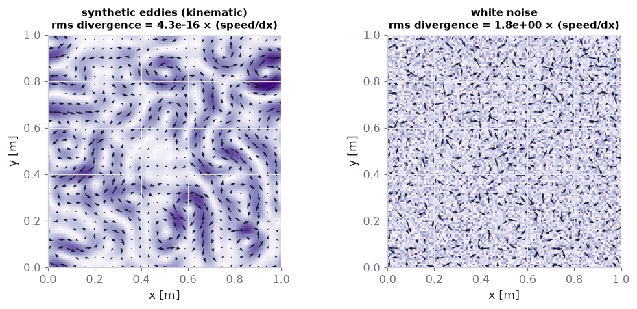

```python
nfield = 96 if FAST else 128                                   # grid points per side
E_raw = lambda K: K**4*np.exp(-(K/20.0)**2)                    # shape of the energy spectrum E(K) we prescribe (peak near K = 28 rad/m)
E_norm = quad(E_raw, 0, np.inf)[0]                             # its integral, used to normalise the shape
spec = lambda K: E_raw(K)/E_norm                               # now ∫E dK = 1 m²/s² = ½ mean(u² + v²): each component has variance ≈ 1
us, vs = TS.synthetic_solenoidal_field(nfield, 1.0, spectrum=spec, seed=1)   # divergence-free field in a 1 m box (kinematic)
uw, vw = TS.white_noise_field(nfield, seed=1)                  # white noise: every point independent
dxf = 1.0/nfield                                               # grid spacing [m]
div_s = ch12.divergence_rms(us, vs, dxf)/(np.sqrt(np.mean(us**2 + vs**2))/dxf)   # rms divergence in units of (speed / dx)
div_w = ch12.divergence_rms(uw, vw, dxf)/(np.sqrt(np.mean(uw**2 + vw**2))/dxf)   # the same for the noise
fig, (a1, a2) = plt.subplots(1, 2, figsize=(9, 4.0))   # a new figure and its panel(s); figsize in inches
xg = (np.arange(nfield) + 0.5)*dxf                             # cell positions [m]
sk = nfield//24                                                # draw every sk-th arrow
for ax, (uu_, vv_), name, dv in ((a1, (us, vs), "synthetic eddies (kinematic)", div_s), (a2, (uw, vw), "white noise", div_w)):
    ax.pcolormesh(xg, xg, np.hypot(uu_, vv_), cmap="Purples", shading="auto")       # colour = speed
    ax.quiver(xg[::sk], xg[::sk], uu_[::sk, ::sk], vv_[::sk, ::sk], color=COLORS["ink"], width=0.004)   # arrows = velocity
    ax.set(title=f"{name}\nrms divergence = {dv:.1e} × (speed/dx)", xlabel="x [m]", ylabel="y [m]", aspect="equal")   # axis labels (with units), title and fixed ranges of this panel
print(f"relative rms divergence: synthetic {div_s:.1e}, white noise {div_w:.2f}")
```

**What you see.** Left: swirls of several sizes, with arrows that follow each other round. Right: salt-and-pepper, neighbouring arrows unrelated. The titles give the rms divergence in units of (rms speed)/(grid spacing): round-off on the left, of order one on the right.

**How to read it.** Eddies are what mass conservation looks like in a random field: fluid that enters a region must leave it, so the velocity has to curl round. The left field is *kinematic* — it has a prescribed spectrum but no dynamics, no cascade.

**What would change if…** …we move the spectrum's peak to higher $K$ (replace 20 by 40 in `spec`): the eddies shrink, and the field is still divergence-free to round-off.

📝 **Note.** **N03 [C]** **The largest eddies are as big as the flow.** In a turbulent boundary layer the largest eddies have the size of the layer, $l\sim\delta$, and the edge between turbulent and irrotational fluid is ragged, not smooth. The outer scale $L$ returns in C07, entrainment across that ragged edge in C09, the thickness $\delta$ in C10.

📝 **Note.** **N04 [C]** **Scope.** Incompressible flow, no Coriolis force, three-dimensional fluctuations. Rotating stratified flows have nearly two-dimensional (geostrophic) turbulence, which sends energy to *larger* scales — the opposite of the cascade of C07 — and waits for Ch. 13.

## 12.2 Historical Notes

**What is this section about?** Who found what — read as a map of the chapter.

📝 **Note.** **N05 [C]** **A timeline, by block.**

| Years | Who | Idea | Block |
| --- | --- | --- | --- |
| 1883–1895 | Reynolds | the pipe experiment; averaging the equations | C04 |
| 1915–1921 | Taylor | eddy transport; dispersion by continuous movements | C16 |
| 1922–1926 | Richardson | the cascade ("big whirls have little whirls"); the four-thirds law | C07, C16 |
| 1925 | Prandtl | the mixing length | C12 |
| 1930 | von Kármán | the logarithmic velocity profile | C11 |
| 1935 | Taylor | isotropic turbulence, correlations and spectra | C05 |
| 1941 | Kolmogorov, Obukhov | universal small scales, the −5/3 spectrum | C07, C08 |
| 1954 | Monin, Obukhov | the stratified surface layer | C15 |

**N06** (Richardson's four-thirds law, an eddy diffusivity that grows with the size $l$ of the cloud, $K\sim\bar\varepsilon^{1/3}l^{4/3}$) is only named here; it is stated with a number at the end of C16, where both of its ingredients — the dissipation rate $\bar\varepsilon$ and the eddy diffusivity — exist.

## 12.3 Nomenclature and Statistics for Turbulent Flow

**What is this section about?** What "the mean" of a turbulent signal is, how to compute it from many runs or from one long record, which operations an average passes through — and the one it does not, which is where the rest of the chapter comes from.

### 🧩 Ensemble averages $\langle u^m\rangle=\lim_{N\to\infty}\frac1N\sum_{n=1}^N(u(\mathbf x,t{:}n))^m$ (12.1) and the rules of averaging `C01`

*The question:* What is 'the mean' of a signal that never repeats, and what may an average be moved through?

#### The problem in plain words

A wind gauge on a mast reads 4.1, 6.3, 3.8, 5.5 m/s within four seconds. What is "the wind"? A climate normal is a 30-year average for the same reason: the weather never repeats, so we describe it by its mean and by how it scatters about the mean. In a laboratory you can repeat an experiment a hundred times and average the hundred runs at the same instant; outdoors you have one run and can only average over time. When do the two agree?

#### The idea

```
realization 1:  ~~~/\~~\/~~~      average ACROSS runs at one time   → ensemble average (theory uses this)
realization 2:  ~\/~~~/\~~~~      average ALONG one run over Δt     → time average (measurements use this)
realization N:  ~~~\/~/\~~~~      they agree when: stationary, and Δt ≫ memory, Δt ≪ drift
an average is a SUM (÷N):  it passes through +, ×constant, ∂/∂t, ∂/∂x, ∫   — all linear
                           it does NOT pass through a product:  mean(ũṽ) = Ū V̄ + mean(uv)
```

Symbols: $u(\mathbf x,t{:}n)$ is the value at position $\mathbf x$ and time $t$ **in realization $n$** (read "$t{:}n$" as "time $t$ in run $n$"); $N$ is the number of runs; an over-bar is the average over the $N$ runs and $\langle\ \rangle$ its limit $N\to\infty$; $m$ is a power (1 for the mean, 2 for the mean square).

> 🔁 **Tools from earlier chapters used in this block** (one line each; the full primers are in the chapters named)
- **sinh** — $\sinh x=(e^x-e^{-x})/2\approx x+x^3/6$ for small $x$ — needed once in this block, in the window average of N23. *(Ch. 7, P168)*
- **seeded random generators (np.random.default_rng)** — a seeded generator makes "random" results reproducible; `normal`, `poisson`, `random`. *(Ch. 1, P10)*
- **Gaussian distribution** — the bell-shaped density $\propto e^{-x^2/2\sigma^2}$ with mean 0 and standard deviation $\sigma$; `rng.normal(0, sigma, n)` draws samples from it. *(Ch. 1, P11)*
- **log–log slopes and np.polyfit** — y = ax^k is a straight line of slope k on log–log axes; `np.polyfit` on the logs measures k. *(Ch. 1, P13)*
- **assert np.allclose** — stops with an error if two results differ beyond `rtol`; our proof that a from-scratch version matches the library. *(Ch. 1, P15)*
- **animate / show_animation, slider_figure, show_viz** — `update(i)` moves already-drawn artists per frame; `player="frames"` steps, `player="video"` plays smoothly. *(Ch. 1, P16)*
- **partial derivative ∂/∂t, ∂/∂x_j** — slope in one variable with the others held fixed; ∂²f/∂y² = curvature; ∇ points uphill, fluxes run "down the gradient". *(Ch. 1, P25)*
- **integral as a limit of sums; fundamental theorem of calculus** — an integral is the limit of (value × width) sums, so it is linear; and $\int_a^bf'(x)\,dx=f(b)-f(a)$. *(Ch. 2, P84)*
- **sympy (symbols, integrate, simplify)** — algebra with symbols: `sp.symbols`, `sp.diff`, `sp.integrate`, `sp.simplify`; an expression that simplifies to 0 is an identity. *(Ch. 1, P40)*

> 📎 **Primer — random variable, probability density and histogram.** `P280` · A *random variable* takes a different value in every realization. Its *probability density* says how often each value occurs (area under the density between two values = the fraction of runs that land there). A *histogram* (`np.histogram`, `ax.hist`) estimates the density by counting samples in bins. A Gaussian (bell-shaped) density has skewness 0 and normalised kurtosis 3 (both defined in N22 below).

```python
rng = np.random.default_rng(0)                    # seeded generator (Ch. 1, P10)
x = rng.normal(0.0, 1.0, 10_000)                  # 10 000 samples of a Gaussian random variable, mean 0, std 1
print(round(float(x.mean()), 3), round(float(x.std()), 3))   # sample mean ≈ 0 and standard deviation ≈ 1
print(np.histogram(x, bins=5, range=(-2.5, 2.5))[0])         # counts in 5 bins: most samples near the middle
```

```
0.006 0.998
[ 565 2442 3747 2506  609]
```

> 📎 **Primer — Ornstein–Uhlenbeck signal (a Langevin equation).** `P283` · Our test signal throughout the chapter: a random signal with a chosen standard deviation $\sigma$ and a chosen *memory time* $\tau_c$. Each step keeps a fraction $e^{-\Delta t/\tau_c}$ of the old value and adds fresh Gaussian noise $\xi_n$: $u_{n+1}=u_ne^{-\Delta t/\tau_c}+\sigma\sqrt{1-e^{-2\Delta t/\tau_c}}\,\xi_n$. The square root is chosen so that the variance stays $\sigma^2$; the update is exact for any step $\Delta t$. (It is the discrete form of a *Langevin equation*, a relaxation toward zero driven by random kicks.) `TS.make_ensemble` builds many such runs around a mean of your choice.

```python
rng = np.random.default_rng(1)                    # seeded generator
sig, tau_c, dt_ = 1.0, 0.5, 0.05                  # standard deviation [m/s], memory time [s], time step [s]
keep = np.exp(-dt_/tau_c)                         # the fraction of the old value kept in one step
u_ou = np.empty(20_000); u_ou[0] = sig*rng.normal()          # start from a random value with the right variance
for n in range(u_ou.size - 1):                    # march in time
    u_ou[n + 1] = u_ou[n]*keep + sig*np.sqrt(1 - keep**2)*rng.normal()   # keep part of the past, add fresh noise
print(round(float(u_ou.std()), 2))                # ≈ 1: the variance is preserved
```

```
0.98
```

> 📎 **Primer — standard error of a mean.** `P281` · The mean of $N$ **independent** samples scatters about the true mean with standard deviation $\sigma/\sqrt N$ — the *standard error*. "Within 5 standard errors" is our test for every sampled number in this chapter (a correct code fails it about once in two million tries). Samples taken close together in time are **not** independent. For a record of length $T$ whose memory time is $\Lambda_t$ (the area under its autocorrelation, defined in C02) the variance of the time mean is $2\sigma^2\Lambda_t/T$ when $T\gg\Lambda_t$ — the same triangle-weighted integral that C16 derives for dispersion — so the record is worth $N=T/(2\Lambda_t)$ independent samples: one for every two memory times.

```python
rng = np.random.default_rng(2)                    # seeded generator
batch_means = rng.normal(0.0, 1.0, (2000, 64)).mean(axis=1)   # the means of 2000 batches of 64 Gaussian samples
print(round(float(batch_means.std()), 3), 1/np.sqrt(64))      # their scatter ≈ 0.125 = 1/sqrt(64)
```

```
0.126 0.125
```

📝 **Note.** **N07 [B]** **Realization, ensemble, ensemble average.** One run of an experiment is a *realization*; the set of all runs under the same conditions is the *ensemble*; the over-bar is the average over $N$ of them, and $\langle\ \rangle$ its limit $N\to\infty$ (the *expected value*). Chapter 11's Lorenz system showed why we must think this way: two runs that start $10^{-8}$ apart end up completely different, so only statistics are reproducible.

$$ \langle u^m(\mathbf x,t)\rangle=\lim_{N\to\infty}\frac1N\sum_{n=1}^N\big(u(\mathbf x,t{:}n)\big)^m \qquad \text{(12.1)} $$

📝 **Note.** **N19 [B]** **The mean** is the $m=1$ case with a finite number of runs — what the over-bar means from here on.

$$ \overline{u(\mathbf x,t)}\equiv\frac1N\sum_{n=1}^Nu(\mathbf x,t{:}n) \qquad \text{(12.10)} $$

```python
t = np.arange(0.0, 20.0, 0.01)                    # time axis [s]: 2000 samples, 0.01 s apart
mean_fn = lambda t: np.exp(-t/10.0)               # the true (decaying) mean we hide inside the noise [m/s]
ens_u = TS.make_ensemble(64, t, mean_fn, sigma=0.3, tau_c=0.5, seed=0)   # 64 runs: mean + OU noise (std 0.3 m/s, memory 0.5 s)
ens_v = TS.make_ensemble(64, t, mean_fn, sigma=0.3, tau_c=0.5, seed=1) + 0.5*(ens_u - mean_fn(t))   # a second variable, partly correlated with the first
ubar = TS.ensemble_average(ens_u)                 # Eq. (12.10): average over the member axis (axis 0), one value per time
print(ens_u.shape, ubar.shape)                    # (64 members, 2000 times) -> (2000 times,)
print(f"rms error of the 64-member mean: {np.sqrt(np.mean((ubar - mean_fn(t))**2)):.4f} m/s  (sigma/sqrt(64) = {0.3/8:.4f})")
```

```
(64, 2000) (2000,)
rms error of the 64-member mean: 0.0416 m/s  (sigma/sqrt(64) = 0.0375)
```

**What does the code above do?**

1. `TS.make_ensemble(n_members, t, mean_fn, sigma, tau_c, seed)` returns an array with **the member index on axis 0**: row $n$ is realization $n$.
2. `ens_v` is a second signal that shares half of `ens_u`'s fluctuation, so the two are correlated (we need that for the product rule below).
3. `TS.ensemble_average` is the mean over axis 0, $\overline{u(\mathbf x,t)}\equiv\frac1N\sum_{n=1}^Nu(\mathbf x,t{:}n)$ (12.10). With 64 members its rms distance from the true mean is close to $\sigma/\sqrt{64}=0.0375$ m/s.

📝 **Note.** **N08 [B]** **Stationary** means the statistics do not depend on the time origin. Then a *time* average over a window $\Delta t$ can replace the ensemble average.

$$ \overline{u^m(\mathbf x)}=\frac1{\Delta t}\int_{t-\Delta t/2}^{t+\Delta t/2}u^m(\mathbf x,t)\,dt \qquad \text{(12.2)} $$

> 📎 **Primer — sliding-window average with np.cumsum.** `P284` · The sum over a window equals the difference of two cumulative sums, so a sliding average costs one pass over the data. `np.cumsum(x)` returns the running sum $x_0,\ x_0+x_1,\ \dots$. Within half a window of each end there is no full window: `TS.time_average` returns NaN there ("not a number", a marker for "no value").

```python
x = np.arange(10.0)                               # 0, 1, ..., 9
c = np.concatenate([[0.0], np.cumsum(x)])         # running sum with a leading zero: c[k] = x[0] + ... + x[k-1]
print((c[3:] - c[:-3])/3)                         # mean of every 3 consecutive values: 1, 2, ..., 8
```

```
[1. 2. 3. 4. 5. 6. 7. 8.]
```

📝 **Note.** **N09 [B]** **Homogeneous** is "stationary in space": the statistics do not depend on where you are. Then a *volume* average replaces the ensemble average. One number: the mean square speed of the synthetic field of §12.1.

$$ \overline{u^m(t)}=\frac1V\int_Vu^m(\mathbf x,t)\,dV \qquad \text{(12.3)} $$

```python
print(f"volume average of u^2 over the box: {TS.volume_average(us, m=2):.4g} (m/s)^2")   # Eq. (12.3) with m = 2 on the N02 field
print(f"the same with np.mean:              {np.mean(us**2):.4g} (m/s)^2")               # on a uniform grid it is the plain mean
```

```
volume average of u^2 over the box: 0.8857 (m/s)^2
the same with np.mean:              0.8857 (m/s)^2
```

📝 **Note.** **N10 [B]** **Stationary and non-stationary records side by side.** The figure shows two members of an ensemble with a constant mean and two members of our decaying ensemble; the ensemble mean is dashed purple, the members teal.

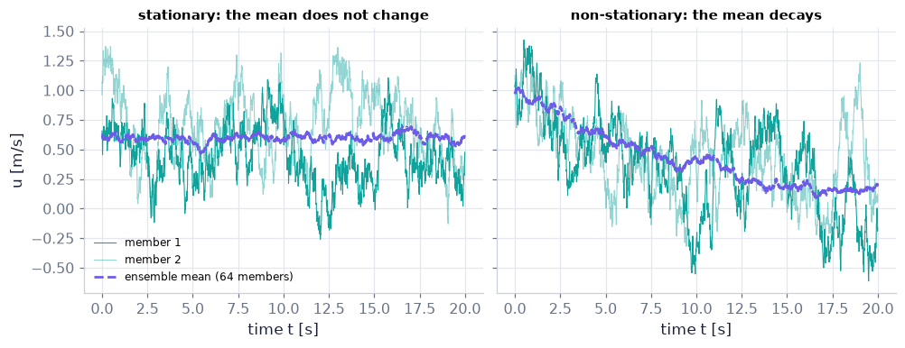

```python
ens_c = TS.make_ensemble(64, t, lambda t: 0.6 + 0*t, sigma=0.3, tau_c=0.5, seed=2)   # a stationary ensemble: constant mean 0.6 m/s
fig, (a1, a2) = plt.subplots(1, 2, figsize=(9, 3.4), sharey=True)   # a new figure and its panel(s); figsize in inches
for ax, ens, name in ((a1, ens_c, "stationary: the mean does not change"), (a2, ens_u, "non-stationary: the mean decays")):
    ax.plot(t, ens[0], color=C_FLUC, lw=0.7, label="member 1")                 # one realization
    ax.plot(t, ens[1], color=C_FLUC, lw=0.7, alpha=0.45, label="member 2")     # another one: different in detail
    ax.plot(t, TS.ensemble_average(ens), "--", color=C_MEAN, lw=1.8, label="ensemble mean (64 members)")   # Eq. (12.10)
    ax.set(title=name, xlabel="time t [s]")   # axis labels (with units), title and fixed ranges of this panel
a1.set_ylabel("u [m/s]")   # label / range / scale of this axis
a1.legend(fontsize=8)   # the legend names every curve
plt.show()   # display the figure
```

**What you see.** Left: two wiggly records around a level dashed line. Right: two records around a dashed line that decays from 1 to about 0.14 m/s. In both panels the two members differ in every detail but share the dashed mean.

**How to read it.** The ensemble mean is defined at every instant, whether or not the flow is stationary. A time average only makes sense on the left — or on the right if the window is short against the 10 s decay and long against the 0.5 s memory.

**What would change if…** …the decay time were shorter than the memory time: no window could separate the mean from the fluctuation, and only an ensemble of repeated runs would do.

> 📎 **Primer — ergodicity.** `P282` · For a stationary signal, a long time average of **one** run equals the ensemble average over **many** runs. This is called *ergodicity*. The book assumes it silently every time a measurement (a time average) is compared with theory (ensemble averages).

```python
t_long = np.arange(0.0, 2000.0, 0.05)                                 # one long record: 2000 s
one_run = TS.make_ensemble(1, t_long, lambda t: 0*t, 1.0, 0.5, seed=5)[0]   # a single OU run, true mean 0, std 1, memory 0.5 s
many = TS.make_ensemble(2000, np.arange(0.0, 5.0, 0.05), lambda t: 0*t, 1.0, 0.5, seed=6)   # 2000 short runs
print(f"time mean of one long run:        {one_run.mean():+.3f}  (standard error ≈ sqrt(2 × 0.5/2000) = 0.022)")   # ≈ 0 within a few standard errors
print(f"ensemble mean of 2000 runs at t = 2.5 s: {many[:, 50].mean():+.3f}  (standard error 1/sqrt(2000) = 0.022)")   # ≈ 0 as well
```

```
time mean of one long run:        +0.037  (standard error ≈ sqrt(2 × 0.5/2000) = 0.022)
ensemble mean of 2000 runs at t = 2.5 s: -0.032  (standard error 1/sqrt(2000) = 0.022)
```

📝 **Note.** **N11 [B]** **Choosing a window.** Outdoors we average over time (or space): the window must be long against the memory of the signal and short against the drift of its mean, $t_c\ll\Delta t\ll$ drift time. **Climate hook:** a 30-year normal is such a window; an "eddy flux" $\overline{v'T'}$ in the general circulation is a covariance of deviations from a time or zonal mean (Ch. 13).

#### 🧮 Derivation — The rules of averaging, $\overline{\bar u}=\bar u$, and $\overline{\tilde u\tilde v}=\bar u\bar v+\overline{uv}$ `D01` ★ (Eq. 12.4: $\overline{u^m+v^m}=\overline{u^m}+\overline{v^m}$)

**What we want to show.** Find out which operations may be swapped with an average — and the one that may not. Every later derivation of the chapter uses only these rules.

**Assumptions.** Ensemble average; the same N realizations for every variable; the fields are differentiable.

**The plan.**

1. Write the average as a plain finite sum.
2. Pass each linear operation through the sum.
3. Try a product and see what is left.
4. Take N → ∞ last.

**Tools we use** (each explained before this point): finite sums (school algebra) · partial derivative (P25, reminder) · integral as a limit of sums (P84, reminder) · expanding a product

**We start from**

$$ \begin{array}{l}\overline{u^m(\mathbf x,t)}\equiv\frac1N\sum_{n=1}^N\big(u(\mathbf x,t{:}n)\big)^m\ \text{, the finite-N form of} \\ \langle u^m(\mathbf x,t)\rangle=\lim_{N\to\infty}\frac1N\sum_{n=1}^N\big(u(\mathbf x,t{:}n)\big)^m\ \text{(12.1)}\end{array} $$

*In words:* Add the N realizations and divide by N

**Step 1 of 8 — Write the average as a sum.**

$$ \overline{u}=\dfrac1N\big(u_1+u_2+\dots+u_N\big)\ \text{,}\ u_n\equiv u(\mathbf x,t{:}n) $$

- *Why we can do this:* This is the definition with m = 1; writing it out shows an average is nothing more than adding and dividing by a fixed number.
- *In words:* The mean is the sum of the runs divided by how many there are.

**Step 2 of 8 — Average a sum of two variables.**

$$ \overline{u+v}=\dfrac1N\sum_n(u_n+v_n)=\dfrac1N\sum_nu_n+\dfrac1N\sum_nv_n=\overline u+\overline v $$

- *Why we can do this:* A finite sum can be added in any order (commutative, associative). This is (12.4), $\overline{u^m+v^m}=\overline{u^m}+\overline{v^m}$, for m = 1; any m works the same way.
- *In words:* The mean of a sum is the sum of the means.

**Step 3 of 8 — Average a constant times a variable.**

$$ \overline{Au}=\dfrac1N\sum_nAu_n=A\,\dfrac1N\sum_nu_n=A\,\overline u $$

- *Why we can do this:* A is the same in every realization, so it factors out of the sum (distributive law). This is (12.5), $\overline{Au^m}=A\overline{u^m}$; with u = 1 it gives $\overline A=A$.
- *In words:* A fixed number passes straight through an average.

**Step 4 of 8 — Average a derivative.**

$$ \overline{\dfrac{\partial u}{\partial t}}=\dfrac1N\sum_n\dfrac{\partial u_n}{\partial t}=\dfrac{\partial}{\partial t}\Big(\dfrac1N\sum_nu_n\Big)=\dfrac{\partial\overline u}{\partial t} $$

- *Why we can do this:* The derivative of a finite sum is the sum of the derivatives (linearity of ∂), and 1/N is a constant. This is (12.6), $\overline{\partial u^m/\partial t}=\partial\overline{u^m}/\partial t$; with $x_j$ for t it is (12.8), $\overline{\partial u^m/\partial x_j}=\partial\overline{u^m}/\partial x_j$.
- *In words:* Averaging and differentiating can be done in either order.

**Step 5 of 8 — Average an integral.**

$$ \overline{\displaystyle\int_a^bu\,dt}=\dfrac1N\sum_n\int_a^bu_n\,dt=\int_a^b\Big(\dfrac1N\sum_nu_n\Big)dt=\int_a^b\overline u\,dt $$

- *Why we can do this:* An integral is a limit of sums, so it is linear too and swaps with the finite sum over n. This is (12.7), $\overline{\int_a^bu^m\,dt}=\int_a^b\overline{u^m}\,dt$; the spatial version is (12.9), $\overline{\int u^m\,d\mathbf x}=\int\overline{u^m}\,d\mathbf x$.
- *In words:* Averaging and integrating can be done in either order.

**Step 6 of 8 — Average something already averaged.**

$$ \overline{\bar u}=\bar u,\qquad\overline{\bar u\,v}=\bar u\,\overline v $$

- *Why we can do this:* $\bar u$ is one number at each (x, t), the same in every realization — a "constant" in the sense of step 3. We need this to handle products next.
- *In words:* A mean is not random any more, so averaging it again changes nothing.

**Step 7 of 8 — Average a product of two total fields.**

$$ \overline{\tilde u\tilde v}=\overline{(\bar u+u)(\bar v+v)}=\bar u\bar v+\bar u\,\overline v+\overline u\,\bar v+\overline{uv}=\bar u\bar v+\overline{uv} $$

- *Why we can do this:* Expand the product, then use steps 2, 3 and 6; the two middle terms vanish because a fluctuation has zero mean, $\overline u=\overline v=0$ (C04's $\overline{u_i}=0$ (12.26)). A product is **not** linear, so nothing lets us split $\overline{uv}$.
- *In words:* The mean of a product is the product of the means plus the covariance of the fluctuations.

**Step 8 of 8 — Let the number of realizations grow.**

$$ \langle\tilde u\tilde v\rangle=\lim_{N\to\infty}\overline{\tilde u\tilde v}=\langle\tilde u\rangle\langle\tilde v\rangle+\langle uv\rangle,\qquad\langle uv\rangle\neq0\ \text{in general} $$

- *Why we can do this:* Every line above holds for each finite N, so it holds in the limit; taking the limit last avoids swapping a limit with a derivative.
- *In words:* However many runs we average, the leftover covariance stays.

**Result**

$$ \begin{array}{l}\overline{u+v}=\bar u+\bar v\ \text{,}\ \overline{Au}=A\bar u\ \text{,}\ \overline{\partial u/\partial t}=\partial\bar u/\partial t\ \text{,}\ \overline{\partial u/\partial x_j}=\partial\bar u/\partial x_j\ \text{,}\ \overline{\int u}=\int\bar u\ \text{,} \\ \text{but}\ \overline{\tilde u\tilde v}=\bar u\bar v+\overline{uv}\end{array} $$

*In words:* An average commutes with everything linear and with nothing else

**What it means.** When we average the equations of motion every linear term keeps its form; the nonlinear term $\tilde u_j\tilde u_i$ leaves $\overline{u_iu_j}$ behind — the Reynolds stress. **Fails when:** the "average" is a finite time window: then $\overline{\partial u^m/\partial t}=\partial\overline{u^m}/\partial t$ (12.6) holds only if the window is short against the drift of the mean (C01, N14).

**Check it.** Units — both sides of every rule carry the units of u (or u/t, u·t, uv). Number: two runs ũ = (1, 3), ṽ = (2, 6): $\bar u\bar v$ = 8, $\overline{uv}$ = 2, $\overline{\tilde u\tilde v}$ = 10 ✓. Code: `TS.check_averaging_rules` returns round-off for every entry except "product". Special case: if u and v are uncorrelated, $\overline{uv}=0$ and the product rule "works".

📝 **Notes taught inside `D01`:** **N12 [B]** the mean of a sum, $\overline{u^m+v^m}=\overline{u^m}+\overline{v^m}$ (12.4) (step 2) · **N13 [B]** a constant factors out, $\overline{Au^m}=A\overline{u^m}$ (12.5) (step 3) · **N14 [B]** averaging and $\partial/\partial t$ swap, $\overline{\partial u^m/\partial t}=\partial\overline{u^m}/\partial t$ (12.6) — ⚠️ exact for ensemble averages; for a finite time window only when the window is short against the drift; used again in C16 (step 4) · **N15 [B]** $\overline{\int_a^bu^m\,dt}=\int_a^b\overline{u^m}\,dt$ (12.7) (step 5) · **N16 [B]** $\overline{\partial u^m/\partial x_j}=\partial\overline{u^m}/\partial x_j$ (12.8) (step 4) · **N17 [B]** $\overline{\int u^m\,d\mathbf x}=\int\overline{u^m}\,d\mathbf x$ (12.9) (step 5) · **N18 [B]** the product does not commute: $\overline{u^m}\neq\bar u^m$ and $\overline{uv}\neq\bar u\,\bar v$ in general (step 7).

> ⚠️ **Common confusion (traps in `D01`):** Thinking the rules are special to turbulence (they are linearity); forgetting that $\overline{u^2}\neq\bar u^2$ is the same failure; using different sets of runs for u and v; commuting a *time* average with ∂/∂t exactly.

```python
res = TS.check_averaging_rules(ens_u, ens_v, t, A=2.0)        # apply each operation before and after averaging; return the largest difference
for name, err in res.items():                                 # one line per rule
    print(f"{name:20s} largest |average(op u) - op(average u)| = {err:.1e}")
mean_prod, prod_means, cov = TS.product_average_split(ens_u, ens_v)   # mean(u v), mean(u) mean(v), mean(u' v') at every time
print("mean of product = product of means + covariance:", np.allclose(mean_prod, prod_means + cov))
print(f"time-mean covariance of the fluctuations: {cov.mean():.4f} (m/s)^2  (built in: 0.5 x 0.3^2 = {0.5*0.3**2:.4f})")
```

```
sum                  largest |average(op u) - op(average u)| = 1.3e-15
constant             largest |average(op u) - op(average u)| = 0.0e+00
d/dt                 largest |average(op u) - op(average u)| = 4.0e-14
integral dt          largest |average(op u) - op(average u)| = 0.0e+00
d/dx                 largest |average(op u) - op(average u)| = 4.0e-14
integral dx          largest |average(op u) - op(average u)| = 0.0e+00
average of average   largest |average(op u) - op(average u)| = 1.7e-15
product              largest |average(op u) - op(average u)| = 8.7e-02
mean of product = product of means + covariance: True
time-mean covariance of the fluctuations: 0.0442 (m/s)^2  (built in: 0.5 x 0.3^2 = 0.0450)
```

**What does the code above do?**

1. `TS.check_averaging_rules` applies the **same discrete operator** (a sum, a factor 2, a finite-difference derivative, a trapezoid integral) to each member and then averages, and to the average directly; it returns the largest difference for each rule. Every entry is at round-off ($10^{-13}$ or smaller) — except `product`.
2. `TS.product_average_split` returns the three pieces of step 7 of the derivation. The leftover covariance is not noise: we built `ens_v` to share half of `ens_u`'s fluctuation, so it should be $0.5\times0.3^2=0.045$, and it is.

#### ✏️ Tiny example: two realizations are enough to break the product rule

Run 1: $\tilde u=1$, $\tilde v=2$. Run 2: $\tilde u=3$, $\tilde v=6$.

1. Means: $\bar u=2$, $\bar v=4$, so $\bar u\,\bar v=8$.
2. Mean of the product: $(1\cdot2+3\cdot6)/2=10$.
3. Fluctuations: $u=-1,+1$; $v=-2,+2$; mean of $uv$ = $(2+2)/2=2$.
4. Check $\overline{\tilde u\tilde v}=\bar u\bar v+\overline{uv}$: $10=8+2$ ✓.

The 2 that is left over is the kind of term the Reynolds stress is made of.

```python
# From scratch: mean and variance by an explicit loop over members, and the product split by hand
sum_u = np.zeros(t.size); sum_u2 = np.zeros(t.size)           # running sums of u and u^2 at every time
for member in ens_u:                                          # one realization at a time
    sum_u += member                                           # add this run's value
    sum_u2 += member**2                                       # add this run's square
mean_mine = sum_u/len(ens_u)                                  # Eq. (12.10): divide the sum by N
var_mine = sum_u2/len(ens_u) - mean_mine**2                   # variance = mean of the square minus square of the mean
up, vp = ens_u - ens_u.mean(axis=0), ens_v - ens_v.mean(axis=0)   # fluctuations: subtract the ensemble mean at each time
cov_mine = (up*vp).mean(axis=0)                               # covariance of the fluctuations
assert np.allclose(mean_mine, TS.ensemble_average(ens_u))     # same numbers -> the library does exactly this
assert np.allclose(var_mine, TS.central_moment(ens_u, 2))     # second central moment = variance
assert np.allclose(cov_mine, TS.product_average_split(ens_u, ens_v)[2])   # the leftover of the product rule
tiny_u, tiny_v = np.array([[1.0], [3.0]]), np.array([[2.0], [6.0]])       # the two runs of the tiny example
print([float(a[0]) for a in TS.product_average_split(tiny_u, tiny_v)])    # [10.0, 8.0, 2.0]
```

```
[10.0, 8.0, 2.0]
```

**What does the code above do?**

1. The loop adds each run's value and square; dividing by the number of runs gives the mean and the mean square.
2. The three `assert` lines stop with an error if the hand-made numbers differ from `TS.ensemble_average`, `TS.central_moment` and `TS.product_average_split` — they do not.
3. The last line runs the tiny example through the library: 10, 8, 2.

📝 **Note.** **N20 [B]** **How fast does an average converge?** The scatter of an $N$-member mean falls like $N^{-1/2}$: four times the runs for half the error. Animation A1 adds members one at a time; the figure after it measures the slope.

```python
ens_big = TS.make_ensemble(64, t, mean_fn, sigma=0.3, tau_c=0.5, seed=7)   # the decaying ensemble again, 64 members
stops = [1, 2, 4, 8, 16, 24, 32, 48, 64]                      # members shown per frame (9 frames)
tavg = TS.time_average(t, ens_big[0], window=2.0)             # a 2 s sliding time average of member 1 alone, Eq. (12.2)
sk4 = slice(None, None, 8)                                    # draw every 8th sample (0.08 s apart): the same picture in a much lighter image
fig, ax = plt.subplots(figsize=(6.4, 3.4))   # a new figure and its panel(s); figsize in inches
ax.plot(t, mean_fn(t), color=C_REF, lw=3, alpha=0.5, label="true mean $e^{-t/10}$")   # the ghost we are trying to recover
(ln_new,) = ax.plot(t[sk4], ens_big[0][sk4], color="0.75", lw=0.5, label="newest member")      # the member just added (grey)
(ln_mean,) = ax.plot(t[sk4], ens_big[0][sk4], color=C_MEAN, lw=1.4, label="ensemble mean of N members")   # the running ensemble mean
ax.plot(t, tavg, color=C_FLUC, lw=1.4, label="2 s time average of member 1")          # what one run alone can give
ax.set(xlabel="time t [s]", ylabel="u [m/s]", xlim=(0, 20), ylim=(-0.6, 1.7))   # axis labels (with units), title and fixed ranges of this panel
ax.legend(fontsize=7, loc="upper right")   # the legend names every curve
ttl = ax.set_title("")   # label / range / scale of this axis

def update(i):                                                # frame i: show the mean of the first N = stops[i] members
    N = stops[i]                                              # number of members in the average
    ln_new.set_ydata(ens_big[N - 1][sk4])                     # the newest member
    ln_mean.set_ydata(ens_big[:N].mean(axis=0)[sk4])          # Eq. (12.10) with N members
    ttl.set_text(f"N = {N}: scatter of the mean ≈ σ/√N = {0.3/np.sqrt(N):.3f} m/s")   # move the drawn objects to this frame's values
    return ln_new, ln_mean, ttl   # hand the result back to the caller

show_animation(animate(update, frames=len(stops), fig=fig, interval=400), player="frames", dpi=45)   # step with the buttons
```

[figure not shown]

**What does the code above do?**

1. `stops` lists how many members are in the average at each frame; `update(i)` redraws the newest member (grey) and the mean of the first $N$ (purple).
2. The teal curve never changes: it is a 2-second sliding average of member 1 only — the best a single record can do.
3. `player="frames"` gives ◀ ▶ buttons: stop at $N=2,4,8,64$ and compare the purple wiggle with $\sigma/\sqrt N$ in the title.

**What you see.** A thick grey ghost (the true decaying mean), a thin grey member, a purple curve that starts as wiggly as one member and calms down as $N$ grows, and a teal curve (time average of one member) that is smooth but wanders about the ghost.

**How to read it.** The purple curve's scatter is $\sigma/\sqrt N$: 0.21 m/s at $N=2$, 0.0375 m/s at $N=64$. The teal curve averages about $2\text{ s}/(2\times0.5\text{ s})=2$ independent samples, so it is no better than $N=2$ — a single record needs a long window, and a long window blurs a changing mean.

**What would change if…** …the members were correlated with each other (say, all started from the same gust): the scatter would fall more slowly than $N^{-1/2}$, because the runs would not be independent samples.

```
fitted slope -0.497 (expect -0.50 ± 0.05); sigma/sqrt(64) = 0.0375 m/s
```

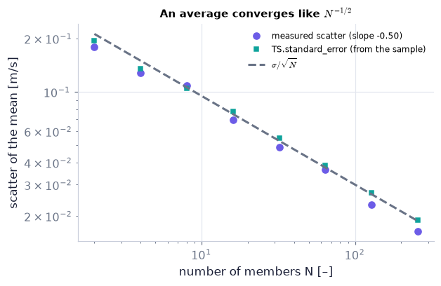

```python
ens_256 = TS.make_ensemble(256, t, lambda t: 0*t, sigma=0.3, tau_c=0.5, seed=8)   # 256 members around a zero mean
Ns = np.array([2, 4, 8, 16, 32, 64, 128, 256])                # ensemble sizes to test
scatter = np.array([np.sqrt(np.mean(ens_256[:N].mean(axis=0)**2)) for N in Ns])   # measured rms error of the N-member mean
est = np.array([np.mean(TS.standard_error(ens_256[:N])) for N in Ns])             # TS.standard_error: sample std / sqrt(N)
slope = np.polyfit(np.log(Ns), np.log(scatter), 1)[0]         # slope of the log-log line (P13)
fig, ax = plt.subplots(figsize=(5.6, 3.6))   # a new figure and its panel(s); figsize in inches
ax.loglog(Ns, scatter, "o", color=C_MEAN, label=f"measured scatter (slope {slope:.2f})")   # what the ensemble does
ax.loglog(Ns, est, "s", color=C_FLUC, ms=4, label="TS.standard_error (from the sample)")     # what one can estimate from the data
ax.loglog(Ns, TS.standard_error_of_mean(0.3, Ns), "--", color=C_REF, label=r"$\sigma/\sqrt{N}$")   # the −1/2 law
ax.set(xlabel="number of members N [–]", ylabel="scatter of the mean [m/s]", title="An average converges like $N^{-1/2}$")   # axis labels (with units), title and fixed ranges of this panel
ax.legend(fontsize=8)   # the legend names every curve
print(f"fitted slope {slope:.3f} (expect -0.50 ± 0.05); sigma/sqrt(64) = {TS.standard_error_of_mean(0.3, 64):.4f} m/s")
assert abs(slope + 0.5) < 0.05                                # the −1/2 law holds for our seeded ensemble
```

**What you see.** Three sets of points falling along one straight line on logarithmic axes: the measured scatter of the $N$-member mean (purple), the estimate `TS.standard_error` computes from the sample itself (teal), and $\sigma/\sqrt N$ (dashed).

**How to read it.** A slope of −½ on log–log axes is the $N^{-1/2}$ law. To gain one decimal digit in a mean you need 100 times the data — the reason turbulence statistics are expensive.

**What would change if…** …we averaged over time instead: $N$ becomes the number of *independent* samples in the record, about $\Delta t/(2\Lambda_t)$, where $\Lambda_t$ is the memory time defined in C02.

📝 **Note.** **N21 [B]** **Central moments** measure the scatter about the mean.

$$ \overline{(u-\langle u\rangle)^m}\equiv\frac1N\sum_n\big(u(\mathbf x,t{:}n)-\langle u(\mathbf x,t)\rangle\big)^m \qquad \text{(12.11)} $$

📝 **Note.** **N22 [B]** **Variance, standard deviation, rms, skewness, kurtosis.** The second central moment is the *variance* $\overline{(u-\bar u)^2}=\overline{u^2}-\bar u^2$; its square root is the *standard deviation* $\sigma$ (equal to the root-mean-square, *rms*, when the mean is zero). The third and fourth moments measure lopsidedness and the weight of the tails.

|  | third moment | fourth moment | Gaussian |
| --- | --- | --- | --- |
| the book (raw central moments) | *skewness* $\overline{(u-\bar u)^3}$, units $u^3$ | *kurtosis* $\overline{(u-\bar u)^4}$, units $u^4$ | $0$ and $3\sigma^4$ |
| the usual, `normalized=True` | divided by $\sigma^3$, a pure number | divided by $\sigma^4$, a pure number | $0$ and $3$ |

```python
xg_ = np.random.default_rng(3).normal(0.0, 2.0, 100_000)      # 100 000 Gaussian samples with standard deviation 2
raw = TS.statistics(xg_, normalized=False)                    # the book's convention: raw central moments
nrm = TS.statistics(xg_, normalized=True)                     # the usual convention: divided by sigma^3 and sigma^4
print({k: round(float(v), 3) for k, v in raw.items()})        # kurtosis ≈ 3 sigma^4 = 48
print({k: round(float(v), 3) for k, v in nrm.items()})        # skewness ≈ 0, kurtosis ≈ 3
assert abs(nrm["skewness"]) < 0.04 and abs(nrm["kurtosis"] - 3) < 0.08    # Gaussian values within sampling error
assert np.isclose(raw["variance"], np.mean(xg_**2) - np.mean(xg_)**2)    # variance = mean square − squared mean
```

```
{'mean': 0.001, 'variance': 3.992, 'skewness': 0.008, 'kurtosis': 47.672, 'std': 1.998, 'rms': 1.998}
{'mean': 0.001, 'variance': 3.992, 'skewness': 0.001, 'kurtosis': 2.991, 'std': 1.998, 'rms': 1.998}
```

**What does the code above do?**

1. `TS.statistics` returns a dictionary: mean, variance, skewness, kurtosis, std, rms.
2. With `normalized=False` the kurtosis is $3\sigma^4=3\times16=48$; with `normalized=True` it is 3. Same data, two conventions — always say which.

> 📎 **Primer — the sinc function and np.sinc.** `P285` · $\sin(x)/x$ equals 1 at $x=0$ and is zero at $x=\pi,2\pi,\dots$. numpy's `np.sinc(x)` is $\sin(\pi x)/(\pi x)$, so $\sin(a)/a$ = `np.sinc(a/np.pi)`. It appears whenever a wave is averaged over a window.

```python
a = np.array([0.0, 0.4*np.pi, np.pi])             # three arguments: 0, 0.4 pi, pi
print(np.round(np.sinc(a/np.pi), 4))              # sin(a)/a = 1, 0.7568, 0
```

```
[1.     0.7568 0.    ]
```

📝 **Note.** **N23 [B]** **What a time window does to a decaying mean plus a wave** (our numbers). For the signal $u=Ae^{-t/\tau_d}+B\cos\omega t$ ($\tau_d$ a decay time [s], $\omega$ an angular frequency [rad/s]) the window average is

$$\overline{u(t)}=\Big[\frac{\sinh(\Delta t/2\tau_d)}{\Delta t/2\tau_d}\Big]Ae^{-t/\tau_d}+\Big[\frac{\sin(\omega\Delta t/2)}{\omega\Delta t/2}\Big]B\cos\omega t .$$

Each part keeps its form and is multiplied by a factor: $\sinh(x)/x$ (always $\ge1$; $\sinh x=(e^x-e^{-x})/2$, Ch. 7 P168) for the mean, the sinc function for the wave. A good window makes the first factor ≈ 1 and the second ≈ 0: $1\ll\omega\Delta t\ll\omega\tau_d$.

```python
ts, Dt, A_, B_, td, w_ = sp.symbols("t Delta_t A B tau_d omega", positive=True)   # symbols: time, window, amplitudes, decay time, frequency
s_ = sp.symbols("s")                                          # the integration variable (time inside the window)
u_sym = A_*sp.exp(-s_/td) + B_*sp.cos(w_*s_)                  # the signal: decaying mean + wave
avg = sp.integrate(u_sym, (s_, ts - Dt/2, ts + Dt/2))/Dt      # Eq. (12.2): the window average, done symbolically
target = sp.sinh(Dt/(2*td))/(Dt/(2*td))*A_*sp.exp(-ts/td) + sp.sin(w_*Dt/2)/(w_*Dt/2)*B_*sp.cos(w_*ts)   # the claimed result
print("sympy window integral − formula =", sp.simplify((avg - target).rewrite(sp.exp)))   # 0: the formula is right
val, f_mean, f_wave = ch12.time_average_exp_cos(5.0, 1.0, 0.5, 10.0, 2*np.pi, 0.4)   # t = 5 s, A = 1, B = 0.5, tau_d = 10 s, 1 s period, window 0.4 s
print(f"mean factor {f_mean:.7f}, wave factor {f_wave:.4f}, window average at t = 5 s: {val:.5f} m/s")
```

```
sympy window integral − formula = 0
mean factor 1.0000667, wave factor 0.7568, window average at t = 5 s: 0.98498 m/s
```

**What does the code above do?**

1. sympy integrates the signal over the window and subtracts the formula: the difference simplifies to 0.
2. `ch12.time_average_exp_cos(t, A, B, tau, omega, window)` returns the average and the two factors: 1.0000667 (the mean is untouched), 0.7568 (three quarters of the wave leaks through a 0.4-period window), average 0.98498 m/s.

#### ✏️ Tiny example: a window of 0.4 periods

$A=1$, $B=0.5$ m/s, $\tau_d=10$ s, period 1 s ($\omega=2\pi$ rad/s), $\Delta t=0.4$ s.

1. Mean factor: $x=\Delta t/2\tau_d=0.02$, $\sinh(x)/x\approx1+x^2/6=1.00007$ — the mean passes untouched.
2. Wave factor: $x=\omega\Delta t/2=0.4\pi=1.2566$, $\sin(x)/x=0.9511/1.2566=0.757$ — 76 % of the wave leaks into the "mean".
3. With $\Delta t=1$ s (one whole period) the wave factor is $\sin(\pi)/\pi=0$: the wave is removed exactly.
4. With $\Delta t=20$ s the mean factor is $\sinh(1)/1=1.175$: now the window is too long and distorts the decaying mean by 17.5 %.

```python
tt = np.linspace(0.0, 30.0, 160)                            # time axis for the slider figure [s]
sig_ = np.exp(-tt/10.0) + 0.5*np.cos(2*np.pi*tt)              # the signal: decaying mean (10 s) + a wave of period 1 s

def f1(window):                                               # the four curves for one window length
    sliding = TS.time_average(tt, sig_, window)               # Eq. (12.2) on the sampled signal (NaN near the ends)
    formula = ch12.time_average_exp_cos(tt, 1.0, 0.5, 10.0, 2*np.pi, window)[0]   # the closed form of N23
    return {"signal": (tt, sig_), "sliding average (TS.time_average)": (tt, sliding),   # hand the result back to the caller
            "true mean exp(-t/10)": (tt, np.exp(-tt/10.0)), "formula (time_average_exp_cos)": (tt, formula)}

windows = np.round(np.geomspace(0.1, 20.0, 12 if FAST else 16), 2)   # window lengths, log-spaced from 0.1 to 20 s
figF1 = slider_figure(f1, "Δt", windows, unit="s", xlabel="time t [s]", ylabel="u [m/s]",
                      title="A good window: longer than the wave, shorter than the decay", yrange=(-0.6, 1.6))
figF1.show()   # display the interactive figure (the slider works on the web page too)
```

[interactive chart not shown]

**What does the code above do?**

1. `f1(window)` returns the four curves for one window; `slider_figure` computes them for every slider position now, so the slider also works on the web page.
2. The sliding average and the formula lie on top of each other wherever the window fits inside the record.

**What you see.** Drag Δt. Below about 0.3 s the average still carries most of the wave. Near 1, 2, 3 s (whole periods) the wave vanishes exactly. Beyond about 10 s the average rides visibly *above* the true mean.

**How to read it.** Two factors, two failures: the sinc factor says how much wave survives, the $\sinh(x)/x$ factor how much a long window inflates a decaying mean. Between them is the usable range $1\ll\omega\Delta t\ll\omega\tau_d$.

**What would change if…** …the wave were slower (period 5 s): the usable range between 'longer than the wave' and 'shorter than the decay' would nearly close — the two time scales must be well separated.

#### 🎮 Interactive: How long must you average to get 'the mean'?

**Why interactive rather than a static figure:** dragging the window and the number of members shows the two estimates of the mean failing in different ways — scatter falling like N^(−1/2), and the two window factors — and the product bars show the mean of a product minus the product of the means refusing to vanish.

Start with the **Walkthrough**; the **Explain** tab works every number out with your settings, and the **Derivation** tab steps through the same derivation as above.

**What to try:**

```python
show_viz("ch12", "reynolds_averaging_window")   # full-width explainer; ⤢ Full screen for more room
```

🎮 Interactive 1/10 How long must you average to get 'the mean'? Open alone ↗

[interactive chart not shown]

**What would change if…** …we multiplied two signals *before* averaging — as the term $\tilde u_j\tilde u_i$ in the momentum equation does? The leftover covariance appears, and C04 shows that it acts on the mean flow like a stress. First we need to measure how a signal is correlated with itself (C02).

## 12.4 Correlations and Spectra

**What is this section about?** Two ways to describe how a fluctuating signal is organised: how long it remembers itself (the correlation) and which frequencies carry its variance (the spectrum). They are the same information in two forms.

### 🧩 The autocorrelation $R_{11}(\tau)=\overline{u_1(t)u_1(t+\tau)}=R_{11}(-\tau)$ (12.17) and the integral time scale $\Lambda_t\equiv\int_0^\infty r_{11}(\tau)\,d\tau$ (12.18) `C02`

*The question:* How long does a turbulent signal remember itself?

#### The problem in plain words

If the wind is strong now, it is probably still strong half a second from now — and tells you nothing about the wind ten minutes from now. Somewhere in between the signal "forgets". That forgetting time decides how long a record you need (C01), how wide an eddy is, and — in C16 — how smoke spreads.

#### The idea

```
signal u(t)    :  ~~/\~~~\/~~/\~~~      slide a copy by a lag τ, multiply point by point, average
copy u(t + τ)  :    ~~/\~~~\/~~/\~~~
lag τ = 0       → every product is a square        → average = variance      → r = 1
lag τ large     → the signs are unrelated          → average = 0             → r = 0
area under the normalised curve r(τ)  =  the memory time Λ_t
```

Symbols: $\tau$ is the time lag [s]; $R_{11}(\tau)$ the autocorrelation [m²/s²]; $r_{11}=R_{11}(\tau)/R_{11}(0)$ the autocorrelation *coefficient*, a pure number between −1 and 1; $\Lambda_t$ the integral time scale [s].

> 🔁 **Tools from earlier chapters used in this block** (one line each; the full primers are in the chapters named)
- **quadratic formula** — $a\lambda^2+b\lambda+c=0$ has the roots $\big(-b\pm\sqrt{b^2-4ac}\big)/(2a)$; they are real only if the discriminant $b^2-4ac\ge0$. *(Ch. 6, P159)*
- **substitution / change of variable in an integral or average** — rename the variable ($t=t'+\tau$) and convert limits and differentials with it; a stationary average does not care what the start time is called. *(Ch. 3, P106)*
- **even and odd functions** — even: $f(-x)=f(x)$ (cosine); odd: $f(-x)=-f(x)$ (sine); an odd function integrates to zero over a symmetric range. *(Ch. 11, P261)*
- **Taylor series to second order** — near a point, $f(\tau)\approx f(0)+f'(0)\tau+\tfrac12f''(0)\tau^2$: value, slope and curvature. *(Ch. 1, P26, Ch. 3, P98)*
- **product rule** — $(fg)'=f'g+fg'$. *(Ch. 1, P38)*
- **np.trapezoid; Simpson** — `np.trapezoid(y, x)` integrates sampled data with straight pieces (error ∝ step²); Simpson's rule uses parabolas (error ∝ step⁴). *(Ch. 1, P37, Ch. 9, P203)*
- **np.isclose (the one-number twin of np.allclose)** — `np.isclose(a, b, rtol=…)` is True when two numbers agree within a tolerance; inside an `assert` it stops the cell if they do not. *(Ch. 1, P15)*

📝 **Note.** **N24 [B]** **The correlation tensor** multiplies two velocity fluctuations — any two components, at any two points and times — and averages. ⚠️ $R_{ij}$ was the rotation tensor in Ch. 2–3; here it is a correlation. `TS.correlation(a, b)` is the mean of the product over the member axis.

$$ R_{ij}(\mathbf x_1,t_1,\mathbf x_2,t_2)\equiv\overline{u_i(\mathbf x_1,t_1)u_j(\mathbf x_2,t_2)} \qquad \text{(12.12)} $$

📝 **Note.** **N26 [B]** **The autocorrelation** is the case $i=j=1$: one component with itself at two points or two times.

$$ R_{11}(\mathbf x_1,t_1,\mathbf x_2,t_2)\equiv\overline{u_1(\mathbf x_1,t_1)u_1(\mathbf x_2,t_2)} \qquad \text{(12.13)} $$

> 📎 **Primer — covariance, the covariance matrix and its ellipse.** `P287` · The *covariance* of two zero-mean variables is the mean of their product. The 2 × 2 *covariance matrix* has the two variances on its diagonal and the covariance off it; its eigenvectors (Ch. 2's principal axes) point along and across the scatter cloud, so the cloud is an ellipse tilted by the covariance. `TS.correlated_pair(n, r)` draws such a pair with correlation coefficient $r$; `np.cov` computes the matrix.

```python
a_, b_ = TS.correlated_pair(100_000, -0.6, seed=0)        # two unit-variance signals with correlation coefficient −0.6
print(np.round(np.cov(a_, b_), 3))                         # [[1, −0.6], [−0.6, 1]]: variances on the diagonal, covariance off it
print(np.round(np.linalg.eigh(np.cov(a_, b_))[0], 3))      # eigenvalues 0.4 and 1.6: the squared half-axes of the scatter ellipse
```

```
[[ 1.    -0.599]
 [-0.599  1.001]]
[0.402 1.6  ]
```

📝 **Note.** **N27 [B]** **The correlation coefficient** divides the covariance by the two standard deviations, so that it is a pure number (the arguments are those of $R_{ij}(\mathbf x_1,t_1,\mathbf x_2,t_2)\equiv\overline{u_i(\mathbf x_1,t_1)u_j(\mathbf x_2,t_2)}$ (12.12)). `TS.correlation_coefficient` computes it; numpy's `np.corrcoef` is the same number.

$$ r_{12}\equiv R_{12}/\sqrt{R_{11}R_{22}}=\overline{u_1u_2}\big/\big(\sqrt{\overline{u_1^2}}\sqrt{\overline{u_2^2}}\big) \qquad \text{(12.14)} $$

📝 **Note.** **N28 [B]** **The autocorrelation coefficient** is the same normalisation for one component; it equals 1 at zero separation.

$$ r_{11}\equiv R_{11}(\mathbf x_1,t_1,\mathbf x_2,t_2)/\sqrt{R_{11}(1,1)R_{11}(2,2)} \qquad \text{(12.15)} $$

📝 **Note.** **N25 [B]** **What a correlation coefficient looks like.** Four scatter clouds, from uncorrelated to strongly anticorrelated.

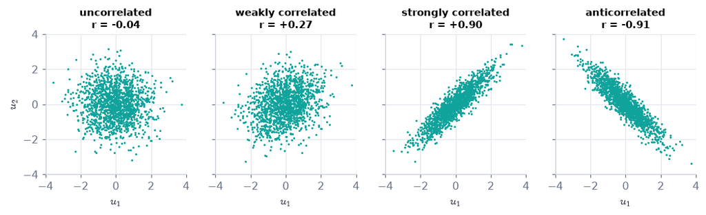

```python
fig, axs = plt.subplots(1, 4, figsize=(9.6, 2.7), sharex=True, sharey=True)   # a new figure and its panel(s); figsize in inches
for ax, r_set, name in zip(axs, (0.0, 0.3, 0.9, -0.9), ("uncorrelated", "weakly correlated", "strongly correlated", "anticorrelated")):
    a_, b_ = TS.correlated_pair(1500, r_set, seed=1)                     # a pair with the chosen coefficient
    r_meas = TS.correlation_coefficient(a_, b_)                          # Eq. (12.14) on the samples
    assert abs(r_meas - np.corrcoef(a_, b_)[0, 1]) < 0.01                # numpy's built-in gives the same number (it removes the tiny sample means first)
    ax.plot(a_, b_, ".", ms=2, color=C_FLUC)                             # one dot per sample
    ax.set(title=f"{name}\nr = {r_meas:+.2f}", xlim=(-4, 4), ylim=(-4, 4), aspect="equal", xlabel="$u_1$")   # axis labels (with units), title and fixed ranges of this panel
axs[0].set_ylabel("$u_2$")   # label / range / scale of this axis
plt.show()   # display the figure
```

**What you see.** Four clouds of dots: round ($r\approx0$), slightly tilted ($r\approx0.3$), a thin ellipse rising to the right ($r\approx0.9$), a thin ellipse falling to the right ($r\approx-0.9$).

**How to read it.** The tilt and thinness of the cloud *are* the correlation: $r=\pm1$ would be a straight line, $r=0$ a round cloud. Keep the last panel in mind — in C04 the two axes become $u$ and $v$ in a shear flow.

**What would change if…** …we doubled $u_2$: the cloud would stretch vertically and the covariance would double, but $r$ would not change — that is what dividing by the standard deviations buys.

> 📎 **Primer — a quadratic that is never negative has discriminant ≤ 0.** `P288` · If $a\lambda^2+b\lambda+c\ge0$ for **every** real $\lambda$ (with $a>0$), the parabola never dips below the axis, so it has at most one real root. By the quadratic formula (Ch. 6, P159) that means the *discriminant* $b^2-4ac$ is not positive: $b^2-4ac\le0$.

```python
lam = np.linspace(-5, 5, 1001)                    # many values of lambda
for a_, b_, c_ in ((1, 2, 2), (1, 2, 0.5)):       # two parabolas a lam^2 + b lam + c
    print(f"discriminant {b_**2 - 4*a_*c_:+.1f}: minimum of the parabola = {np.min(a_*lam**2 + b_*lam + c_):+.2f}")   # −4 → stays positive; +2 → dips below zero
```

```
discriminant -4.0: minimum of the parabola = +1.00
discriminant +2.0: minimum of the parabola = -0.50
```

#### 🧮 Derivation — The Schwartz inequality $\lvert\overline{uv}\rvert\le\sqrt{\overline{u^2}}\sqrt{\overline{v^2}}$ and $-1\le r\le1$ `D02` ★★ (Eq. 12.16: $\lvert\overline{uv}\rvert\le\sqrt{\overline{u^2}}\sqrt{\overline{v^2}}$)

**What we want to show.** Show that a correlation coefficient can never leave the range −1 … 1 — so "r = 0.9" means the same in every flow.

**Assumptions.** Finite variances; u and v are fluctuations at any two points and times.

**The plan.**

1. Expand the square into a quadratic in λ.
2. a quadratic that is never negative has discriminant ≤ 0.
3. Rearrange.

**Tools we use** (each explained before this point): the rules of D01 · discriminant of a quadratic (P288, primer above · quadratic formula P159)

**We start from**

$$ \overline{(u+\lambda v)^2}\ge0\ \text{for every real number λ} $$

*In words:* The average of a square cannot be negative

**Step 1 of 6 — Average a square that contains a free number λ.**

$$ \overline{(u+\lambda v)^2}\ge0\quad\text{for every real }\lambda $$

- *Why we can do this:* Each realization contributes a square, which is ≥ 0, so their average is ≥ 0. λ is a device: one inequality for every λ is a strong statement.
- *In words:* No mixture of u and v can have a negative mean square.

**Step 2 of 6 — Expand and average term by term.**

$$ \overline{v^2}\,\lambda^2+2\,\overline{uv}\,\lambda+\overline{u^2}\ge0 $$

- *Why we can do this:* $(u+\lambda v)^2=u^2+2\lambda uv+\lambda^2v^2$; λ is a constant, so D01's rules $\overline{u^m+v^m}=\overline{u^m}+\overline{v^m}$ (12.4) and $\overline{Au^m}=A\overline{u^m}$ (12.5) apply.
- *In words:* The inequality is a parabola in λ that never dips below zero.

**Step 3 of 6 — Apply the discriminant condition.**

$$ (2\,\overline{uv})^2-4\,\overline{v^2}\;\overline{u^2}\le0 $$

- *Why we can do this:* A parabola $a\lambda^2+b\lambda+c$ with a > 0 that is never negative has at most one real root, which requires $b^2-4ac\le0$ (P288).
- *In words:* The cross term cannot be too large compared with the two variances.

**Step 4 of 6 — Rearrange and take the square root.**

$$ \lvert\overline{uv}\rvert\le\sqrt{\overline{u^2}}\,\sqrt{\overline{v^2}} $$

- *Why we can do this:* Divide by 4, move one term across, take the positive root of both (non-negative) sides; $\sqrt{x^2}=\lvert x\rvert$ — hence the absolute value, which the printed $\overline{uv}\le\sqrt{\overline{u^2}}\sqrt{\overline{v^2}}$ (12.16) omits.
- *In words:* A covariance is never bigger in size than the product of the two rms values.

**Step 5 of 6 — Divide by the right-hand side.**

$$ -1\le r\equiv\dfrac{\overline{uv}}{\sqrt{\overline{u^2}}\sqrt{\overline{v^2}}}\le1 $$

- *Why we can do this:* Both rms values are positive, so dividing keeps the inequality; this is the coefficient of (12.14), $r_{12}=\overline{u_1u_2}/(\sqrt{\overline{u_1^2}}\sqrt{\overline{u_2^2}})$.
- *In words:* Every correlation coefficient lies between −1 and +1.

**Step 6 of 6 — Find when equality holds.**

$$ r=\pm1\iff v=c\,u\ \text{in every realization} $$

- *Why we can do this:* Equality means the parabola touches zero at some $\lambda_0$: $\overline{(u+\lambda_0v)^2}=0$, which forces $u+\lambda_0v=0$ in every realization.
- *In words:* Perfect correlation means one signal is a fixed multiple of the other.

**Result**

$$ \lvert\overline{uv}\rvert\le\sqrt{\overline{u^2}}\sqrt{\overline{v^2}}\ \text{(12.16), so}\ -1\le r\le1 $$

*In words:* a correlation coefficient is a pure number between −1 and 1

**What it means.** The Reynolds shear stress can never exceed $\rho\,u_{rms}v_{rms}$; in shear flows it is about 0.4 of that. The same inequality is the Cauchy–Schwarz inequality for vectors, $\lvert\mathbf a\cdot\mathbf b\rvert\le\lvert\mathbf a\rvert\lvert\mathbf b\rvert$, with "average of a product" as the dot product.

**Check it.** Units — both sides u·v. Number: u = (1, −1, 2, −2), v = (2, 0, 1, −3): $\overline{uv}$ = 2.5, bound √2.5 × √3.5 = 2.958, r = 0.845 ✓. Limits: v = u gives r = 1; v = −u gives −1. Code: `TS.correlation_coefficient` vs `np.corrcoef`.

📝 **Notes taught inside `D02`:** **N29 [B]** the Schwartz inequality $\lvert\overline{uv}\rvert\le\sqrt{\overline{u^2}}\sqrt{\overline{v^2}}$ (12.16) (steps 4–5); ⚠️ a trap, not a slip: the page prints it without the absolute value — true as printed, but then it says nothing about a negative correlation.

> ⚠️ **Common confusion (traps in `D02`):** Writing the discriminant condition as ≥ 0 (that is the condition for two real roots — a parabola that *does* cross zero); dropping the absolute value, as the page does (then r ≥ −1 would not follow).

#### 🧮 Derivation — Stationary lag forms, $R_{11}(\tau)=R_{11}(-\tau)$ and $R_{ij}(-\tau)=R_{ji}(\tau)$ `D03` ★ (Eq. 12.17: $R_{11}(\tau)=\overline{u_1(t)u_1(t+\tau)}=R_{11}(-\tau)$)

**What we want to show.** Show that for a stationary signal the correlation depends only on the time *difference*, and that the autocorrelation is the same for a lag forward or backward.

**Assumptions.** Temporally stationary; same point in space.

**The plan.**

1. Use stationarity to drop the absolute time.
2. Flip the sign of the lag.
3. Shift the time origin.

**Tools we use** (each explained before this point): substitution / change of variable (P106) · stationarity (N08)

**We start from**

$$ \begin{array}{l}R_{11}(t_1,t_2)\equiv\overline{u_1(t_1)u_1(t_2)}\ \text{at one point —}\ R_{11}(\mathbf x_1,t_1,\mathbf x_2,t_2)\equiv\overline{u_1(\mathbf x_1,t_1)u_1(\mathbf x_2,t_2)}\ \text{(12.13) with} \\ \mathbf x_1=\mathbf x_2\ \text{.}\end{array} $$

**Step 1 of 5 — Name the two times by a start and a lag.**

$$ R_{11}(t,\,t+\tau)=\overline{u_1(t)\,u_1(t+\tau)} $$

- *Why we can do this:* Any pair of times can be written as a time t and a difference τ = t₂ − t₁; nothing has been assumed yet.
- *In words:* We describe the pair by "when" and "how far apart".

**Step 2 of 5 — Use stationarity.**

$$ R_{11}(\tau)=\overline{u_1(t)\,u_1(t+\tau)}\quad\text{(the same for every }t) $$

- *Why we can do this:* Stationary means the statistics do not change when the time origin is moved, so the average cannot depend on t. This is (12.17), $R_{11}(\tau)=\overline{u_1(t)u_1(t+\tau)}=R_{11}(-\tau)$.
- *In words:* Only the lag matters.

**Step 3 of 5 — Replace τ by −τ.**

$$ R_{11}(-\tau)=\overline{u_1(t)\,u_1(t-\tau)} $$

- *Why we can do this:* Step 2 holds for any real lag, negative ones included; we want to compare the two.
- *In words:* Looking backward by τ instead of forward.

**Step 4 of 5 — Shift the time origin by τ.**

$$ \overline{u_1(t)\,u_1(t-\tau)}=\overline{u_1(t'+\tau)\,u_1(t')}=R_{11}(\tau),\quad t'=t-\tau $$

- *Why we can do this:* Substituting t = t′ + τ is allowed because, by step 2, the average does not care what the start time is called; the two factors commute.
- *In words:* The autocorrelation is an even function of the lag.

**Step 5 of 5 — Repeat for two different components.**

$$ R_{ij}(-\tau)=\overline{u_i(t)\,u_j(t-\tau)}=\overline{u_i(t'+\tau)\,u_j(t')}=R_{ji}(\tau) $$

- *Why we can do this:* The same shift; but now swapping the factors swaps the *roles* of i and j, so we get $R_{ji}$, not $R_{ij}$.
- *In words:* A cross-correlation is not even: mirroring the lag swaps which signal leads.

**Result**

$$ R_{11}(\tau)=\overline{u_1(t)u_1(t+\tau)}=R_{11}(-\tau)\ \text{(12.17);}\ R_{ij}(-\tau)=R_{ji}(\tau) $$

*In words:* An autocorrelation is even; a cross-correlation mirrors into its transpose

**What it means.** We only ever need r(τ) for τ ≥ 0 — which is why Λ_t integrates from 0 and why the spectrum (D05) is real. **Fails when:** the signal is not stationary (a decaying flow): then R depends on t as well.

**Check it.** Units u². τ = 0 gives the variance $\overline{u_1^2}$. Example: $R=\sigma^2e^{-\lvert\tau\rvert/\tau_c}$ is even ✓. Code: `TS.cross_correlation` of a signal and its copy delayed by 0.8 s peaks at +0.8 s one way round and −0.8 s the other.

> ⚠️ **Common confusion (traps in `D03`):** Assuming a cross-correlation is even; forgetting that the shift is legitimate *only* because of stationarity.

> 📎 **Primer — correlation by FFT with zero padding.** `P289` · The direct sum over lags costs (number of samples) × (number of lags). The FFT gives all lags at once: transform the record, multiply by its complex conjugate, transform back. The record must first be padded with zeros to at least twice its length, otherwise the end wraps round onto the beginning. "Unbiased" divides lag $m$ by $N-m$, the number of products actually available; far lags have few products and are noisy.

```python
x = np.random.default_rng(0).normal(size=16)      # 16 random numbers
direct = np.correlate(x, x, mode="full")[15:]     # direct sums for lags 0 … 15
F = np.fft.rfft(x, 32)                            # FFT of the record zero-padded to 32
via_fft = np.fft.irfft(F*np.conj(F))[:16]         # multiply by the conjugate, transform back, keep lags 0 … 15
print(np.allclose(direct, via_fft))               # True: the same sums
```

```
True
```

📝 **Note.** **N31 [B]** **The integral time scale** is the area under the autocorrelation coefficient: the width of the rectangle of height 1 with the same area. It is the *memory* of the signal. `TS.integral_scale(lag, r)` integrates to the first zero of $r$ (a measured tail only adds noise).

$$ \Lambda_t\equiv\int_0^\infty r_{11}(\tau)\,d\tau=\frac1{R_{11}(0)}\int_0^\infty R_{11}(\tau)\,d\tau \qquad \text{(12.18)} $$

📝 **Note.** **N32 [B]** **Correlation time and independent samples.** The correlation time $t_c$ is the first zero of $r_{11}$. The book counts the independent samples of a record of length $\Delta t$ as $N\approx\Delta t/t_c$; we use the statistician's $N=\Delta t/2\Lambda_t$ of primer P281 (`TS.effective_samples(record length, 2Λ_t)`), because $\Lambda_t$ is an area and far less noisy than a zero crossing. Both are order-of-magnitude counts — this is the $N$ of C01's $N^{-1/2}$.

#### ✏️ Tiny example: memory of an exponential correlation

Take $r(\tau)=e^{-\tau/\tau_c}$ with $\tau_c=0.5$ s.

1. $\Lambda_t=\int_0^\infty e^{-\tau/0.5}d\tau=0.5$ s.
2. A 100 s record holds about $100/0.5=200$ memory times.
3. So the standard error of its time mean is about $\sigma/\sqrt{200/2}=0.1\sigma$ (two memory times per independent sample for this shape).
4. For a Gaussian shape $r=e^{-\tau^2/\tau_c^2}$: $\Lambda_t=\tfrac{\sqrt\pi}2\tau_c=0.443$ s.

```python
dt = 0.01                                                     # sampling interval [s]
t_rec = np.arange(0.0, 500.0 if FAST else 2000.0, dt)         # one long record: 2000 s (500 s in FAST mode)
u_rec = TS.make_ensemble(1, t_rec, lambda t: 0*t, 1.0, 0.5, seed=3)[0]   # one OU run: std 1 m/s, memory 0.5 s
lag, R = TS.autocorrelation(u_rec, dt, max_lag=500)           # Eq. (12.17): R(tau) for lags 0 … 5 s (FFT, unbiased)
r = R/R[0]                                                    # the coefficient: divide by the variance R(0)
Lam = TS.integral_scale(lag, r)                               # Eq. (12.18): area under r up to its first zero [s]
t_c = TS.correlation_time(lag, r)                             # first zero crossing of r [s]
N_eff = TS.effective_samples(t_rec[-1], 2*Lam)                # independent samples in the record, N ≈ record length / (2 Λ_t) (primer P281)
print(f"variance R(0) = {R[0]:.3f} m²/s²;  Lambda_t = {Lam:.3f} s (exact 0.5);  t_c = {t_c:.2f} s;  N ≈ {N_eff:.0f}")
print(f"exact scales of the two shapes: {TS.correlation_spectrum_pair('exponential', 1.0, 0.5)['Lambda_t']:.3f} s, "
      f"{TS.correlation_spectrum_pair('gaussian', 1.0, 0.5)['Lambda_t']:.3f} s")
assert abs(Lam - 0.5) < 0.08                                  # the seeded estimate is within sampling error of the exact memory
```

```
variance R(0) = 0.978 m²/s²;  Lambda_t = 0.484 s (exact 0.5);  t_c = 2.11 s;  N ≈ 2067
exact scales of the two shapes: 0.500 s, 0.443 s
```

**What does the code above do?**

1. `TS.autocorrelation(u, dt, max_lag)` returns the lags [s] and $R_{11}(\tau)$ [m²/s²]; it uses the zero-padded FFT of the primer and the unbiased divisor.
2. `TS.integral_scale` gives $\Lambda_t\approx0.48$ s for this seeded record (exact value 0.5 s): a statistical estimate, not a round-off-exact number.
3. `TS.correlation_time` finds where $r$ first reaches zero — for an exponential it never truly does, so $t_c$ is set by noise in the tail; that is why $\Lambda_t$ (an area) is the more robust measure of memory, and why $N$ is counted with $2\Lambda_t$: about 2000 independent samples in this record.
4. The last line prints the exact scales of the tiny example from `TS.correlation_spectrum_pair`: 0.5 s and 0.443 s.

```python
# From scratch: the autocorrelation as a direct sum over lags, and the integral scale by the trapezoid rule
um = u_rec - u_rec.mean()                                     # remove the record mean
n_lags = 200                                                  # lags 0 … 1.99 s
R_loop = np.array([np.sum(um[:um.size - m]*um[m:])/(um.size - m) for m in range(n_lags)])   # mean of u(t) u(t + m dt), unbiased
assert np.allclose(R_loop, R[:n_lags])                        # the FFT route gives exactly these sums
r_loop = R_loop/R_loop[0]                                     # coefficient
first_zero = np.argmax(r < 0) if np.any(r < 0) else r.size    # index of the first negative value of r
Lam_mine = np.trapezoid(r[:first_zero], lag[:first_zero])     # area under r up to (just before) its first zero
print(f"Lambda_t by hand {Lam_mine:.4f} s, TS.integral_scale {Lam:.4f} s")
assert np.isclose(Lam_mine, Lam, rtol=0.02)                   # same area (the library interpolates the last partial step)
```

```
Lambda_t by hand 0.4839 s, TS.integral_scale 0.4839 s
```

**What does the code above do?**

1. `R_loop[m]` is literally "shift by $m$ samples, multiply, average" — the idea box in code.
2. The first `assert` shows the FFT route of the primer returns the same numbers.
3. The trapezoid area up to the first zero reproduces `TS.integral_scale` (the library also adds the sliver up to the interpolated zero, hence the 2 % tolerance).

📝 **Note.** **N34 [B]** **The picture of a memory.** The figure shows the measured coefficient, the exact exponential, and the rectangle of height 1 whose width is $\Lambda_t$.

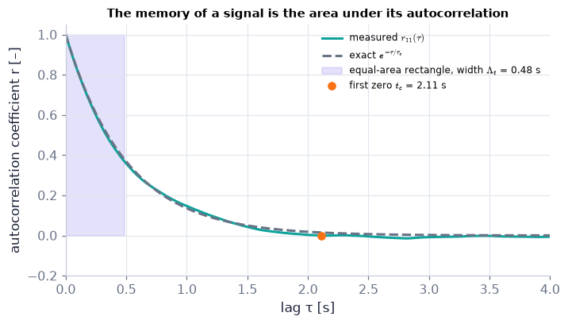

```python
fig, ax = plt.subplots(figsize=(6.4, 3.6))   # a new figure and its panel(s); figsize in inches
ax.plot(lag, r, color=C_FLUC, label="measured $r_{11}(\\tau)$")                       # the estimate from one record
ax.plot(lag, np.exp(-lag/0.5), "--", color=C_REF, label="exact $e^{-\\tau/\\tau_c}$")    # what an infinite record would give
ax.fill_between([0, Lam], [1, 1], color=C_MEAN, alpha=0.18, label=f"equal-area rectangle, width $\\Lambda_t$ = {Lam:.2f} s")   # the memory
ax.plot([t_c], [0], "o", color=C_RS, label=f"first zero $t_c$ = {t_c:.2f} s")           # the correlation time
ax.set(xlabel="lag τ [s]", ylabel="autocorrelation coefficient r [–]", xlim=(0, 4), ylim=(-0.2, 1.05),
       title="The memory of a signal is the area under its autocorrelation")
ax.legend(fontsize=8)   # the legend names every curve
plt.show()   # display the figure
```

**What you see.** A teal curve falling from 1 toward 0 along the dashed exponential, then wandering slightly about zero; a purple rectangle of height 1 and width ≈ 0.5 s; an orange dot where the curve first crosses zero.

**How to read it.** The rectangle has the same area as the curve: its width is the memory $\Lambda_t$. Samples closer than this are nearly copies of each other; samples several $\Lambda_t$ apart are independent.

**What would change if…** …the record were 20 s instead of 2000 s: the tail would wander far from zero and $\Lambda_t$ would depend on where we stop integrating — the reason `TS.integral_scale` stops at the first zero.

📝 **Note.** **N30 [B]** **Cross-correlation finds a delay.** Correlating two *different* signals as a function of lag, $R_{uv}(\tau)=\overline{u(t)v(t+\tau)}$, peaks at the lag that lines them up — the way two anemometers a known distance apart measure how fast eddies travel. Unlike an autocorrelation it is **not even**: $R_{uv}(\tau)=R_{vu}(-\tau)$ (D03 step 5). Animation A2 slides a delayed copy past the original.

```python
n_show = 600                                                  # samples shown: 6 s of the record
shift0 = 80                                                   # the built-in delay t_o = 80 samples = 0.8 s
u_a = u_rec[1000:1000 + n_show]                               # the original signal u(t)
u_b = u_rec[1000 - shift0:1000 - shift0 + n_show]             # v(t) = u(t − 0.8 s): a delayed copy
lag_x, R_x = TS.cross_correlation(u_rec[shift0:20000], u_rec[:20000 - shift0], dt, max_lag=200)   # R_uv for lags −2 … 2 s (v delayed by 0.8 s)
r_x = R_x/u_rec[:20000].var()                                 # normalise by the variance
tt_ = np.arange(n_show)*dt                                    # time axis of the window [s]
nfr = 24 if FAST else 45                                      # frames
lags_fr = np.linspace(-1.0, 2.0, nfr)                         # the trial lag swept by the animation [s]
fig, (a1, a2) = plt.subplots(2, 1, figsize=(6.8, 4.6))   # a new figure and its panel(s); figsize in inches
a1.plot(tt_, u_a, color=C_REF, lw=0.9, label="u(t)")          # the fixed signal
(ln_v,) = a1.plot(tt_, u_b, color=C_FLUC, lw=0.9, label="v(t + τ): the delayed copy, shifted back by τ")   # the sliding copy
a1.set(xlabel="time t [s]", ylabel="signal [m/s]", xlim=(0, 6), ylim=(-3.5, 3.5))   # axis labels (with units), title and fixed ranges of this panel
a1.legend(fontsize=7, loc="upper right")   # the legend names every curve
a2.plot(lag_x, r_x, color="0.85", lw=3)                       # the whole cross-correlation as a ghost
(ln_r,) = a2.plot([], [], color=C_RS, lw=1.8)                 # the part traced so far
(dot,) = a2.plot([], [], "o", color=C_RS)                     # the current lag
a2.axvline(0.8, color=C_REF, ls=":")   # a thin reference line
a2.set(xlabel="lag τ [s]", ylabel="$R_{uv}(τ)/\\sigma^2$ [–]", xlim=(-1, 2), ylim=(-0.2, 1.1))   # axis labels (with units), title and fixed ranges of this panel

def update(i):                                                # frame i: shift the copy by lags_fr[i] and mark the correlation there
    m = int(round(lags_fr[i]/dt))                             # the lag in samples
    seg = u_rec[1000 - shift0 + m:1000 - shift0 + m + n_show] # v(t + τ) on the window
    ln_v.set_ydata(seg)   # move the drawn objects to this frame's values
    keep = lag_x <= lags_fr[i]                                # lags already visited
    ln_r.set_data(lag_x[keep], r_x[keep])   # move the drawn objects to this frame's values
    dot.set_data([lags_fr[i]], [np.interp(lags_fr[i], lag_x, r_x)])   # move the drawn objects to this frame's values
    a1.set_title(f"τ = {lags_fr[i]:+.2f} s: mean of the product u·v = {np.mean(u_a*seg):+.2f} m²/s²", fontsize=10)   # label / range / scale of this axis
    return ln_v, ln_r, dot   # hand the result back to the caller

show_animation(animate(update, frames=nfr, fig=fig, interval=150), player="video", dpi=60)   # a smooth video
```

[video not shown]

**What does the code above do?**

1. `u_b` is the same record read 0.8 s earlier — a delayed copy, like a second probe downstream.
2. `TS.cross_correlation(u, v, dt, max_lag)` returns lags of **both signs** and $R_{uv}(\tau)$; if $v(t)=u(t-t_0)$ the peak is at $\tau=+t_0$.
3. `update(i)` slides the teal copy by the trial lag, prints the mean of the product in the title and extends the orange curve.

**What you see.** Top: a grey signal and a teal copy that slides sideways. Bottom: an orange curve being traced over a grey ghost; it climbs to a peak of 1 exactly when the two curves in the top panel coincide, at τ = 0.8 s (dotted line).

**How to read it.** The cross-correlation is largest at the lag that undoes the delay. It is not symmetric about τ = 0: its mirror image is the correlation with the two signals swapped.

**What would change if…** …the copy were also *distorted* (eddies change while they travel): the peak would still sit at the travel time but would be lower than 1 — the frozen-turbulence hypothesis of C03 is the statement that it stays near 1.

#### 🧮 Derivation — The Taylor microscale $\lambda_t^2\equiv-2/[d^2r_{11}/d\tau^2]_{\tau=0}$ as the foot of the osculating parabola; $\lambda_t^2=2\overline{u^2}/\overline{(du/dt)^2}$ `D04` ★★ (Eq. 12.19: $\lambda_t^2\equiv-2\big/\big[d^2r_{11}/d\tau^2\big]_{\tau=0}$)

**What we want to show.** Give the definition $\lambda_t^2\equiv-2\big/\big[d^2r_{11}/d\tau^2\big]_{\tau=0}$ (12.19) a picture (a parabola fitted to the top of the correlation curve) and a meaning (how fast the signal changes).

**Assumptions.** r twice differentiable at 0 (a smooth signal — **not** an Ornstein–Uhlenbeck one).

**The plan.**

1. Taylor-expand r about τ = 0.
2. Evenness kills the linear term.
3. Define λ_t where the parabola reaches zero.
4. Relate the curvature to the mean-square time derivative.

**Tools we use** (each explained before this point): Taylor series to second order (P26) · even functions (P261) · product rule (P38) · D01's $\overline{\partial u^m/\partial t}=\partial\overline{u^m}/\partial t$ (12.6) · stationarity

**We start from**

$$ r_{11}(\tau)\ \text{, even, with}\ r_{11}(0)=1\ \text{(D03).} $$

**Step 1 of 7 — Expand r about zero lag.**

$$ r_{11}(\tau)=1+r_{11}'(0)\,\tau+\tfrac12r_{11}''(0)\,\tau^2+\dots $$

- *Why we can do this:* Taylor's theorem for a twice-differentiable function; $r_{11}(0)=1$ by its definition. We want the shape of the curve's top.
- *In words:* Near zero lag the curve is a constant plus a slope plus a bend.

**Step 2 of 7 — Use evenness.**

$$ r_{11}'(0)=0 $$

- *Why we can do this:* An even, differentiable function has zero slope at the origin: $r(\tau)=r(-\tau)$ differentiated gives $r'(\tau)=-r'(-\tau)$, so $r'(0)=-r'(0)$.
- *In words:* The top of the curve is flat.

**Step 3 of 7 — Keep the first two terms.**

$$ r_{11}(\tau)\approx1+\tfrac12r_{11}''(0)\,\tau^2,\qquad r_{11}''(0)<0 $$

- *Why we can do this:* For small τ higher terms are negligible (≈). The curvature is negative because r has its maximum, 1, at τ = 0 (D02).
- *In words:* The top of the curve is a downward parabola.

**Step 4 of 7 — Call λ_t the lag where this parabola reaches zero.**

$$ 0=1+\tfrac12r_{11}''(0)\lambda_t^2\ \Rightarrow\ \lambda_t^2=-\dfrac{2}{r_{11}''(0)},\qquad r_{11}\approx1-\dfrac{\tau^2}{\lambda_t^2} $$

- *Why we can do this:* This is the definition (12.19), $\lambda_t^2\equiv-2\big/\big[d^2r_{11}/d\tau^2\big]_{\tau=0}$; the minus sign makes $\lambda_t^2$ positive because $r''(0)<0$.
- *In words:* λ_t is where the fitted parabola would hit the axis.

**Step 5 of 7 — Differentiate the correlation twice in the lag.**

$$ R_{11}''(\tau)=\overline{u(t)\,\dfrac{d^2u}{dt^2}(t+\tau)} $$

- *Why we can do this:* τ appears only in the second factor; the derivative passes inside the average by D01's $\overline{\partial u^m/\partial t}=\partial\overline{u^m}/\partial t$ (12.6).
- *In words:* The curvature of R is a correlation between the signal and its own acceleration.

**Step 6 of 7 — Set τ = 0 and use the product rule.**

$$ \overline{u\,\ddot u}=\dfrac{d}{dt}\overline{u\,\dot u}-\overline{\dot u^{\,2}}=-\overline{\dot u^{\,2}} $$

- *Why we can do this:* $\frac{d}{dt}(u\dot u)=\dot u^2+u\ddot u$; and $\overline{u\dot u}=\tfrac12\frac{d}{dt}\overline{u^2}=0$ because a stationary signal has constant variance.
- *In words:* The curvature at the top is minus the mean-square rate of change.

**Step 7 of 7 — Combine with step 4.**

$$ r_{11}''(0)=-\dfrac{\overline{(du/dt)^2}}{\overline{u^2}}\ \Rightarrow\ \lambda_t^2=\dfrac{2\,\overline{u^2}}{\overline{(du/dt)^2}} $$

- *Why we can do this:* Divide step 6 by $R_{11}(0)=\overline{u^2}$ to get r″(0) and substitute.
- *In words:* The microscale is the signal's size divided by how fast it changes.

**Result**

$$ \lambda_t^2=-2/r_{11}''(0)=2\overline{u^2}/\overline{(du/dt)^2} $$

*In words:* λ_t measures the fastest wiggles, Λ_t the memory

**What it means.** With r for the spatial correlation f, the same parabola gives λ_f, and the mean-square *velocity gradient* gives the dissipation (C05). **Fails when:** r has a corner at 0: $r=e^{-\lvert\tau\rvert/\tau_c}\approx1-\lvert\tau\rvert/\tau_c$ has no parabola — an Ornstein–Uhlenbeck signal has infinite $\overline{\dot u^2}$.

**Check it.** Units — s². Gaussian pair $r=e^{-\tau^2/\tau_c^2}$: $r''(0)=-2/\tau_c^2$, λ_t = τ_c ✓ (`correlation_spectrum_pair("gaussian", …) ["lambda_t"]`). Pure cosine $r=\cos\omega\tau$: λ_t = √2/ω.

📝 **Notes taught inside `D04`:** **N33 [B]** the Taylor microscale $\lambda_t^2\equiv-2\big/\big[d^2r_{11}/d\tau^2\big]_{\tau=0}$ (12.19): the lag at which the parabola that hugs the top of $r_{11}$ reaches zero (steps 3–4).

> ⚠️ **Common confusion (traps in `D04`):** Forgetting the minus sign; keeping a linear term; fitting the parabola over lags that are not small.

```python
gauss = TS.correlation_spectrum_pair("gaussian", 1.0, 0.5)    # the exact pair r = exp(−τ²/τ_c²) with τ_c = 0.5 s
u_s = TS.smooth_signal(2**16, 0.01, spectrum=gauss["S"], seed=4)   # a random record with that (smooth) spectrum
lag_s, R_s = TS.autocorrelation(u_s, 0.01, max_lag=300)       # its autocorrelation for lags 0 … 3 s
r_s = R_s/R_s[0]                                              # coefficient
lam_t = TS.taylor_microscale(lag_s, r_s)                      # Eq. (12.19): from the curvature of r at zero lag [s]
print(f"Taylor microscale {lam_t:.3f} s (exact: tau_c = {gauss['lambda_t']:.3f} s);  integral scale {TS.integral_scale(lag_s, r_s):.3f} s (exact {gauss['Lambda_t']:.3f} s)")
print("an OU signal has no microscale:", TS.correlation_spectrum_pair("exponential", 1.0, 0.5)["lambda_t"])   # nan
```

```
Taylor microscale 0.510 s (exact: tau_c = 0.500 s);  integral scale 0.460 s (exact 0.443 s)
an OU signal has no microscale: nan
```

**What does the code above do?**

1. `TS.smooth_signal(n, dt, spectrum)` builds a random record with a prescribed smooth spectrum (random phases again, P286); we give it the spectrum of a Gaussian correlation.
2. `TS.taylor_microscale` fits the parabola $1-\tau^2/\lambda_t^2$ to the first few lags: $\lambda_t\approx0.5$ s $=\tau_c$, as the exact pair says.
3. ⚠️ An Ornstein–Uhlenbeck signal has a *cusp* at zero lag, $r\approx1-\lvert\tau\rvert/\tau_c$: no parabola fits and its microscale does not exist (`nan`). Real turbulence is smooth at the smallest scales, so its microscale exists.

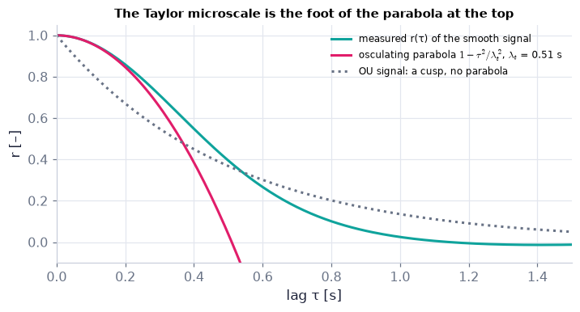

```python
fig, ax = plt.subplots(figsize=(6.4, 3.4))   # a new figure and its panel(s); figsize in inches
ax.plot(lag_s, r_s, color=C_FLUC, label="measured r(τ) of the smooth signal")                    # the estimate
ax.plot(lag_s, 1 - lag_s**2/lam_t**2, color=C_VISC, label=f"osculating parabola $1-\\tau^2/\\lambda_t^2$, $\\lambda_t$ = {lam_t:.2f} s")   # hugs the top
ax.plot(lag_s, np.exp(-lag_s/0.5), ":", color=C_REF, label="OU signal: a cusp, no parabola")      # for contrast
ax.set(xlabel="lag τ [s]", ylabel="r [–]", xlim=(0, 1.5), ylim=(-0.1, 1.05), title="The Taylor microscale is the foot of the parabola at the top")   # axis labels (with units), title and fixed ranges of this panel
ax.legend(fontsize=8)   # the legend names every curve
plt.show()   # display the figure
```

**What you see.** A teal bell-shaped correlation with a flat top; a rose parabola that follows it near τ = 0 and reaches zero at $\lambda_t\approx0.5$ s; a dotted exponential that starts with a sharp corner instead of a flat top.

**How to read it.** $\Lambda_t$ (an area) measures how long the memory lasts; $\lambda_t$ (a curvature) measures how fast the fastest wiggles are. The cusp of the dotted curve means infinitely fast wiggles — no microscale.

**What would change if…** …the signal contained faster wiggles (a wider spectrum): the top of $r$ would be more sharply curved and $\lambda_t$ smaller, with $\Lambda_t$ hardly changed.

**What would change if…** …we asked which *frequencies* carry the variance instead of how long the memory is? That is the Fourier transform of this same curve (C03).

### 🧩 The energy spectrum $S_e(\omega)\equiv\frac1{2\pi}\int_{-\infty}^{+\infty}R_{11}(\tau)e^{-i\omega\tau}d\tau$ (12.20) and the variance it distributes, $\overline{u_1^2}=\int_{-\infty}^{+\infty}S_e(\omega)\,d\omega$ (12.22) `C03`

*The question:* Which frequencies carry the variance, and why is that the same information as the memory?

#### The problem in plain words

A graphic equaliser shows how loud each pitch is. A spectrum does the same for a wind record: how much of the variance comes from slow gusts, how much from fast flutter. Ocean and atmosphere records are almost always shown this way, and the −5/3 law of C08 is a statement about a spectrum.

#### The idea

| Memory | The signal | Its spectrum |
| --- | --- | --- |
| long ($\Lambda_t$ large) | slow wiggles | squeezed near $\omega=0$, tall there |
| short ($\Lambda_t$ small) | fast wiggles | flat out to $\omega\approx1/\Lambda_t$, low |

Two facts to remember: **the area under $S_e$ is the variance, always; its height at zero frequency is variance × $\Lambda_t/\pi$.** Symbols: $\omega$ angular frequency [rad/s]; $S_e(\omega)$ the energy spectrum [m²/s² per rad/s = m²/s], defined for both signs of $\omega$ ("two-sided").

> 🔁 **Tools from earlier chapters used in this block** (one line each; the full primers are in the chapters named)
- **Euler's formula e^(iθ) = cos θ + i sin θ** — $e^{i\theta}=\cos\theta+i\sin\theta$ with $i^2=-1$: a complex exponential is a cosine (even part) plus $i$ times a sine (odd part). *(Ch. 1, P45)*
- **improper integrals** — integrate to a finite end, then let it run away: ∫₀^∞ $e^{-x}$dx = lim(1 − $e^{-b}$) = 1; a segment grows into an infinite line in D13. *(Ch. 5, P144)*
- **np.fft.rfft, Fourier modes** — any record is a sum of waves $e^{i\omega t}$; `np.fft.rfft(u)` returns their complex amplitudes at the frequencies `np.fft.rfftfreq(n, dt)`. *(Ch. 5, P142, Ch. 7, P181)*
- **scipy.integrate.quad** — adaptive integration: `quad(f, a, b)` returns the integral and an error estimate; `dblquad` does area integrals (inner limits as functions); used for section averages and Ex. 3.2. *(Ch. 3, P87)*

> 📎 **Primer — Fourier-transform pair: where the 2π sits.** `P290` · A Fourier-transform pair (forward and back) needs one factor $1/2\pi$ in total. The book puts it in the **forward** transform and uses angular frequency $\omega$ [rad/s]. For a real, even function the complex exponential $e^{-i\omega\tau}=\cos\omega\tau-i\sin\omega\tau$ (Euler's formula, Ch. 1 P45) reduces to a cosine, because the odd sine part integrates to zero: $\frac1{2\pi}\int_{-\infty}^{\infty}R\,e^{-i\omega\tau}d\tau=\frac1\pi\int_0^\infty R\cos\omega\tau\,d\tau$.

```python
tau_c_ = 0.5                                                  # memory time [s]
val = quad(lambda tau: np.exp(-tau/tau_c_)*np.cos(2.0*tau), 0, np.inf)[0]/np.pi   # (1/pi) ∫ R cos(ω τ) dτ at ω = 2 rad/s
print(round(val, 4), round(tau_c_/(np.pi*(1 + (2.0*tau_c_)**2)), 4))   # 0.0796 both ways: the closed form τ_c/[π(1 + ω²τ_c²)]
```

```
0.0796 0.0796
```

#### 🧮 Derivation — The spectrum–correlation pair, $S_e$ real and even, $\overline{u_1^2}=\int S_e\,d\omega$ and $S_e(0)=\overline{u_1^2}\Lambda_t/\pi$ `D05` ★★ (Eq. 12.20: $S_e(\omega)\equiv\frac1{2\pi}\displaystyle\int_{-\infty}^{+\infty}R_{11}(\tau)\,e^{-i\omega\tau}\,d\tau$)

**What we want to show.** Show that the spectrum is real, that its area is the variance, and that its value at zero frequency is the memory time in disguise.

**Assumptions.** Stationary; $R_{11}$ decays fast enough to be integrable.

**The plan.**

1. Split the exponential with Euler's formula.
2. The odd part integrates to zero.
3. State the inverse and set τ = 0.
4. Set ω = 0.

**Tools we use** (each explained before this point): Euler's formula (P45) · even and odd functions (P261) · improper integrals (P144) · the Fourier-transform pair (P290, primer above)

**We start from**

$$ S_e(\omega)\equiv\dfrac1{2\pi}\displaystyle\int_{-\infty}^{+\infty}R_{11}(\tau)\,e^{-i\omega\tau}\,d\tau\ \text{(12.20).} $$

**Step 1 of 9 — Start from the definition.**

$$ S_e(\omega)=\dfrac1{2\pi}\displaystyle\int_{-\infty}^{+\infty}R_{11}(\tau)\,e^{-i\omega\tau}\,d\tau $$

- *Why we can do this:* This is (12.20), $S_e(\omega)\equiv\frac1{2\pi}\displaystyle\int_{-\infty}^{+\infty}R_{11}(\tau)\,e^{-i\omega\tau}\,d\tau$: the forward Fourier transform in the book's convention — the 1/2π here, angular frequency ω in rad/s.
- *In words:* The spectrum weighs the correlation against a wave of frequency ω.

**Step 2 of 9 — Split the complex exponential.**

$$ e^{-i\omega\tau}=\cos\omega\tau-i\sin\omega\tau $$

- *Why we can do this:* Euler's formula (P45); it separates a part that is even in τ from a part that is odd.
- *In words:* A complex wave is a cosine and a sine.

**Step 3 of 9 — Split the integral the same way.**

$$ S_e=\dfrac1{2\pi}\displaystyle\int_{-\infty}^{\infty}R_{11}\cos\omega\tau\,d\tau-\dfrac{i}{2\pi}\int_{-\infty}^{\infty}R_{11}\sin\omega\tau\,d\tau $$

- *Why we can do this:* Integration is linear. The integral of a sum is the sum of the integrals, so the cosine part and the sine part can be looked at one at a time.
- *In words:* A real part and an imaginary part.

**Step 4 of 9 — Drop the sine integral.**

$$ \displaystyle\int_{-\infty}^{\infty}R_{11}(\tau)\sin\omega\tau\,d\tau=0 $$

- *Why we can do this:* $R_{11}$ is even (D03) and sine is odd, so the integrand is odd; an odd function integrated over a symmetric range gives zero (P261).
- *In words:* The spectrum has no imaginary part.

**Step 5 of 9 — Fold the cosine integral onto τ ≥ 0.**

$$ S_e(\omega)=\dfrac1\pi\displaystyle\int_0^\infty R_{11}(\tau)\cos\omega\tau\,d\tau=S_e(-\omega) $$

- *Why we can do this:* The integrand is even, so the two halves are equal: twice the integral from 0. Cosine is even in ω, so S is too.
- *In words:* The spectrum is real and symmetric: only τ ≥ 0 and ω ≥ 0 are needed.

**Step 6 of 9 — Write the inverse transform.**

$$ R_{11}(\tau)=\displaystyle\int_{-\infty}^{+\infty}S_e(\omega)\,e^{+i\omega\tau}\,d\omega $$

- *Why we can do this:* The Fourier inversion theorem (P290): transforming back needs the opposite sign in the exponent and no further 2π. This is (12.21), $R_{11}(\tau)\equiv\int_{-\infty}^{+\infty}S_e(\omega)e^{+i\omega\tau}d\omega$; the notebook verifies it on $R=\sigma^2e^{-\lvert\tau\rvert/\tau_c}$.
- *In words:* The correlation can be rebuilt from the spectrum — the same information.

**Step 7 of 9 — Set the lag to zero.**

$$ \overline{u_1^2}=R_{11}(0)=\displaystyle\int_{-\infty}^{+\infty}S_e(\omega)\,d\omega $$

- *Why we can do this:* $e^{0}=1$ and $R_{11}(0)$ is the variance. This is (12.22), $\overline{u_1^2}=\int_{-\infty}^{+\infty}S_e(\omega)\,d\omega$.
- *In words:* The area under the spectrum is the variance: S says how the variance is shared among frequencies.

**Step 8 of 9 — Set the frequency to zero in step 5.**

$$ S_e(0)=\dfrac1\pi\displaystyle\int_0^\infty R_{11}(\tau)\,d\tau $$

- *Why we can do this:* cos 0 = 1. We want the low-frequency end of the spectrum.
- *In words:* The spectrum at zero frequency is the area under the correlation.

**Step 9 of 9 — Use the definition of the integral scale.**

$$ S_e(0)=\dfrac{\overline{u_1^2}}{\pi}\displaystyle\int_0^\infty r_{11}(\tau)\,d\tau=\dfrac{\overline{u_1^2}}{\pi}\,\Lambda_t $$

- *Why we can do this:* $R_{11}=\overline{u_1^2}\,r_{11}$ and $\Lambda_t\equiv\int_0^\infty r_{11}\,d\tau$ (12.18). Dividing the correlation by the variance turns the integral into the memory time, which is the quantity we want to read off the spectrum.
- *In words:* A long memory means a tall spectrum at low frequency.

**Result**

$$ S_e(\omega)=\frac1\pi\int_0^\infty R_{11}\cos\omega\tau\,d\tau\ \text{is real and even;}\ \overline{u_1^2}=\int_{-\infty}^\infty S_e\,d\omega\ \text{(12.22);}\ S_e(0)=\overline{u_1^2}\Lambda_t/\pi $$

*In words:* Area = variance, height at zero = variance × memory / π

**What it means.** Correlation and spectrum are one description in two forms; stretch one and the other squeezes. The two-sided convention halves every ordinate relative to a one-sided spectrum. **Fails when:** R does not decay (a pure wave): the spectrum is then a spike.

**Check it.** Units — $R_{11}$ [m²/s²] × dτ [s] ⇒ $S_e$ [m²/s]; × dω [1/s] ⇒ m²/s² ✓. Exponential pair: $S_e=\sigma^2\tau_c/[\pi(1+\omega^2\tau_c^2)]$, $\int S_e\,d\omega=\sigma^2$ ✓, $S_e(0)=\sigma^2\tau_c/\pi$ ✓ (σ = 1, τ_c = 0.5 s: 0.159). Code: Parseval to round-off.

📝 **Notes taught inside `D05`:** **N35 [B]** the inverse transform $R_{11}(\tau)\equiv\int_{-\infty}^{+\infty}S_e(\omega)e^{+i\omega\tau}d\omega$ (12.21) (step 6) · **N36 [B]** the area is the variance, $\overline{u_1^2}\equiv\int_{-\infty}^{+\infty}S_e(\omega)\,d\omega$ (12.22) (step 7) · **N37 [B]** the height at zero is the memory, $S_e(0)=\overline{u_1^2}\Lambda_t/\pi$ (steps 8–9).

> ⚠️ **Common confusion (traps in `D05`):** Putting the 2π in the wrong transform; using cyclic frequency with angular formulas; forgetting the factor 2 when folding to one side; reading $S_e(0)$ as "energy at zero frequency" rather than a density.

#### ✏️ Tiny example: the pair for an exponential memory

$\sigma^2=1$ m²/s², $\tau_c=0.5$ s.

1. $S_e(\omega)=\sigma^2\tau_c/[\pi(1+\omega^2\tau_c^2)]$.
2. At $\omega=0$: $0.5/\pi=0.159$ m²/s — and $\overline{u^2}\Lambda_t/\pi=1\times0.5/\pi$ ✓.
3. At $\omega=2$ rad/s ($=1/\tau_c$): $0.5/(2\pi)=0.0796$, half the peak: the spectrum is flat to about $1/\tau_c$.
4. Area: $\int_{-\infty}^\infty S_e\,d\omega=\frac{\sigma^2}\pi[\arctan\omega\tau_c]_{-\infty}^{\infty}=\sigma^2$ ✓.

```python
pair = TS.correlation_spectrum_pair("exponential", 1.0, 0.5)  # the exact pair: r(τ), R(τ), S(ω) and its scales
lag_e = np.linspace(0.0, 15.0, 3001)                          # lags out to 30 memory times [s]
omega = np.linspace(0.0, 60.0, 601)                           # angular frequencies [rad/s]
S_num = TS.spectrum_from_correlation(lag_e, pair["R"](lag_e), omega)   # Eq. (12.20): cosine transform of R, done numerically
var_num = TS.spectrum_variance(omega, S_num)                  # Eq. (12.22): area under the two-sided spectrum
Lam_S = TS.integral_scale_from_spectrum(S_num[0], pair["R"](0.0))      # Λ_t = π S(0)/variance
R_back = TS.correlation_from_spectrum(omega, S_num, lag_e[:200])       # Eq. (12.21): back to the correlation
print(f"S(0) = {S_num[0]:.4f} m²/s (exact {pair['S0']:.4f});  S(2) = {np.interp(2.0, omega, S_num):.4f}")
print(f"area = {var_num:.3f} m²/s² (the variance is 1; the 2 % missing lies beyond ω = 60 rad/s);  Lambda_t = {Lam_S:.3f} s")
print(f"round trip correlation → spectrum → correlation: largest error {np.abs(R_back - pair['R'](lag_e[:200])).max():.3f}")
```

```
S(0) = 0.1592 m²/s (exact 0.1592);  S(2) = 0.0796
area = 0.979 m²/s² (the variance is 1; the 2 % missing lies beyond ω = 60 rad/s);  Lambda_t = 0.500 s
round trip correlation → spectrum → correlation: largest error 0.021
```

**What does the code above do?**

1. `TS.correlation_spectrum_pair(kind, sigma, tau_c)` returns the exact functions and scales of a correlation–spectrum pair (a dictionary: `r`, `R`, `S`, `Lambda_t`, `S0`, …).
2. `TS.spectrum_from_correlation` does the cosine integral of the primer at every $\omega$; $S(0)=0.159$ and $S(2)=0.080$ are the numbers of the tiny example.
3. `TS.spectrum_variance` integrates over both signs of $\omega$: 0.98 of the variance lies below 60 rad/s, the rest in the slowly decaying tail.
4. `TS.correlation_from_spectrum` goes back; the small error near zero lag is the missing tail again.

> 📎 **Primer — the discrete Fourier transform as a Riemann sum; Parseval.** `P291` · `np.fft.rfft(u)*dt` approximates $\int u\,e^{-i\omega t}dt$ at the frequencies $\omega_k=2\pi k/(N\,dt)$ (a Riemann sum: a sum of samples times the step). In the book's normalisation the two-sided spectral density of a record of length $T$ is $\lvert\hat u\rvert^2/(2\pi T)$. *Parseval's theorem*: its sum times $\Delta\omega$, over both signs of $\omega$, is exactly the variance. A *one-sided* spectrum (positive frequencies only) is twice the two-sided one.

```python
x = np.random.default_rng(1).normal(size=1024); x -= x.mean()   # a zero-mean record of 1024 samples
dts = 0.01; T_ = x.size*dts                                     # sampling step [s] and record length [s]
uhat = np.fft.rfft(x)*dts                                       # the Riemann sum for the Fourier integral
S2 = np.abs(uhat)**2/(2*np.pi*T_)                               # two-sided density |û|²/(2πT)
dw = 2*np.pi/T_                                                 # frequency step [rad/s]
total = dw*(S2[0] + 2*np.sum(S2[1:-1]) + S2[-1])                # both signs of ω: every interior frequency counts twice
print(round(total/x.var(), 6))                                  # 1.0: Parseval
```

```
1.0
```

> 📎 **Primer — segment averaging (Welch) and leakage.** `P292` · One raw periodogram (the $\lvert\hat u\rvert^2$ of the previous primer) is as noisy as its own mean, however long the record: more data gives more frequencies, not better ones. Cutting the record into $K$ segments and averaging their periodograms reduces the scatter by $\sqrt K$ at the price of frequency resolution. `scipy.signal.welch` does this with overlapping, tapered segments (the taper reduces *leakage*, the smearing of power between neighbouring frequencies). It returns a one-sided density per hertz: divide by $4\pi$ for the book's two-sided density per rad/s.

```python
x = TS.make_ensemble(1, np.arange(0, 1000, 0.01), lambda t: 0*t, 1.0, 0.5, seed=2)[0]   # a 1000 s OU record
f_hz, P_hz = signal.welch(x, fs=100.0, nperseg=4096)          # Welch estimate: frequency [Hz], one-sided density [m²/s² per Hz]
print(round(float(P_hz[1:4].mean()/(4*np.pi)), 3), "≈ S_e near ω = 0 (exact 0.159; about 48 segments, so ±15 % scatter)")   # convert to two-sided per rad/s
```

```
0.133 ≈ S_e near ω = 0 (exact 0.159; about 48 segments, so ±15 % scatter)
```

📝 **Note.** **N38 [B]** **The same spectrum straight from a record** (the Wiener–Khinchin theorem, stated): the spectrum is also the squared magnitude of the Fourier transform of the record itself, $S_e(\omega)=\lim_{T\to\infty}\frac1{2\pi T}\big\lvert\int_{-T/2}^{+T/2}u(t)e^{-i\omega t}dt\big\rvert^2$. The proof expands the square as a double integral over two times; changing variables to their difference $\tau$ leaves a triangular weight $(1-\lvert\tau\rvert/T)$ that tends to 1 (the same triangle returns in C16). The figure computes one spectrum three ways.

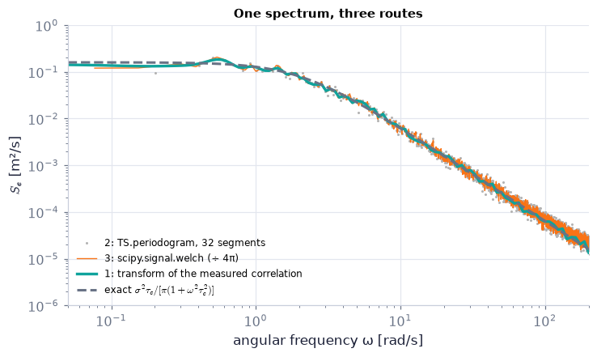

```python
om_fit = np.geomspace(0.05, 200.0, 120)                               # frequencies for route 1 [rad/s]
lag_l, R_l = TS.autocorrelation(u_rec, dt, max_lag=3000)              # the measured correlation out to 30 s
taper = 0.5*(1 + np.cos(np.pi*lag_l/lag_l[-1]))                       # a smooth taper to zero at the largest lag (reduces leakage)
S_route1 = TS.spectrum_from_correlation(lag_l, R_l*taper, om_fit)     # route 1: transform of the measured correlation, Eq. (12.20)
om2, S_route2 = TS.periodogram(u_rec, dt, segments=32)                # route 2: averaged periodogram (Exercise 12.8 form)
f_hz, P_hz = signal.welch(u_rec, fs=1/dt, nperseg=8192)               # route 3: scipy's Welch estimate
fig, ax = plt.subplots(figsize=(6.6, 3.9))   # a new figure and its panel(s); figsize in inches
ax.loglog(om2[1:], S_route2[1:], ".", ms=2, color="0.7", label="2: TS.periodogram, 32 segments")
ax.loglog(2*np.pi*f_hz[1:], P_hz[1:]/(4*np.pi), color=C_RS, lw=0.9, label="3: scipy.signal.welch (÷ 4π)")
ax.loglog(om_fit, S_route1, color=C_FLUC, lw=2.2, label="1: transform of the measured correlation")
ax.loglog(om_fit, pair["S"](om_fit), "--", color=C_REF, label="exact $\\sigma^2\\tau_c/[\\pi(1+\\omega^2\\tau_c^2)]$")
ax.set(xlabel="angular frequency ω [rad/s]", ylabel="$S_e$ [m²/s]", xlim=(0.05, 200), ylim=(1e-6, 1),
       title="One spectrum, three routes")
ax.legend(fontsize=8)   # the legend names every curve
plt.show()   # display the figure
```

**What you see.** Grey dots, an orange line and a bold teal line all following the same dashed curve on logarithmic axes: flat at about 0.16 m²/s up to ω ≈ 2 rad/s, then falling with slope −2.

**How to read it.** The corner at $\omega\approx1/\tau_c=2$ rad/s is the memory seen from the frequency side; the flat level is $\sigma^2\Lambda_t/\pi$. All three routes are estimates of the same function — they differ only in scatter.

**What would change if…** …we used one segment instead of 32: the grey dots would scatter by 100 % of their value at every frequency, however long the record (primer P292).

```python
# From scratch: the cosine transform by the trapezoid rule, and a periodogram scaled by hand
om50 = np.linspace(0.0, 20.0, 50)                             # 50 frequencies [rad/s]
S_mine = np.array([np.trapezoid(pair["R"](lag_e)*np.cos(w*lag_e), lag_e)/np.pi for w in om50])   # (1/π) ∫ R cos(ωτ) dτ
S_lib = TS.spectrum_from_correlation(lag_e, pair["R"](lag_e), om50, rule="trapezoid")            # the library with the same rule
assert np.allclose(S_mine, S_lib, rtol=1e-10)                 # identical sums
x = u_rec[:2**14] - u_rec[:2**14].mean()                      # a zero-mean stretch of the record
T_ = x.size*dt                                                # its length [s]
P_mine = np.abs(np.fft.rfft(x)*dt)**2/(2*np.pi*T_)            # two-sided density |û|²/(2πT) (primer P291)
om_p, P_lib = TS.periodogram(x, dt)                           # the library: one boxcar segment
assert np.allclose(P_mine, P_lib)                             # same numbers
dw = om_p[1] - om_p[0]                                        # frequency step
assert np.isclose(dw*(P_mine[0] + 2*np.sum(P_mine[1:-1]) + P_mine[-1]), x.var(), rtol=1e-12)   # Parseval: the area is the variance
print("cosine transform and periodogram reproduced by hand; Parseval holds to round-off")
```

```
cosine transform and periodogram reproduced by hand; Parseval holds to round-off
```

**What does the code above do?**

1. The cosine integral with `np.trapezoid` equals `TS.spectrum_from_correlation(..., rule="trapezoid")` to round-off.
2. The hand-scaled FFT equals `TS.periodogram`; summing it over both signs of $\omega$ returns the variance of the samples exactly (Parseval).

📝 **Note.** **N39 [B]** **In space instead of time.** For a homogeneous field the correlation depends only on the separation vector $\mathbf r$. `TS.spatial_correlation(a, b, dx)` computes it for a periodic field by averaging over the whole box.

$$ R_{ij}(\mathbf r)\equiv\overline{u_i(\mathbf x)u_j(\mathbf x+\mathbf r)} \qquad \text{(12.23)} $$

```python
r_sp, R_sp = TS.spatial_correlation(us, us, dxf, axis=-1)     # R_11(r) of the §12.1 field, separation along x
print(f"R_11(0) = {R_sp[0]:.3f} = mean(u²) = {np.mean(us**2):.3f} m²/s²;  integral length scale {TS.integral_scale(r_sp, R_sp/R_sp[0]):.4f} m")
```

```
R_11(0) = 0.886 = mean(u²) = 0.886 m²/s²;  integral length scale 0.1310 m
```

**What does the code above do?**

`TS.spatial_correlation` returns separations $r$ [m] and $R_{11}(r)$; at $r=0$ it is the mean square, and the area under the coefficient is an integral *length* scale — the size of the eddies of the synthetic field (centimetres to a decimetre in a 1 m box).

> 📎 **Primer — change of variable in a density; units of a spectral density.** `P293` · A density is "variance per unit of the axis". Changing the axis from $\omega$ to $k=\omega/U_0$ must keep the area: $S(k)\,dk=S(\omega)\,d\omega$, so $S(k)=U_0\,S(\omega)$. Units: $S_e$ is [m²/s² per rad/s] = m²/s; a wavenumber spectrum $S_{11}$ is [m²/s² per rad/m] = m³/s².

```python
U0 = 10.0                                                     # sweeping speed [m/s]
k_ax = omega/U0                                               # wavenumber axis k = ω/U0 [rad/m]
S_k = U0*pair["S"](omega)                                     # the density per unit k
print(round(np.trapezoid(pair["S"](omega), omega), 4), round(np.trapezoid(S_k, k_ax), 4))   # the two areas agree
```

```
0.4894 0.4894
```

📝 **Note.** **N40 [B]** **Taylor's frozen-turbulence hypothesis.** A probe moving at speed $U_0$ through the fluid — or a mean wind sweeping the eddies past a mast — sees a pattern that hardly changes while it passes. Time then stands for distance: $x=U_0t$, $\partial u_1/\partial x_1\approx-(1/U_0)\,\partial u_1/\partial t$, so $k_1=\omega/U_0$ and $S_{11}(k_1)=U_0S_e(\omega)$. It is accurate when the fluctuations are small against the sweeping speed, $u_{rms}/U_0\ll1$. **Climate hook:** tower and aircraft spectra are all converted to wavenumber this way.

```python
k_conv, S_conv = TS.frequency_to_wavenumber_spectrum(omega, pair["S"](omega), 10.0)   # k_1 = ω/U0, S_11 = U0 S_e
x_fr, u_fr = TS.taylor_frozen(t_rec[:5], u_rec[:5], 10.0)     # the first five samples placed in space: x = U0 t
print("x = U0 t [m]:", np.round(x_fr, 2), "| area kept:", round(np.trapezoid(S_conv, k_conv), 4))
pattern = us[0]                                               # one row of the §12.1 field: a periodic pattern F(x)
for ratio in (0.05, 0.2, 0.5):                                # fluctuation level u_rms/U0
    errs = [ch12.frozen_field_probe(pattern, 10.0, ratio*10.0, dt=dxf/10.0, dx=dxf, n_samples=n_s, seed=0)["reconstruction_error"]
            for n_s in (nfield//8, nfield)]                   # a short record (1/8 of the 1 m line, about one eddy) and the whole line
    print(f"u_rms/U0 = {ratio:4.2f}: reconstruction error {errs[0]:.2f} over 0.125 m, {errs[1]:.2f} over 1 m (in units of the pattern's rms)")
```

```
x = U0 t [m]: [0.  0.1 0.2 0.3 0.4] | area kept: 0.4894
u_rms/U0 = 0.05: reconstruction error 0.07 over 0.125 m, 0.35 over 1 m (in units of the pattern's rms)
u_rms/U0 = 0.20: reconstruction error 0.26 over 0.125 m, 0.87 over 1 m (in units of the pattern's rms)
u_rms/U0 = 0.50: reconstruction error 0.52 over 0.125 m, 1.09 over 1 m (in units of the pattern's rms)
```

**What does the code above do?**

1. `TS.frequency_to_wavenumber_spectrum` rescales both axes; the area (the variance) is unchanged.
2. `ch12.frozen_field_probe` sweeps a known spatial pattern past a probe at $U_0+u'$, where $u'$ is a random large-eddy velocity, and compares what the frozen hypothesis reconstructs with the true pattern (a simple "random sweeping" model of ours).
3. The error grows with $u_{rms}/U_0$ **and with the length of the record**: a wrong sweeping speed displaces the pattern by $(u'/U_0)\times$ distance, so a point-by-point reconstruction fails once that displacement exceeds an eddy size — at $u_{rms}/U_0=5$ % the error is 0.07 over one eddy (0.125 m) and 0.35 over the whole 1 m line. A *spectrum* is more forgiving: it is only stretched along $k_1$ by the factor $1+u'/U_0$. The hypothesis is for weak turbulence on a strong mean flow.

```python
om_ax = np.geomspace(0.02, 100.0, 150)                       # frequency axis [rad/s]

def f2(tau_c):                                                # the spectrum and its two landmarks for one memory time
    p = TS.correlation_spectrum_pair("exponential", 1.0, tau_c)   # exact pair with variance 1 m²/s²
    return {"S_e(ω) for r = exp(−τ/τ_c)": (om_ax, p["S"](om_ax)),   # hand the result back to the caller
            "level at zero frequency: σ²Λ_t/π": ([om_ax[0], 1.0/tau_c], [p["S0"], p["S0"]]),
            "corner frequency ω = 1/τ_c": ([1.0/tau_c, 1.0/tau_c], [1e-5, p["S0"]])}

figF2 = slider_figure(f2, "τ_c", np.round(np.geomspace(0.1, 5.0, 11 if FAST else 17), 3), unit="s", xlabel="angular frequency ω [rad/s]",
                      ylabel="S_e [m²/s]", title="Longer memory: a narrower, taller spectrum")
figF2.update_xaxes(type="log", range=[np.log10(0.02), 2.0])   # logarithmic frequency axis
figF2.update_yaxes(type="log", range=[-5.0, 0.5])             # logarithmic spectrum axis, fixed so the change is visible
figF2.show()   # display the interactive figure (the slider works on the web page too)
```

[interactive chart not shown]

**What does the code above do?**

1. `f2(tau_c)` returns the exact spectrum of an exponential memory and two landmarks: the horizontal level $\sigma^2\Lambda_t/\pi$ and the vertical line at the corner frequency $1/\tau_c$.
2. The correlation that belongs to each slider position is the curve of C02's figure, $r=e^{-\tau/\tau_c}$, with a rectangle of width $\tau_c$.

```python
tau_lin = np.linspace(0.0, 15.0, 150)                        # lags [s], linear axis

def f2b(tau_c):                                               # the correlation that belongs to the same slider value
    p = TS.correlation_spectrum_pair("exponential", 1.0, tau_c)
    return {"r(τ) = exp(−τ/τ_c)": (tau_lin, p["r"](tau_lin)),   # hand the result back to the caller
            "equal-area rectangle, width Λ_t = τ_c": ([0.0, tau_c, tau_c], [1.0, 1.0, 0.0])}

figF2b = slider_figure(f2b, "τ_c", np.round(np.geomspace(0.1, 5.0, 11 if FAST else 17), 3), unit="s", xlabel="lag τ [s]", ylabel="r [–]",
                       title="…while the correlation and its rectangle widen", xrange=(0, 15), yrange=(0, 1.05))
figF2b.show()   # display the interactive figure (the slider works on the web page too)
om_area = np.geomspace(1e-4, 1e5, 4000)                       # a very wide frequency range for the area check
for tc_ in (0.1, 1.0, 5.0):                                   # the area under the spectrum at three memory times
    p_ = TS.correlation_spectrum_pair("exponential", 1.0, tc_)
    print(f"τ_c = {tc_:3.1f} s: S_e(0) = {p_['S0']:.4f} m²/s, corner at {1/tc_:5.2f} rad/s, area 2∫S dω = {2*np.trapezoid(p_['S'](om_area)*om_area, np.log(om_area)):.3f} m²/s²")
```

[interactive chart not shown]

```
τ_c = 0.1 s: S_e(0) = 0.0318 m²/s, corner at 10.00 rad/s, area 2∫S dω = 1.000 m²/s²
τ_c = 1.0 s: S_e(0) = 0.3183 m²/s, corner at  1.00 rad/s, area 2∫S dω = 1.000 m²/s²
τ_c = 5.0 s: S_e(0) = 1.5915 m²/s, corner at  0.20 rad/s, area 2∫S dω = 1.000 m²/s²
```

**What does the code above do?**

1. The second slider figure shows the other half of the pair on **linear** axes: the correlation $r(\tau)$ and the rectangle of width $\Lambda_t=\tau_c$ with the same area. Use the same slider value in both figures.
2. The printed lines put numbers on what a log–log plot cannot show: the level $S_e(0)$ grows in proportion to $\tau_c$, the corner moves as $1/\tau_c$, and the area under the spectrum (both signs of $\omega$) stays at the variance, 1 m²/s².

**What you see.** First figure (log–log): drag $\tau_c$ up and the spectrum's corner moves to the left while its flat level rises in proportion. Second figure (linear): at the same slider value the correlation curve and its rectangle widen to the right.

**How to read it.** Width in lag × width in frequency stays constant — corner frequency × $\Lambda_t$ = 1 at every slider value: the corner sits at $\omega\approx1/\tau_c$ and the level at $\sigma^2\Lambda_t/\pi$. The area under the spectrum is the variance for every slider value — the cell prints 1.000 three times; on logarithmic axes you cannot see that by eye.

**What would change if…** …the correlation oscillated (a damped cosine): a peak would leave zero frequency and $\Lambda_t$ would collapse, because positive and negative lobes cancel in the area. The explainer below has that preset.

#### 🎮 Interactive: Why are a correlation and a spectrum the same information?

**Why interactive rather than a static figure:** stretching the memory narrows the spectrum in front of you while its area stays the variance and its height at zero follows the integral scale; sliding the lag shows the product being averaged.

Start with the **Walkthrough**; the **Explain** tab works every number out with your settings, and the **Derivation** tab steps through the same derivation as above.

**What to try:**

- Double the memory time: S(0) doubles, the corner frequency halves, the shaded area does not move.
- Switch to 'damped cosine' and raise ω₀: a peak leaves zero frequency and Λ_t collapses — an oscillating correlation has little net area.
- Click the spectrum: the inspector shows the cosine-transform arithmetic at that ω.
- Switch the axis to wavenumber with U₀ = 10 m/s.

```python
show_viz("ch12", "correlation_and_spectrum")   # full-width explainer; ⤢ Full screen for more room
```

🎮 Interactive 2/10 Why are a correlation and a spectrum the same thing? Open alone ↗

[interactive chart not shown]

**What would change if…** …we now put the decomposition mean + fluctuation into the equations of motion and averaged? Every term passes through the average except the product — C04.

## 12.5 Averaged Equations of Motion

**What is this section about?** We average the equations of motion. The mean flow obeys almost the same equations as before — plus one new term made of fluctuations, which acts like a stress and for which the averaging gives no equation.

> 🔁 **Recap — The Boussinesq equations in flux form `R01`** (Ch. 4 §4.9). From Ch. 4: continuity $\partial\tilde u_i/\partial x_i=0$ (4.10), momentum $\frac{\partial\tilde u_i}{\partial t}+\tilde u_j\frac{\partial\tilde u_i}{\partial x_j}=-\frac1{\rho_0}\frac{\partial\tilde p}{\partial x_i}-g[1-\alpha(\tilde T-T_0)]\delta_{i3}+\nu\frac{\partial^2\tilde u_i}{\partial x_j^2}$ (4.86) and heat $\frac{\partial\tilde T}{\partial t}+\tilde u_j\frac{\partial\tilde T}{\partial x_j}=\kappa\frac{\partial^2\tilde T}{\partial x_j^2}$ (4.89). Here $\rho_0$ is a constant reference density, $\alpha$ the thermal expansion coefficient [1/K], $T_0$ a reference temperature, $\delta_{i3}$ picks the vertical component, and repeated indices are summed (Ch. 2). Adding $\tilde u_i\,\partial\tilde u_j/\partial x_j=0$ turns $\tilde u_j\,\partial\tilde u_i/\partial x_j$ into $\partial(\tilde u_j\tilde u_i)/\partial x_j$ — the *flux form*: $\frac{\partial\tilde u_i}{\partial t}+\frac{\partial}{\partial x_j}(\tilde u_j\tilde u_i)=-\frac1{\rho_0}\frac{\partial\tilde p}{\partial x_i}-g[1-\alpha(\tilde T-T_0)]\delta_{i3}+\nu\frac{\partial^2\tilde u_i}{\partial x_j^2}$. This is step 1 of the derivation D06 below. (Ch. 4 also writes the momentum equation with deviations from a hydrostatic state, $D\mathbf u/Dt=-\rho_0^{-1}\nabla p'+(\rho'/\rho_0)\mathbf g+\nu\nabla^2\mathbf u$: put $\tilde p=p_0(z)+p'$ with $dp_0/dz=-\rho_0g$ and $\rho'=-\rho_0\alpha(\tilde T-T_0)$ into the form above and the two are the same equation; D10 quotes that second form.)

### 🧩 The Reynolds-averaged momentum equation $\frac{\partial U_i}{\partial t}+U_j\frac{\partial U_i}{\partial x_j}=-g[1-\alpha(\bar T-T_0)]\delta_{i3}+\frac1{\rho_0}\frac{\partial\bar\tau_{ij}}{\partial x_j}$, $\bar\tau_{ij}=-P\delta_{ij}+2\mu\bar S_{ij}-\rho_0\overline{u_iu_j}$ (12.30) `C04`

*The question:* How can fluctuations that average to zero push on the mean flow?

#### The problem in plain words

An aircraft designer wants the mean drag, a climate modeller the mean wind; neither wants every gust. (**N41 [C]**: the flight lasts hours, the gusts milliseconds, and the range of scales is far too wide to compute — C07 puts a number on it.) So we ask what equation the *mean* obeys. The surprise: the gusts do not average out of it.

#### The idea

```
fast  ────────────►   y + ℓ     a parcel coming DOWN  (v < 0) arrives too fast   (u > 0)   → uv < 0
slow  ─────►          y         a parcel going  UP    (v > 0) arrives too slow   (u < 0)   → uv < 0
every exchange carries x-momentum downward: mean(uv) < 0  ⇒  a stress −ρ₀·mean(uv) > 0 on the mean flow
```

Each of $u$ and $v$ averages to zero, but their *product* does not: in a shear, going up goes with being slow. That correlation is a transport of momentum, and a transport of momentum is a stress.

> 🔁 **Tools from earlier chapters used in this block** (one line each; the full primers are in the chapters named)
- **caching slow symbolic results** — save a long run once (`np.savez` in `outputs/chNN/`, parameters in the file name or a hash) and `np.load` it next time; `functools.lru_cache` in memory; the notebook says whether a result was loaded or computed. *(Ch. 10, P252)*

📝 **Note.** **N42 [B]** **The Reynolds decomposition**: every field = mean + fluctuation.

$$ \tilde u_i=U_i+u_i,\quad\tilde p=P+p,\quad\tilde\rho=\bar\rho+\rho',\quad\tilde T=\bar T+T' \qquad \text{(12.24)} $$

📝 **Note.** **N43 [B]** **The mean of a total field is the mean part** (by definition of the split).

$$ \overline{\tilde u_i}=U_i,\quad\overline{\tilde p}=P,\quad\overline{\tilde\rho}=\bar\rho,\quad\overline{\tilde T}=\bar T \qquad \text{(12.25)} $$

📝 **Note.** **N44 [B]** **A fluctuation has zero mean** — subtract the two lines above.

$$ \overline{u_i}=0,\quad\bar p=0,\quad\overline{\rho'}=0,\quad\overline{T'}=0 \qquad \text{(12.26)} $$

```python
mean_u, fluct_u = TS.reynolds_decompose(ens_u)                # Eq. (12.24): mean (one value per time) and fluctuation (per member and time)
print(mean_u.shape, fluct_u.shape)                            # (2000,) and (64, 2000)
print(f"largest |mean of the fluctuation|: {np.abs(fluct_u.mean(axis=0)).max():.1e}")   # Eq. (12.26): zero to round-off
```

```
(2000,) (64, 2000)
largest |mean of the fluctuation|: 5.5e-16
```

**What does the code above do?**

`TS.reynolds_decompose(samples)` subtracts the ensemble mean from every member. The mean of what is left is zero to round-off — $\overline{u_i}=0$ (12.26) is an identity, not an approximation.

> 📎 **Primer — a sympy averaging operator.** `P294` · We can teach sympy the rules of D01: the average is linear, leaves a mean alone, kills a single fluctuation, and keeps a product of two fluctuations as a new symbol. `ch12.rans_sympy()` uses exactly such an operator on the full equations; here is the idea on one product.

```python
U_, V_, u_, v_, uv_bar = sp.symbols("U V u v uv_bar")         # means U, V; fluctuations u, v; the symbol for mean(u v)
product = sp.expand((U_ + u_)*(V_ + v_))                      # (U + u)(V + v) = UV + Uv + uV + uv
averaged = product.subs(u_*v_, uv_bar).subs({u_: 0, v_: 0})   # mean(uv) → a new symbol; a lone fluctuation averages to 0
print(product, " → ", averaged)                               # U*V + U*v + V*u + u*v  →  U*V + uv_bar
```

```
U*V + U*v + V*u + u*v  →  U*V + uv_bar
```

#### 🧮 Derivation — Mean continuity, $\partial u_i/\partial x_i=0$ and the Reynolds-averaged momentum equation `D06` ★★ (Eq. 12.30: $\frac{\partial U_i}{\partial t}+U_j\frac{\partial U_i}{\partial x_j}=-g[1-\alpha(\bar T-T_0)]\delta_{i3}+\frac1{\rho_0}\frac{\partial\bar\tau_{ij}}{\partial x_j}$)

**What we want to show.** Find the equations obeyed by the mean flow, and see exactly where the fluctuations enter them.

**Assumptions.** Boussinesq (constant ρ₀, ν, α); ensemble average; $\bar T$ is potential temperature in the buoyancy term.

**The plan.**

1. Put the momentum equation in flux form.
2. Substitute mean + fluctuation.
3. Average with D01's rules.
4. Tidy the result into a stress.

**Tools we use** (each explained before this point): D01's rules · Reynolds decomposition $\tilde u_i=U_i+u_i$ (12.24) with $\overline{\tilde u_i}=U_i$ (12.25) and $\overline{u_i}=0$ (12.26) · product rule (P38) · summation convention (ch02)

**We start from**

$$ \begin{array}{l}\text{the Boussinesq set (R01):}\ \dfrac{\partial\tilde u_i}{\partial x_i}=0\ \text{(4.10) and} \\ \dfrac{\partial\tilde u_i}{\partial t}+\tilde u_j\dfrac{\partial\tilde u_i}{\partial x_j}=-\dfrac1{\rho_0}\dfrac{\partial\tilde p}{\partial x_i}-g\big[1-\alpha(\tilde T-T_0)\big]\delta_{i3}+\nu\dfrac{\partial^2\tilde u_i}{\partial x_j^2} \\ \text{(4.86).}\end{array} $$

**Step 1 of 13 — Write the advection term as a divergence.**

$$ \tilde u_j\dfrac{\partial\tilde u_i}{\partial x_j}=\dfrac{\partial}{\partial x_j}(\tilde u_j\tilde u_i)-\tilde u_i\dfrac{\partial\tilde u_j}{\partial x_j}=\dfrac{\partial}{\partial x_j}(\tilde u_j\tilde u_i) $$

- *Why we can do this:* Product rule, then continuity $\partial\tilde u_j/\partial x_j=0$ (4.10). A derivative of a product is easier to average than a product with a derivative.
- *In words:* Advection is the divergence of a momentum flux.

**Step 2 of 13 — Decompose the continuity equation.**

$$ \dfrac{\partial}{\partial x_i}(U_i+u_i)=0 $$

- *Why we can do this:* Substitute $\tilde u_i=U_i+u_i$ (12.24). Continuity holds for the total field in every realization; writing it with mean and fluctuation prepares it for averaging.
- *In words:* Mean plus fluctuation is divergence-free.

**Step 3 of 13 — Average it.**

$$ \dfrac{\partial}{\partial x_i}\big(U_i+\overline{u_i}\big)=\dfrac{\partial U_i}{\partial x_i}=0 $$

- *Why we can do this:* The average passes through the derivative (D01's $\overline{\partial u^m/\partial x_j}=\partial\overline{u^m}/\partial x_j$ (12.8)) and $\overline{u_i}=0$ (12.26). This is (12.27), $\partial U_i/\partial x_i=0$.
- *In words:* The mean flow is divergence-free.

**Step 4 of 13 — Subtract step 3 from step 2.**

$$ \dfrac{\partial u_i}{\partial x_i}=0 $$

- *Why we can do this:* Two true equations may be subtracted. This is (12.28), $\partial u_i/\partial x_i=0$; we need it in D10.
- *In words:* The fluctuation is divergence-free too.

**Step 5 of 13 — Substitute the decomposition into the flux-form momentum equation.**

$$ \begin{aligned}&\dfrac{\partial(U_i+u_i)}{\partial t}+\dfrac{\partial}{\partial x_j}\big((U_j+u_j)(U_i+u_i)\big)=-\dfrac1{\rho_0}\dfrac{\partial(P+p)}{\partial x_i}\\&\quad-g\big[1-\alpha(\bar T+T'-T_0)\big]\delta_{i3}+\nu\dfrac{\partial^2(U_i+u_i)}{\partial x_j^2}\end{aligned} $$

- *Why we can do this:* $\tilde u_i=U_i+u_i$, $\tilde p=P+p$, $\tilde T=\bar T+T'$ (12.24) in every field. This is (12.29), $\frac{\partial(U_i+u_i)}{\partial t}+\frac{\partial}{\partial x_j}\big((U_j+u_j)(U_i+u_i)\big)=-\frac1{\rho_0}\frac{\partial(P+p)}{\partial x_i}-g[1-\alpha(\bar T+T'-T_0)]\delta_{i3}+\nu\frac{\partial^2(U_i+u_i)}{\partial x_j^2}$; nothing has been approximated.
- *In words:* The exact equation, written for mean + fluctuation.

**Step 6 of 13 — Expand the product.**

$$ (U_j+u_j)(U_i+u_i)=U_iU_j+U_iu_j+u_iU_j+u_iu_j $$

- *Why we can do this:* Plain algebra; four terms: mean × mean, two mixed, fluctuation × fluctuation.
- *In words:* The momentum flux has four pieces.

**Step 7 of 13 — Average the product.**

$$ \overline{(U_j+u_j)(U_i+u_i)}=U_iU_j+U_i\overline{u_j}+\overline{u_i}U_j+\overline{u_iu_j}=U_iU_j+\overline{u_iu_j} $$

- *Why we can do this:* D01 step 7: a mean factors out, a single fluctuation averages to zero, a product of two fluctuations does not.
- *In words:* The mixed terms vanish; the covariance survives.

**Step 8 of 13 — Average the linear terms.**

$$ \overline{\dfrac{\partial(U_i+u_i)}{\partial t}}=\dfrac{\partial U_i}{\partial t},\ \ \overline{\dfrac{\partial(P+p)}{\partial x_i}}=\dfrac{\partial P}{\partial x_i},\ \ \overline{T'}=0,\ \ \overline{\dfrac{\partial^2(U_i+u_i)}{\partial x_j^2}}=\dfrac{\partial^2U_i}{\partial x_j^2} $$

- *Why we can do this:* Each is linear in the fields, so D01's rules $\overline{u+v}=\bar u+\bar v$ (12.4), $\overline{Au}=A\bar u$ (12.5), $\overline{\partial u/\partial t}=\partial\bar u/\partial t$ (12.6), $\overline{\partial u/\partial x_j}=\partial\bar u/\partial x_j$ (12.8) and $\overline{u_i}=0$ (12.26) leave the mean part only.
- *In words:* Every linear term keeps its form with the mean in place of the total.

**Step 9 of 13 — Collect the averaged equation.**

$$ \dfrac{\partial U_i}{\partial t}+\dfrac{\partial}{\partial x_j}(U_iU_j)+\dfrac{\partial\overline{u_iu_j}}{\partial x_j}=-\dfrac1{\rho_0}\dfrac{\partial P}{\partial x_i}-g\big[1-\alpha(\bar T-T_0)\big]\delta_{i3}+\nu\dfrac{\partial^2U_i}{\partial x_j^2} $$

- *Why we can do this:* Steps 7 and 8 inside step 5. One term has no counterpart in the original equation.
- *In words:* The mean obeys the same equation plus the divergence of $\overline{u_iu_j}$.

**Step 10 of 13 — Return the mean advection to its usual form.**

$$ \dfrac{\partial}{\partial x_j}(U_iU_j)=U_j\dfrac{\partial U_i}{\partial x_j}+U_i\dfrac{\partial U_j}{\partial x_j}=U_j\dfrac{\partial U_i}{\partial x_j} $$

- *Why we can do this:* Product rule and the mean continuity equation $\partial U_j/\partial x_j=0$ (12.27) — step 1 run backwards for the mean.
- *In words:* The mean flow advects its own momentum.

**Step 11 of 13 — Write the viscous term as a divergence of a stress.**

$$ \nu\dfrac{\partial^2U_i}{\partial x_j^2}=\dfrac1{\rho_0}\dfrac{\partial}{\partial x_j}\big(2\mu\bar S_{ij}\big),\quad\bar S_{ij}=\tfrac12\Big(\dfrac{\partial U_i}{\partial x_j}+\dfrac{\partial U_j}{\partial x_i}\Big) $$

- *Why we can do this:* $\partial(2\bar S_{ij})/\partial x_j=\partial^2U_i/\partial x_j^2+\partial(\partial U_j/\partial x_j)/\partial x_i$ and the last term is zero by $\partial U_j/\partial x_j=0$ (12.27); μ = ρ₀ν (the mean-flow form of Ch. 4's $\mu\,\partial^2u_j/\partial x_i^2=2\mu\,\partial S_{ij}/\partial x_i$ (4.40)).
- *In words:* Viscous friction of the mean flow is a stress, as in a laminar flow.

**Step 12 of 13 — Write the pressure gradient the same way and move the new term to the right.**

$$ -\dfrac1{\rho_0}\dfrac{\partial P}{\partial x_i}-\dfrac{\partial\overline{u_iu_j}}{\partial x_j}=\dfrac1{\rho_0}\dfrac{\partial}{\partial x_j}\big(-P\delta_{ij}-\rho_0\overline{u_iu_j}\big) $$

- *Why we can do this:* $\partial(P\delta_{ij})/\partial x_j=\partial P/\partial x_i$; moving a term across the equals sign changes its sign; ρ₀ is constant.
- *In words:* The covariance sits beside pressure and viscous stress — it acts as a stress.

**Step 13 of 13 — Assemble.**

$$ \dfrac{\partial U_i}{\partial t}+U_j\dfrac{\partial U_i}{\partial x_j}=-g\big[1-\alpha(\bar T-T_0)\big]\delta_{i3}+\dfrac1{\rho_0}\dfrac{\partial}{\partial x_j}\big(-P\delta_{ij}+2\mu\bar S_{ij}-\rho_0\overline{u_iu_j}\big) $$

- *Why we can do this:* Steps 9–12 together. This is (12.30), $\frac{\partial U_i}{\partial t}+U_j\frac{\partial U_i}{\partial x_j}=-g[1-\alpha(\bar T-T_0)]\delta_{i3}+\frac1{\rho_0}\frac{\partial\bar\tau_{ij}}{\partial x_j}$ with $\bar\tau_{ij}=-P\delta_{ij}+2\mu\bar S_{ij}-\rho_0\overline{u_iu_j}$.
- *In words:* The mean flow feels pressure, viscous stress and a third stress made by the fluctuations.

**Result**

$$ \begin{array}{l}\dfrac{\partial U_i}{\partial x_i}=0\ \text{(12.27);}\ \dfrac{\partial U_i}{\partial t}+U_j\dfrac{\partial U_i}{\partial x_j}=-g[1-\alpha(\bar T-T_0)]\delta_{i3}+\dfrac1{\rho_0}\dfrac{\partial\bar\tau_{ij}}{\partial x_j} \\ \text{(12.30)}\end{array} $$

*In words:* The mean flow obeys the Navier–Stokes equations with one extra stress, $-\rho_0\overline{u_iu_j}$

**What it means.** Four equations — $\partial U_i/\partial x_i=0$ (12.27) and the three components of $\frac{\partial U_i}{\partial t}+U_j\frac{\partial U_i}{\partial x_j}=-g[1-\alpha(\bar T-T_0)]\delta_{i3}+\frac1{\rho_0}\frac{\partial\bar\tau_{ij}}{\partial x_j}$ (12.30) — for ten unknowns ($U_i$, P and six $\overline{u_iu_j}$): the closure problem. The rest of the chapter measures, scales or models this one term. **Fails when:** the density varies strongly (compressible flows need mass-weighted averages).

**Check it.** Units — $\rho_0\overline{u_iu_j}$ is kg/m³ × m²/s² = Pa ✓. Limit: no fluctuations ⇒ $\overline{u_iu_j}=0$, the stress is $\bar\tau_{ij}=-P\delta_{ij}+2\mu\bar S_{ij}$ (12.30) and the Result is the laminar equation ✓. Number: $\overline{uv}=-0.1$ m²/s² in air ⇒ 0.12 Pa (C04 worked example). Code: `ch12.rans_sympy()` reproduces steps 5–9 symbolically.

📝 **Notes taught inside `D06`:** **N45 [B]** mean continuity $\partial U_i/\partial x_i=0$ (12.27) (step 3) · **N46 [B]** the fluctuation is divergence-free too, $\partial u_i/\partial x_i=0$ (12.28) (step 4) · **N47 [B]** the decomposed momentum equation $\frac{\partial(U_i+u_i)}{\partial t}+\frac{\partial}{\partial x_j}\big((U_j+u_j)(U_i+u_i)\big)=-\frac1{\rho_0}\frac{\partial(P+p)}{\partial x_i}-g[1-\alpha(\bar T+T'-T_0)]\delta_{i3}+\nu\frac{\partial^2(U_i+u_i)}{\partial x_j^2}$ (12.29) (step 5) · **N48 [B]** the term-by-term averages (steps 7–9).

> ⚠️ **Common confusion (traps in `D06`):** Averaging $\tilde u_j\,\partial\tilde u_i/\partial x_j$ without first writing it as a divergence (possible, but messier); thinking $\overline{U_iu_j}\neq0$; losing the minus sign when the new term crosses to the right; reading $\bar T$ as the thermometer temperature.

```python
eqs = ch12.rans_sympy()                                       # the averaging of D06 done by sympy (cached after the first run)
for label, _expr in eqs["steps"]:                             # the steps it took, by name
    print("•", label)
print("checks against the book's equations:", eqs["checks"])  # each True: the averaged equation equals the book's form
ny_ = 32                                                      # a small grid for an ensemble of fields
members = [TS.synthetic_solenoidal_field(ny_, 1.0, spectrum=lambda K: K**4*np.exp(-(K/12.0)**2), seed=s) for s in range(16)]   # 16 divergence-free fields
ens_fu = np.array([m_[0] for m_ in members]); ens_fv = np.array([m_[1] for m_ in members])   # members on axis 0
div_mean = ch12.mean_divergence(ens_fu, ens_fv, 1.0/ny_, 1.0/ny_)   # divergence of the ensemble-MEAN field
scale = np.sqrt(np.mean(ens_fu**2))*ny_                       # a typical (speed / grid spacing) to compare with
print(f"largest divergence of the mean field / (u_rms/dx): {np.abs(div_mean).max()/scale:.1e}")   # round-off: Eq. (12.27)
```

```
• mean continuity (12.27)
• fluctuation continuity (12.28)
• averaged x1-momentum, flux form (before (12.30))
• mean temperature (12.31)
• mean scalar (12.34)
checks against the book's equations: {'eq_12_27': True, 'eq_12_28': True, 'eq_12_30': True, 'eq_12_31': True, 'eq_12_34': True}
largest divergence of the mean field / (u_rms/dx): 4.5e-16
```

**What does the code above do?**

1. `ch12.rans_sympy()` inserts mean + fluctuation into the Boussinesq equations and averages with the operator of primer P294. Its `checks` say that the results equal $\partial U_i/\partial x_i=0$ (12.27), $\partial u_i/\partial x_i=0$ (12.28), the mean momentum equation of this block's title, and the mean temperature and scalar equations stated below. The collected momentum equation has exactly one term with no counterpart in the instantaneous equation: $\partial\overline{u_iu_j}/\partial x_j$.
2. `ch12.mean_divergence` checks **N45** on numbers: every member of an ensemble of divergence-free fields is divergence-free, so the mean field is too (to round-off), and so is each fluctuation.

> 📎 **Primer — counting the independent components of a symmetric tensor.** `P295` · A symmetric 3 × 3 tensor has 6 independent components (3 on the diagonal + 3 above it). A fully symmetric triple product $\overline{u_iu_ju_k}$ has 10. `itertools.product(range(3), repeat=3)` lists all 27 index triples; sorting each and collecting them in a set counts the distinct ones.

```python
pairs = {tuple(sorted(c)) for c in itertools.product(range(3), repeat=2)}     # distinct index pairs (i, j) up to order
triples = {tuple(sorted(c)) for c in itertools.product(range(3), repeat=3)}   # distinct index triples up to order
print(len(pairs), len(triples))                               # 6 and 10
```

```
6 10
```

📝 **Note.** **N49 [B]** **The Reynolds stress tensor** $-\rho_0\overline{u_iu_j}$ [Pa] is symmetric, so it has six components. The diagonal ones are normal stresses that add to the mean pressure; the off-diagonal ones are shear stresses. It is a covariance matrix (primer P287) times $-\rho_0$. Except within a hair of a wall it is far larger than the viscous stress $2\mu\bar S_{ij}$, where $\bar S_{ij}=\tfrac12(\partial U_i/\partial x_j+\partial U_j/\partial x_i)$ is the mean strain rate. `TS.velocity_covariance` gives $\overline{u_iu_j}$ from samples, `TS.reynolds_stress` multiplies by $-\rho_0$, and `TS.anisotropy_tensor` subtracts the isotropic part ($\overline{u_iu_j}/2\bar e-\delta_{ij}/3$; zero for turbulence with no preferred direction).

> 🔁 **Recap — Sign convention of a stress on a face `R02`** (Ch. 2 §2.4). As for the stress cube of Ch. 2: $\tau_{ij}$ is the force per area in direction $i$ on the face whose outward normal points along $+j$. So a positive $-\rho_0\overline{uv}$ on the face whose outward normal is $+y$ pushes the fluid below it along $+x$ — drawn in the left panel of the figure below.

📝 **Note.** **N50 [B]** **The parcel argument.** A parcel displaced upward by $\ell$ keeps its old mean speed for a while, so where it arrives it is too slow: $u\approx-\ell\,dU/dy$. Multiply by $v$ and average: $\overline{uv}\approx-\overline{v\ell}\,dU/dy<0$ when $dU/dy>0$, because $v$ and $\ell$ have the same sign (a parcel that is going up has gone up).

📝 **Note.** **N51 [B]** **Reynolds stress = momentum flux.** $\rho_0\overline{(U+u)v}=\rho_0U\bar v+\rho_0\overline{uv}=\rho_0\overline{uv}$ is the mean flux of $x$-momentum in the $y$-direction carried by the fluctuations (the first term vanishes because $\bar v=0$). A downward flux of $x$-momentum is what a shear stress *is*.

> ⚠️ **slip #16 — the book prints** the mean momentum flux as $\rho_0\overline{(U+u)v}=\rho_0U\bar u+\rho_0\overline{uv}=\rho_0\overline{uv}$ **; the correct form is** $\rho_0\overline{(U+u)v}=\rho_0U\bar v+\rho_0\overline{uv}=\rho_0\overline{uv}$: expand $(U+u)v=Uv+uv$ and average — $U$ is a mean, so $\overline{Uv}=U\bar v=0$. The middle term that vanishes is $\rho_0U\bar v$, not $\rho_0U\bar u$; the result is unchanged.

#### ✏️ Tiny example: the stress carried by parcels

$dU/dy=2$ s⁻¹; parcels move $\ell_{rms}=0.1$ m with $v_{rms}=0.5$ m/s and keep all their momentum.

1. $u\approx-\ell\,dU/dy$ has rms $0.2$ m/s.
2. $\overline{uv}=-v_{rms}\ell_{rms}\,dU/dy=-0.5\times0.1\times2=-0.1$ m²/s².
3. In air ($\rho_0=1.2$ kg/m³): Reynolds shear stress $-\rho_0\overline{uv}=0.12$ Pa.
4. Viscous stress $\mu\,dU/dy=1.8\times10^{-5}\times2=3.6\times10^{-5}$ Pa — 3000 times smaller.
5. The viscosity that would do the same job: $\nu_T=-\overline{uv}/(dU/dy)=0.05$ m²/s, against $\nu=1.5\times10^{-5}$ m²/s.

```python
out = ch12.displaced_parcel_uv(2.0, 0.1, 0.5, n=100_000, seed=0)   # 100 000 parcels: dU/dy = 2 1/s, l_rms = 0.1 m, v_rms = 0.5 m/s
expected = ch12.parcel_uv_expected(2.0, 0.1, 0.5)             # the tiny example's −v_rms l_rms dU/dy [m²/s²]
print(f"mean(uv) = {out['uv']:.4f} ± {out['stderr']:.4f} m²/s²  (expected {expected:.3f});  r_uv = {out['r_uv']:.2f};  nu_T = {out['nu_T']:.3f} m²/s")
assert abs(out["uv"] - expected) < 5*out["stderr"]            # within 5 standard errors (primer P281)
half = ch12.displaced_parcel_uv(2.0, 0.1, 0.5, n=100_000, seed=0, correlation=0.5)   # parcels that only half remember where they came from
print(f"with correlation 0.5 between v and l: mean(uv) = {half['uv']:.4f} m²/s², r_uv = {half['r_uv']:.2f}")
print(f"Reynolds stress in air: {-1.2*out['uv']:.3f} Pa;  viscous stress: {1.8e-5*2.0:.1e} Pa")
```

```
mean(uv) = -0.1000 ± 0.0005 m²/s²  (expected -0.100);  r_uv = -1.00;  nu_T = 0.050 m²/s
with correlation 0.5 between v and l: mean(uv) = -0.0502 m²/s², r_uv = -0.50
Reynolds stress in air: 0.120 Pa;  viscous stress: 3.6e-05 Pa
```

**What does the code above do?**

1. `ch12.displaced_parcel_uv(dUdy, l_rms, v_rms, n, seed)` draws $n$ parcels: a displacement $\ell$, a vertical velocity $v$ with the same sign, and $u=-\ell\,dU/dy$. It returns a dictionary with the samples (`u`, `v`, `l`), the mean product `uv`, its standard error, the correlation coefficient `r_uv` and the equivalent viscosity `nu_T`.
2. The mean product is $-0.100$ m²/s² within its standard error — steps 2 and 5 of the tiny example.
3. With `correlation=0.5` (a parcel's $v$ is only half related to where it came from) the stress halves and $r_{uv}=-0.5$: the stress is as large as the *correlation* between going up and being slow.

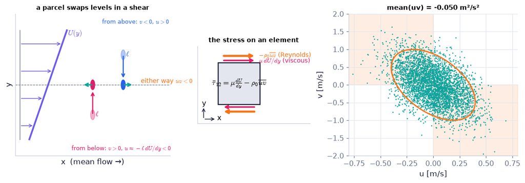

```python
fig, (a1, a2, a3) = plt.subplots(1, 3, figsize=(10.5, 3.6), gridspec_kw=dict(width_ratios=[1.1, 0.8, 1.2]))   # a new figure and its panel(s); figsize in inches
parcel_sketch(a1, shear=1.0)                                  # drawing: two parcels swapping levels in a shear
stress_element_sketch(a2)                                     # drawing: the stress on the faces of a fluid element (recap R02)
a1.set_title("a parcel swaps levels in a shear", fontsize=9); a2.set_title("the stress on an element", fontsize=9)   # short panel titles
uu_, vv_ = half["u"][:4000], half["v"][:4000]                 # 4000 of the half-correlated parcels (a fatter cloud shows the tilt better)
a3.plot(uu_, vv_, ".", ms=1.5, color=C_FLUC)                  # one dot per parcel in the (u, v) plane
a3.fill_between([-0.8, 0], 0, 2.0, color=C_RS, alpha=0.12)    # quadrant 2: u < 0, v > 0 (going up, too slow)
a3.fill_between([0, 0.8], -2.0, 0, color=C_RS, alpha=0.12)    # quadrant 4: u > 0, v < 0 (coming down, too fast)
cov2 = np.cov(uu_, vv_)                                       # the 2 × 2 covariance matrix of the cloud
evals, evecs = np.linalg.eigh(cov2)                           # its principal axes (primer P287)
th = np.linspace(0, 2*np.pi, 100)                             # angle round the ellipse
ell = evecs @ (2*np.sqrt(evals)[:, None]*np.array([np.cos(th), np.sin(th)]))   # the 2-standard-deviation ellipse
a3.plot(ell[0], ell[1], color=C_RS, lw=1.8)                   # the covariance ellipse
a3.set(xlabel="u [m/s]", ylabel="v [m/s]", xlim=(-0.8, 0.8), ylim=(-2.0, 2.0), title=f"mean(uv) = {half['uv']:.3f} m²/s²")   # axis labels (with units), title and fixed ranges of this panel
plt.show()   # display the figure
```

**What you see.** Left: a shear profile with two parcels swapping levels. Middle: a fluid element with the shear stress drawn on its faces. Right: a cloud of (u, v) dots, tilted so that most of it lies in the two shaded quadrants (u < 0 with v > 0, u > 0 with v < 0), with its covariance ellipse.

**How to read it.** The tilt of the cloud *is* the Reynolds stress: the mean of $uv$ is negative because the shaded quadrants hold more and larger products. Each of $u$ and $v$ alone still averages to zero.

**What would change if…** …$dU/dy<0$: the cloud tilts the other way and $\overline{uv}>0$. With no shear the cloud is round and there is no shear stress — the isotropic case of C05.

```python
nfr = 30 if FAST else 60                                      # frames
per = 25                                                      # parcels added per frame
pu, pv = half["u"][:nfr*per], half["v"][:nfr*per]             # the parcels in the order they are released
run = np.cumsum(pu*pv)/np.arange(1, pu.size + 1)              # running mean of u v after each parcel
se5 = 5*np.std(pu*pv)/np.sqrt(np.arange(1, pu.size + 1))      # ±5 standard errors of that running mean
fig, (a1, a2) = plt.subplots(1, 2, figsize=(7.0, 3.3))   # a new figure and its panel(s); figsize in inches
(dots,) = a1.plot([], [], ".", ms=3, color=C_FLUC)            # the (u, v) cloud so far
(new,) = a1.plot([], [], "o", ms=5, color=C_RS)               # the parcels of this frame
a1.axhline(0, color=C_REF, lw=0.6); a1.axvline(0, color=C_REF, lw=0.6)   # a thin reference line
a1.set(xlabel="u [m/s]", ylabel="v [m/s]", xlim=(-0.8, 0.8), ylim=(-2, 2))   # axis labels (with units), title and fixed ranges of this panel
n_ax = np.arange(1, pu.size + 1)                              # number of parcels
a2.fill_between(n_ax, half["expected"] - se5, half["expected"] + se5, color=C_RS, alpha=0.15, label="expected ± 5 standard errors")
a2.axhline(half["expected"], color=C_REF, ls="--")   # a thin reference line
(ln,) = a2.plot([], [], color=C_RS, label="running mean of uv")
a2.set(xlabel="parcels exchanged [–]", ylabel="mean(uv) [m²/s²]", xlim=(1, pu.size), ylim=(-0.15, 0.05), xscale="log")   # axis labels (with units), title and fixed ranges of this panel
a2.legend(fontsize=7, loc="upper right")   # the legend names every curve

def update(i):                                                # frame i: release 25 more parcels
    k = (i + 1)*per                                           # parcels so far
    dots.set_data(pu[:k], pv[:k])   # move the drawn objects to this frame's values
    new.set_data(pu[k - per:k], pv[k - per:k])   # move the drawn objects to this frame's values
    ln.set_data(n_ax[:k], run[:k])   # move the drawn objects to this frame's values
    a1.set_title(f"{k} parcels: mean(uv) = {run[k - 1]:+.3f} m²/s²", fontsize=10)   # label / range / scale of this axis
    return dots, new, ln   # hand the result back to the caller

show_animation(animate(update, frames=nfr, fig=fig, interval=100), player="video", dpi=60)   # a smooth video
```

[video not shown]

**What does the code above do?**

1. Each frame releases 25 more parcels; every parcel lands as a dot at its $(u,v)$.
2. `run` is the running mean of the products $uv$; the orange band is the expected value $\pm5$ standard errors, which narrows like $1/\sqrt{\text{parcels}}$ (C01).

**What you see.** Left: dots accumulating into a tilted cloud. Right: an orange line that jumps about at first and then settles inside a narrowing band around −0.05 m²/s² (these parcels have correlation 0.5, so half the −0.1 of the tiny example).

**How to read it.** No single parcel 'has' a Reynolds stress; the stress is the average of many exchanges, and it converges like any average — as $N^{-1/2}$.

**What would change if…** …the shear were switched off: the same parcels would land in a round cloud and the orange line would settle on zero.

```python
# From scratch: the 2 × 2 covariance with explicit sums, and the Reynolds stress from it
u_p, v_p, l_p = out["u"], out["v"], out["l"]                  # the parcel samples of the first run (correlation 1)
du, dv = u_p - u_p.mean(), v_p - v_p.mean()                   # fluctuations about the sample means
mine = np.array([[np.sum(du*du), np.sum(du*dv)], [np.sum(dv*du), np.sum(dv*dv)]])/u_p.size   # mean(u_i u_j) by explicit sums
lib = TS.velocity_covariance(np.column_stack([u_p, v_p]))     # the library: samples as rows, components as columns
assert np.allclose(mine, lib)                                 # same numbers -> the library does exactly this
assert np.allclose(-1.2*mine, TS.reynolds_stress(np.column_stack([u_p, v_p]), rho0=1.2))   # Reynolds stress = −rho0 × covariance
assert abs(out["uv"] - (-np.mean(v_p*l_p)*2.0)) < 1e-12       # mean(uv) = −mean(v l) dU/dy, exactly (N50)
print(np.round(mine, 4), "\nanisotropy:", np.round(TS.anisotropy_tensor(np.diag([0.5, 0.2, 0.3])), 3).tolist())
```

```
[[ 0.04   -0.1   ]
 [-0.1     0.2501]]
anisotropy: [[0.167, 0.0, 0.0], [0.0, -0.133, 0.0], [0.0, 0.0, -0.033]]
```

**What does the code above do?**

1. The four explicit sums reproduce `TS.velocity_covariance`; multiplying by $-\rho_0$ reproduces `TS.reynolds_stress`.
2. The third `assert` is the parcel argument itself, exact for these samples.
3. The last line shows `TS.anisotropy_tensor` for normal stresses 0.5, 0.2, 0.3 m²/s²: the diagonal departs from zero by $+0.167,-0.133,-0.033$ — the streamwise component holds more than its third of the energy.

📝 **Note.** **N52 [B]** **The mean temperature equation.** Averaging the heat equation the same way leaves one new term, the divergence of the velocity–temperature correlation. ⚠️ This $\kappa$ is the *thermal diffusivity* [m²/s] (`kappa_th` in code), not the von Kármán constant.

$$ \frac{\partial\bar T}{\partial t}+U_j\frac{\partial\bar T}{\partial x_j}+\frac{\partial}{\partial x_j}(\overline{u_jT'})=\kappa\frac{\partial^2\bar T}{\partial x_j^2} \qquad \text{(12.31)} $$

📝 **Note.** **N53 [B]** **The mean heat flux** has a molecular part (Fourier's law $\mathbf q=-k\nabla T$ (1.2) of Ch. 1, with $k$ the thermal conductivity, `k_th`) and a turbulent part: $\rho_0C_p\big(\frac{\partial\bar T}{\partial t}+U_j\frac{\partial\bar T}{\partial x_j}\big)=-\frac{\partial Q_j}{\partial x_j}$ with

$$ Q_j=-k\frac{\partial\bar T}{\partial x_j}+\rho_0C_p\overline{u_jT'} \qquad \text{(12.32)} $$

📝 **Note.** **N54 [B]** **The turbulent heat flux** $\rho_0C_p\overline{u_jT'}$ [W/m²] is upward over a heated surface: rising parcels are warm ($w>0$ with $T'>0$).

> 📎 **Primer — kinematic vs dynamic fluxes.** `P296` · Observers report a heat flux $H$ [W/m²] and a wall stress $\tau_0$ [Pa]; the equations carry the *kinematic* fluxes $\overline{wT'}$ [K m/s] and $u_*^2$ [m²/s²]. The link is the density (and heat capacity): $H=\rho c_p\overline{wT'}$, $\tau_0=\rho u_*^2$. For a perfect gas the expansion coefficient is $\alpha=1/T$.

```python
rho_air, cp_air = 1.2, 1005.0                     # air density [kg/m³] and specific heat [J/(kg K)]
wT_kin = 0.1                                      # kinematic heat flux mean(w T') [K m/s]
print(rho_air*cp_air*wT_kin, "W/m²")              # H = rho c_p mean(wT') = 120.6 W/m²: a sunny afternoon over land
```

```
120.60000000000001 W/m²
```

```python
Q_mol_turb = ch12.mean_heat_flux(-0.01, 0.1, 0.026, 1.2, 1005.0)   # Eq. (12.32): gradient −0.01 K/m, mean(wT') = 0.1 K m/s, k_th of air
H_parts = ch12.turbulent_heat_flux(0.5, 0.4, 0.5, 1.2, 1005.0)     # rho c_p r w_rms T_rms with w_rms = 0.5 m/s, T_rms = 0.4 K, r = 0.5
print(f"mean heat flux Q = {Q_mol_turb:.2f} W/m² (molecular part {0.026*0.01:.1e} W/m²);  from rms values: {H_parts:.1f} W/m²")
```

```
mean heat flux Q = 120.60 W/m² (molecular part 2.6e-04 W/m²);  from rms values: 120.6 W/m²
```

**What does the code above do?**

1. `ch12.mean_heat_flux(gradT, uT, k_th, rho0, cp)` adds the two parts of $Q_j$: the molecular part is $2.6\times10^{-4}$ W/m², the turbulent part 120.6 W/m² — molecular conduction is irrelevant away from the surface.
2. `ch12.turbulent_heat_flux(w_rms, T_rms, r_wT, rho, cp)` builds the same 120.6 W/m² from rms fluctuations and their correlation coefficient: $1.2\times1005\times0.5\times0.5\times0.4$.

📝 **Note.** **N55 [C]** **Passive scalar and mixture density.** A passive scalar (dye, a trace gas) is carried by the flow without changing it. If a volume fraction $\tilde\upsilon$ of source fluid (density $\rho_s$) is mixed into ambient fluid (density $\rho$), the mixture density is $\rho_m=\tilde\upsilon\rho_s+(1-\tilde\upsilon)\rho$, and the *mass* fraction is $\tilde Y=\tilde\upsilon\rho_s/\rho_m$. Used for jet dilution in C09.

📝 **Note.** **N56 [B]** **Conservation of a scalar** with mass fraction $\tilde Y$ and molecular diffusivity $\kappa_m$ [m²/s].

$$ \frac{\partial}{\partial t}(\rho_m\tilde Y)+\frac{\partial}{\partial x_j}(\rho_m\tilde Y\tilde u_j)=\frac{\partial}{\partial x_j}\Big(\rho_m\kappa_m\frac{\partial\tilde Y}{\partial x_j}\Big) \qquad \text{(12.33)} $$

📝 **Note.** **N57 [B]** **The mean scalar equation** — the D06 moves a third time, at constant $\rho_m$. The new term is the turbulent scalar flux $\overline{u_jY'}$.

$$ \frac{\partial\bar Y}{\partial t}+U_j\frac{\partial\bar Y}{\partial x_j}=\frac{\partial}{\partial x_j}\Big(\kappa_m\frac{\partial\bar Y}{\partial x_j}-\overline{u_jY'}\Big) \qquad \text{(12.34)} $$

```python
print(f"mixture density {ch12.mixture_density(0.1, 1.8, 1.2):.2f} kg/m³;  mass fraction {ch12.mass_fraction_from_volume_fraction(0.1, 1.8, 1.2):.4f}")   # 10 % by volume of a gas of 1.8 kg/m³ in air
flux = ch12.mean_scalar_flux(-0.02, 0.001, 2e-5)              # −kappa_m dY/dx + mean(uY'): gradient −0.02 1/m, mean(uY') = 0.001 m/s
print(f"total scalar flux {flux:.4e} m/s: molecular {2e-5*0.02:.0e}, turbulent 1e-03 — a ratio of {0.001/(2e-5*0.02):.0f}")
```

```
mixture density 1.26 kg/m³;  mass fraction 0.1429
total scalar flux 1.0004e-03 m/s: molecular 4e-07, turbulent 1e-03 — a ratio of 2500
```

**What does the code above do?**

1. A 10 % volume fraction of a heavier gas is a 14.3 % mass fraction: the two differ whenever the densities do.
2. `ch12.mean_scalar_flux(gradY, uY, kappa_m)` adds molecular and turbulent fluxes; here the turbulent one is 2500 times larger.

📝 **Note.** **N58 [B]** **RANS** (Reynolds-averaged Navier–Stokes) is the name for the set: mean continuity $\partial U_i/\partial x_i=0$ (12.27), the mean momentum equation $\frac{\partial U_i}{\partial t}+U_j\frac{\partial U_i}{\partial x_j}=-g[1-\alpha(\bar T-T_0)]\delta_{i3}+\frac1{\rho_0}\frac{\partial\bar\tau_{ij}}{\partial x_j}$ (12.30), the mean heat equation $\rho_0C_p\big(\frac{\partial\bar T}{\partial t}+U_j\frac{\partial\bar T}{\partial x_j}\big)=-\frac{\partial Q_j}{\partial x_j}$ (12.32) and the mean scalar equation $\frac{\partial\bar Y}{\partial t}+U_j\frac{\partial\bar Y}{\partial x_j}=\frac{\partial}{\partial x_j}\big(\kappa_m\frac{\partial\bar Y}{\partial x_j}-\overline{u_jY'}\big)$ (12.34).

> ⚠️ **An assumption that switches silently.** From §12.8 to §12.10 the book drops gravity and the subscript 0: $\frac{\partial U_i}{\partial t}+U_j\frac{\partial U_i}{\partial x_j}=-\frac1\rho\frac{\partial P}{\partial x_i}+\frac{\partial}{\partial x_j}\big(2\nu\bar S_{ij}-\overline{u_iu_j}\big)$, with $P$ now the deviation from hydrostatic pressure. Buoyancy returns in §12.11.

📝 **Note.** **N59 [B]** **A transport equation for the Reynolds stress** can be derived (multiply the fluctuation momentum equation for $u_i$ by $u_j$, add the same with $i$ and $j$ swapped, average). We state it term by term:

$$\frac{\partial\overline{u_iu_j}}{\partial t}+U_k\frac{\partial\overline{u_iu_j}}{\partial x_k}+\frac{\partial\overline{u_iu_ju_k}}{\partial x_k}=-\overline{u_iu_k}\frac{\partial U_j}{\partial x_k}-\overline{u_ju_k}\frac{\partial U_i}{\partial x_k}-\frac1\rho\Big(\overline{u_i\frac{\partial p}{\partial x_j}}+\overline{u_j\frac{\partial p}{\partial x_i}}\Big)-2\nu\overline{\frac{\partial u_i}{\partial x_k}\frac{\partial u_j}{\partial x_k}}+\nu\frac{\partial^2\overline{u_iu_j}}{\partial x_k^2}+g\alpha\big(\overline{u_jT'}\delta_{i3}+\overline{u_iT'}\delta_{j3}\big)\qquad\text{(12.35)}$$

| Term | Name | Colour in this chapter |
| --- | --- | --- |
| $\partial_t\overline{u_iu_j}+U_k\partial_k\overline{u_iu_j}$ | change following the mean flow | teal |
| $\partial_k\overline{u_iu_ju_k}$ | turbulent transport (a **triple** correlation: new unknown) | teal |
| $-\overline{u_iu_k}\partial_kU_j-\overline{u_ju_k}\partial_kU_i$ | production by mean shear | orange |
| $-\frac1\rho(\overline{u_i\partial_jp}+\overline{u_j\partial_ip})$ | pressure–velocity correlation (redistributes energy among components) | grey |
| $-2\nu\overline{\partial_ku_i\,\partial_ku_j}$ | viscous dissipation | rose |
| $\nu\partial_k^2\overline{u_iu_j}$ | viscous diffusion | rose |
| $g\alpha(\overline{u_jT'}\delta_{i3}+\overline{u_iT'}\delta_{j3})$ | buoyant production | blue |

Half of its trace ($i=j$, summed) is the turbulent kinetic-energy budget of C06, $\frac{\partial\bar e}{\partial t}+U_j\frac{\partial\bar e}{\partial x_j}=\frac{\partial}{\partial x_j}\big(-\frac1{\rho_0}\overline{pu_j}+2\nu\overline{u_iS'_{ij}}-\frac12\overline{u_i^2u_j}\big)-2\nu\overline{S'_{ij}S'_{ij}}-\overline{u_iu_j}\frac{\partial U_i}{\partial x_j}+g\alpha\overline{u_3T'}$ (12.47); D10 derives that half-trace in full.

```python
rsb = ch12.reynolds_stress_budget_sympy()                     # sympy derives the budget of each of the six components (cached)
print("each of the six component budgets equals Eq. (12.35):", rsb["checks"], "| all:", rsb["all_ok"])
uu_ex = np.array([[0.5, -0.1, 0.0], [-0.1, 0.2, 0.0], [0.0, 0.0, 0.3]])   # an example mean(u_i u_j) [m²/s²]: streamwise 0.5, uv = −0.1
gradU = np.zeros((3, 3)); gradU[0, 1] = 2.0                   # simple shear: dU_1/dx_2 = 2 1/s, every other gradient zero
P_ij = ch12.reynolds_stress_production(uu_ex, gradU)          # the production term of (12.35) for every component [m²/s³]
print("production tensor P_ij:\n", P_ij)
print(f"half its trace = {0.5*np.trace(P_ij):.2f} = shear production of kinetic energy {ch12.shear_production(uu_ex, gradU):.2f} m²/s³")
```

```
each of the six component budgets equals Eq. (12.35): {(0, 0): True, (0, 1): True, (0, 2): True, (1, 1): True, (1, 2): True, (2, 2): True} | all: True
production tensor P_ij:
 [[ 0.4 -0.4 -0. ]
 [-0.4 -0.  -0. ]
 [-0.  -0.  -0. ]]
half its trace = 0.20 = shear production of kinetic energy 0.20 m²/s³
```

**What does the code above do?**

1. `ch12.reynolds_stress_budget_sympy()` repeats the derivation symbolically for the six independent components and compares each with the stated equation: all `True`.
2. `ch12.reynolds_stress_production(uu, gradU)` evaluates the orange term. In a simple shear only $P_{11}=0.4$ and $P_{12}=-0.4$ m²/s³ are non-zero: **shear feeds only the streamwise normal stress**; the other two components get their energy from the pressure term.
3. Half the trace, 0.2 m²/s³, is the production of turbulent kinetic energy `ch12.shear_production` — the term C06 is about.

📝 **Note.** **N60 [B]** **The closure problem.** Count equations and unknowns. The mean equations are 4 (continuity + 3 momentum) for 4 + 6 = 10 unknowns ($U_i$, $P$ and six $\overline{u_iu_j}$). The Reynolds-stress equation of N59 above gives 6 more equations but brings 10 triple correlations plus pressure and dissipation correlations. Writing an equation for the triple correlations brings the quadruple ones. **Averaging always loses.** Three responses: model the unknown correlations (RANS models: C12, C13); compute every scale (direct numerical simulation, DNS: its cost is in C07); or compute the large eddies and model the small ones (large-eddy simulation, LES — named in Ch. 10).

```python
print(pd.DataFrame(ch12.closure_count(3))[["level", "equations", "unknowns", "new_moment", "closed"]].to_string(index=False))   # equations vs unknowns at three levels
```

```
 level  equations  unknowns                                      new_moment  closed
     1          4        10  mean of 2 velocity fluctuations (6 components)   False
     2         10        20 mean of 3 velocity fluctuations (10 components)   False
     3         20        35 mean of 4 velocity fluctuations (15 components)   False
```

**What does the code above do?**

`ch12.closure_count(3)` counts equations and unknowns at three levels of averaging: 4 vs 10, 10 vs 20, 20 vs 35 (before even counting the pressure and dissipation correlations). The gap widens at every level; `closed` is never `True`.

📝 **Note.** **N61 [C]** **No Bernoulli integral for the mean flow.** With Reynolds stresses present the mean momentum equation has no Bernoulli integral, even for steady "inviscid" mean flow: the turbulence takes energy out of the mean motion (C06 says where it goes).

#### 🎮 Interactive: How can fluctuations that average to zero push the mean flow?

**Why interactive rather than a static figure:** you release parcels in a shear and watch each land in the (u, v) scatter; turning the shear down, to zero and negative tilts the cloud and the stress bar follows — the sign argument becomes a count.

Start with the **Walkthrough**; the **Explain** tab works every number out with your settings, and the **Derivation** tab steps through the same derivation as above.

**What to try:**

- Set the shear to zero: the cloud is round and the orange bar vanishes.
- Reverse the shear: the cloud tilts the other way.
- Lower 'keeps its momentum' to 0.3: the cloud fattens, r_uv and the stress fall together.
- Click a parcel: its ℓ, u, v and uv.

```python
show_viz("ch12", "reynolds_stress_parcels")   # full-width explainer; ⤢ Full screen for more room
```

🎮 Interactive 3/10 How can fluctuations push the mean flow? Open alone ↗

[interactive chart not shown]

**What would change if…** …the turbulence had no preferred direction at all? Then the cloud is round, the shear stresses vanish, and the whole two-point tensor collapses to one function — C05.

## 12.6 Homogeneous Isotropic Turbulence

**What is this section about?** The simplest turbulence: statistically the same at every point and in every direction. Symmetry then does most of the work — nine correlation functions become one, and the dissipation rate becomes one measurable gradient.

### 🧩 Isotropic dissipation $\bar\varepsilon=-15\nu\overline{u^2}[d^2f/dr^2]_{r=0}=30\nu\overline{u^2}/\lambda_f^2=15\nu\overline{u^2}/\lambda_g^2$ (12.43) from the correlation coefficients $f$ and $g$ `C05`

*The question:* How much can symmetry alone tell us about turbulence?

#### The problem in plain words

Behind a grid in a wind tunnel the turbulence has no mean shear to remember and soon looks the same in every direction. (**N62 [B]**: *homogeneous* = no preferred place; *isotropic* = no preferred direction; grid turbulence is the laboratory approximation.) The small eddies of every flow look like this too (*local isotropy*), which is why the results of this section are used far beyond wind tunnels — for instance to measure the dissipation rate in the ocean from one velocity gradient.

#### The idea

Take two velocity vectors a distance $r$ apart. Only two arrangements are really different: both components **along** the line joining the points (the longitudinal correlation $f$), or both **across** it (the transverse correlation $g$). Incompressibility ties $g$ to $f$. So one curve $f(r)$ holds everything. (**N71 [B]**: the sketch below shows the two arrangements.)

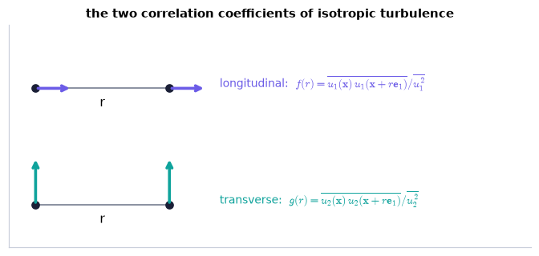

```python
fig, ax = plt.subplots(figsize=(6.0, 2.8))   # a new figure and its panel(s); figsize in inches
fg_geometry_sketch(ax)                                        # drawing: the longitudinal (f) and transverse (g) arrangements
plt.show()   # display the figure
```

**What you see.** Two pairs of points a distance $r$ apart. In one pair the velocity components point along the separation (longitudinal, $f$); in the other they point across it (transverse, $g$).

**How to read it.** In isotropic turbulence every two-point velocity correlation is a combination of these two functions of the distance $r$ alone — direction does not matter.

**What would change if…** …the turbulence were sheared (C04): the correlation would also depend on the *direction* of the separation, and two functions would not be enough.

> 🔁 **Tools from earlier chapters used in this block** (one line each; the full primers are in the chapters named)
- **isotropic tensors (built from δ_ij and a vector)** — a tensor with no preferred direction can only be built from $\delta_{ij}$ — and, if one vector $\mathbf r$ is given, from $r_ir_j$ as well, with coefficients that depend on the length $r$ alone. *(Ch. 4, P119)*
- **integration by parts** — the product rule (ab)′ = a′b + ab′ integrated: ∫a b′ = [ab] − ∫a′b moves a derivative to the other factor at the price of a boundary term. *(Ch. 9, P218a)*
- **np.gradient** — central differences inside, one-sided at the ends; use `edge_order=2` for second order at the edges. *(Ch. 1, P22)*

📝 **Note.** **N63 [B]** **Isotropy seen in a scatter plot.** A round cloud of $(u,v)$ means $\overline{uv}=0$ — no shear stress; a cloud stretched along $v=-u$ means $\overline{uv}<0$ (the fourth panel of the figure in C02, and the parcels of C04).

📝 **Note.** **N64 [B]** **What homogeneity and isotropy say about single-point moments**: no moment changes from place to place, $\frac{\partial}{\partial x_i}\overline{u_j^n}=0$; the three normal stresses are equal, $\overline{u_1^2}=\overline{u_2^2}=\overline{u_3^2}$; and so are the moments of the three *longitudinal* gradients.

$$ \overline{(\partial u_1/\partial x_1)^n}=\overline{(\partial u_2/\partial x_2)^n}=\overline{(\partial u_3/\partial x_3)^n} \qquad \text{(12.36)} $$

📝 **Note.** **N65 [B]** **The six cross (transverse) gradient moments are equal as well.**

$$ \overline{(\partial u_1/\partial x_2)^n}=\overline{(\partial u_1/\partial x_3)^n}=\dots=\overline{(\partial u_3/\partial x_2)^n} \qquad \text{(12.37)} $$

```python
n3 = 48 if FAST else 64                                       # grid points per side of a periodic cube
L3 = 2*np.pi                                                  # box size [m] (so the wavenumbers are the integers 1, 2, …)
E3_raw = lambda K: K**4*np.exp(-2.0*(K/6.0)**2)               # shape of the prescribed energy spectrum (peak at K = 6 rad/m)
E3_norm = quad(E3_raw, 0, np.inf)[0]                          # its integral
E3 = lambda K: 1.5*E3_raw(K)/E3_norm                          # ∫E dK = 1.5 m²/s² = turbulent kinetic energy ē → each component has variance 1
u3, v3, w3 = TS.synthetic_solenoidal_field(n3, L3, spectrum=E3, seed=0, dim=3)   # a divergence-free 3-D field (kinematic — no cascade)
dx3 = L3/n3                                                   # grid spacing [m]
rep = ch12.isotropy_report(u3, v3, w3, dx3)                   # single-point checks of Eqs. (12.36)–(12.37)
print("normal-stress ratios u_i²/mean:", np.round(rep["normal_stress_ratios"], 3))
print("shear correlation coefficients:", {k: round(float(v), 4) for k, v in rep["shear_coefficients"].items()})
print("mean square of the 3 longitudinal gradients:", np.round(rep["longitudinal"], 2), "\n   and of the 6 transverse ones:", np.round(rep["transverse"], 2))
K_sh, E_sh = TS.shell_spectrum((u3, v3, w3), L3)              # energy per unit wavenumber, measured from the field
print(f"sum of the measured spectrum {np.sum(E_sh)*(K_sh[1] - K_sh[0]):.4f} = ½ mean(u_i u_i) = {0.5*np.mean(u3**2 + v3**2 + w3**2):.4f} m²/s²")
smp = np.random.default_rng(0).normal(size=(100_000, 3))     # 100 000 samples of three independent unit-variance components
print(f"turbulent kinetic energy of unit-variance samples: {TS.turbulent_kinetic_energy(smp):.3f} = 3/2 × 1")
```

```
normal-stress ratios u_i²/mean: [1.    1.008 0.992]
shear correlation coefficients: {'r_12': -0.005, 'r_13': 0.0088, 'r_23': 0.0139}
mean square of the 3 longitudinal gradients: [9.13 8.99 8.8 ]
   and of the 6 transverse ones: [17.95 18.35 17.9  18.07 18.14 17.64]
sum of the measured spectrum 1.5074 = ½ mean(u_i u_i) = 1.5074 m²/s²
turbulent kinetic energy of unit-variance samples: 1.503 = 3/2 × 1
```

**What does the code above do?**

1. `TS.synthetic_solenoidal_field(..., dim=3)` builds a random divergence-free field with the spectrum we prescribe (primer P286) — a stand-in for isotropic turbulence that has the right *kinematics* and no dynamics.
2. `ch12.isotropy_report` returns the three normal stresses over their mean (all ≈ 1), the three shear correlation coefficients (all ≈ 0), and the mean squares of the three longitudinal and six transverse gradients: equal within each group, as $\overline{(\partial u_1/\partial x_1)^n}=\overline{(\partial u_2/\partial x_2)^n}=\overline{(\partial u_3/\partial x_3)^n}$ (12.36) and its transverse twin say — and the transverse ones are **twice** the longitudinal ones, which D08 will derive.
3. `TS.shell_spectrum` measures the spectrum back from the field; its sum is half the mean square velocity to round-off: the field has the energy we prescribed.
4. `TS.turbulent_kinetic_energy` of three unit-variance components is $1.5=\tfrac32\overline{u^2}$ (**N72** below).

📝 **Note.** **N66 [B]** **The two correlation coefficients.** $u_\parallel$ is the velocity component along the separation $\mathbf r$, $u_\perp$ a component perpendicular to it; $\overline{u_\parallel^2}=\overline{u_\perp^2}=\overline{u^2}$ and $f(0)=g(0)=1$: $g(r)\equiv\overline{u_\perp(\mathbf x+\mathbf r)u_\perp(\mathbf x)}\big/\overline{u_\perp^2}$ and

$$ f(r)\equiv\overline{u_\parallel(\mathbf x+\mathbf r)u_\parallel(\mathbf x)}\big/\overline{u_\parallel^2} \qquad \text{(12.38)} $$

📝 **Note.** **N67 [B]** **Their integral scales and Taylor microscales** are C02's definitions with the distance $r$ in place of the lag $\tau$.

$$ \Lambda_f\equiv\int_0^\infty f\,dr,\quad\Lambda_g\equiv\int_0^\infty g\,dr,\quad\lambda_f^2\equiv-2/[d^2f/dr^2]_{r=0},\quad\lambda_g^2\equiv-2/[d^2g/dr^2]_{r=0} \qquad \text{(12.39)} $$

📝 **Note.** **N72 [B]** **Energy and the one-component convention.** At zero separation the trace of the correlation tensor is twice the turbulent kinetic energy, $R_{ii}(0)=\overline{u_iu_i}=2\bar e$. ⚠️ In this section $\overline{u^2}$ is **one** component, so $\bar e=\tfrac32\overline{u^2}$; and $\bar e$ is not Ch. 1's internal energy $e$.

> 📎 **Primer — derivatives of functions of r = ∣r∣.** `P297` · The distance is $r=\sqrt{r_kr_k}$ (sum over $k$). Differentiating $r^2=r_kr_k$ gives $\partial r/\partial r_j=r_j/r$. Also $\partial r_i/\partial r_j=\delta_{ij}$, $\delta_{jj}=3$ and $r_jr_j=r^2$. So for any function of the distance alone, the chain rule gives $\partial F(r)/\partial r_j=F'(r)\,r_j/r$.

```python
r1, r2, r3 = sp.symbols("r1 r2 r3", positive=True)            # the three components of the separation
r_len = sp.sqrt(r1**2 + r2**2 + r3**2)                        # its length r
print(sp.simplify(sp.diff(r_len, r1) - r1/r_len))             # 0: ∂r/∂r_1 = r_1/r
print(sum(sp.diff(ri, ri) for ri in (r1, r2, r3)))            # 3: the divergence of the vector r_i is δ_jj = 3
```

```
0
3
```

#### 🧮 Derivation — The isotropic two-point tensor, its incompressible form, $g=f+\tfrac r2f'$, $\Lambda_g=\Lambda_f/2$, $\lambda_g=\lambda_f/\sqrt2$ `D07` ★★★ (Eq. 12.41: $R_{ij}=\overline{u^2}\Big\{f(r)\delta_{ij}+\frac r2\frac{df}{dr}\Big(\delta_{ij}-\frac{r_ir_j}{r^2}\Big)\Big\}$)

**What we want to show.** Show that in isotropic, incompressible turbulence the whole two-point correlation tensor — nine functions of a vector — is fixed by one function f(r).

**Assumptions.** Homogeneous, isotropic (reflection-invariant), incompressible, three-dimensional; f decays faster than 1/r.

**The plan.**

1. Write the most general tensor that isotropy allows.
2. Read its two functions off by pointing **r** along one axis.
3. Impose incompressibility.
4. Integrate and differentiate the result.

**Tools we use** (each explained before this point): isotropic tensors (P119) · derivatives of functions of r (P297, primer above) · $\partial u_i/\partial x_i=0$ (12.28) from D06 · integration by parts (P218a) · Taylor series (P26) · sympy (P40)

**We start from**

$$ \begin{array}{l}R_{ij}(\mathbf r)\equiv\overline{u_i(\mathbf x)u_j(\mathbf x+\mathbf r)}\ \text{(12.23) with the definitions} \\ f(r)\equiv\overline{u_\parallel(\mathbf x+\mathbf r)u_\parallel(\mathbf x)}/\overline{u^2}\ \text{,}\ g(r)\equiv\overline{u_\perp(\mathbf x+\mathbf r)u_\perp(\mathbf x)}/\overline{u^2}\ \text{(12.38).}\end{array} $$

**Step 1 of 14 — Note what R can depend on.**

$$ R_{ij}=R_{ij}(\mathbf r) $$

- *Why we can do this:* Homogeneity: the statistics are the same at every **x**, so only the separation **r** remains: $R_{ij}(\mathbf r)\equiv\overline{u_i(\mathbf x)u_j(\mathbf x+\mathbf r)}$ (12.23).
- *In words:* Only "how far apart and in which direction" matters.

**Step 2 of 14 — Write the most general isotropic form.**

$$ R_{ij}=F_R(r)\,r_ir_j+G_R(r)\,\delta_{ij} $$

- *Why we can do this:* With no preferred direction, a second-order tensor can be built only from $\delta_{ij}$ and the vector **r** itself, with scalar coefficients depending on r = ∣**r**∣; an $\epsilon_{ijk}r_k$ term would change sign under reflection. This is (12.40), $R_{ij}=F(r)r_ir_j+G(r)\delta_{ij}$.
- *In words:* Two unknown functions instead of nine.

**Step 3 of 14 — Point **r** along the 1-axis and take the 11-component.**

$$ \mathbf r=(r,0,0):\quad R_{11}=F_Rr^2+G_R $$

- *Why we can do this:* We are free to choose the axes (isotropy); then $r_1r_1=r^2$ and $\delta_{11}=1$.
- *In words:* The component along the separation.

**Step 4 of 14 — Recognise the longitudinal correlation.**

$$ R_{11}=\overline{u_1(\mathbf x)u_1(\mathbf x+r\mathbf e_1)}=\overline{u^2}\,f(r) $$

- *Why we can do this:* Both velocity components lie along **r**: that is the definition $f(r)\equiv\overline{u_\parallel(\mathbf x+\mathbf r)u_\parallel(\mathbf x)}/\overline{u_\parallel^2}$ (12.38).
- *In words:* Along the line, the tensor is f.

**Step 5 of 14 — Take the 22-component.**

$$ R_{22}=G_R=\overline{u^2}\,g(r) $$

- *Why we can do this:* $r_2=0$, $\delta_{22}=1$; both components are perpendicular to **r**: the definition of g.
- *In words:* Across the line, the tensor is g.

**Step 6 of 14 — Solve for the two functions.**

$$ G_R=\overline{u^2}\,g,\qquad F_R=\overline{u^2}\,\dfrac{f-g}{r^2} $$

- *Why we can do this:* Subtract step 5 from steps 3–4 and divide by r². These are the F and G the book quotes after $R_{ij}=F(r)r_ir_j+G(r)\delta_{ij}$ (12.40).
- *In words:* The tensor is known once f and g are.

**Step 7 of 14 — Impose incompressibility at the second point.**

$$ \dfrac{\partial R_{ij}}{\partial r_j}=\overline{u_i(\mathbf x)\,\dfrac{\partial u_j}{\partial x_j}(\mathbf x+\mathbf r)}=0 $$

- *Why we can do this:* Differentiating with respect to **r** acts only on the second factor (D01's $\overline{\partial u^m/\partial x_j}=\partial\overline{u^m}/\partial x_j$ (12.8)), and $\partial u_j/\partial x_j=0$ (12.28).
- *In words:* The tensor is divergence-free in **r**.

**Step 8 of 14 — Differentiate the first part.**

$$ \dfrac{\partial}{\partial r_j}\big(F_Rr_ir_j\big)=F_R'\dfrac{r_j}{r}r_ir_j+F_R\big(\delta_{ij}r_j+r_i\delta_{jj}\big)=\big(rF_R'+4F_R\big)r_i $$

- *Why we can do this:* Product rule with $\partial r/\partial r_j=r_j/r$, $\partial r_i/\partial r_j=\delta_{ij}$, $r_jr_j=r^2$, $\delta_{jj}=3$ (P297).
- *In words:* The divergence of the $r_ir_j$ part points along **r**.

**Step 9 of 14 — Differentiate the second part.**

$$ \dfrac{\partial}{\partial r_j}\big(G_R\delta_{ij}\big)=G_R'\dfrac{r_i}{r} $$

- *Why we can do this:* Chain rule; $\delta_{ij}$ picks out j = i.
- *In words:* So does the divergence of the $\delta_{ij}$ part.

**Step 10 of 14 — Add them and remove the common factor.**

$$ rF_R'+4F_R+\dfrac{G_R'}{r}=0 $$

- *Why we can do this:* Step 7 must hold for every **r**, so the coefficient of $r_i$ vanishes.
- *In words:* One ordinary differential equation links F and G.

**Step 11 of 14 — Substitute step 6.**

$$ \dfrac{f'}{r}+\dfrac{2(f-g)}{r^2}=0\ \Rightarrow\ g=f+\dfrac r2\dfrac{df}{dr} $$

- *Why we can do this:* $rF_R'=\overline{u^2}\big[(f'-g')/r-2(f-g)/r^2\big]$; the g′ terms cancel and $-2+4=2$.
- *In words:* The transverse correlation is fixed by the longitudinal one.

**Step 12 of 14 — Put g back into the tensor.**

$$ R_{ij}=\overline{u^2}\Big\{f\,\delta_{ij}+\dfrac r2\dfrac{df}{dr}\Big(\delta_{ij}-\dfrac{r_ir_j}{r^2}\Big)\Big\} $$

- *Why we can do this:* $F_R=\overline{u^2}(f-g)/r^2=-\overline{u^2}f'/(2r)$ and $G_R=\overline{u^2}(f+rf'/2)$ in step 2. This is (12.41), $R_{ij}=\overline{u^2}\Big\{f(r)\delta_{ij}+\frac r2\frac{df}{dr}\Big(\delta_{ij}-\frac{r_ir_j}{r^2}\Big)\Big\}$.
- *In words:* One function f(r) gives all nine components.

**Step 13 of 14 — Integrate g over all r.**

$$ \Lambda_g=\displaystyle\int_0^\infty\Big(f+\dfrac r2f'\Big)dr=\Lambda_f+\Big[\dfrac{rf}{2}\Big]_0^\infty-\dfrac12\int_0^\infty f\,dr=\dfrac{\Lambda_f}{2} $$

- *Why we can do this:* Integration by parts on the second term (P218a); the boundary term vanishes because f decays faster than 1/r. Definitions (12.39), $\Lambda_f\equiv\int_0^\infty f(r)\,dr,\ \Lambda_g\equiv\int_0^\infty g(r)\,dr,\ \lambda_f^2\equiv-2/[d^2f/dr^2]_{r=0},\ \lambda_g^2\equiv-2/[d^2g/dr^2]_{r=0}$.
- *In words:* The transverse integral scale is half the longitudinal one.

**Step 14 of 14 — Differentiate g twice at r = 0.**

$$ g''=2f''+\dfrac r2f'''\ \Rightarrow\ g''(0)=2f''(0)\ \Rightarrow\ \lambda_g=\dfrac{\lambda_f}{\sqrt2} $$

- *Why we can do this:* $g'=\tfrac32f'+\tfrac r2f''$, then once more; $\lambda^2\equiv-2/[\text{second derivative at }0]$ (12.39).
- *In words:* The transverse correlation is twice as sharply curved at its top.

**Result**

$$ R_{ij}=\overline{u^2}\{f\delta_{ij}+\frac r2f'(\delta_{ij}-r_ir_j/r^2)\}\ \text{(12.41);}\ g=f+\frac r2f'\ \text{;}\ \Lambda_g=\Lambda_f/2\ \text{;}\ \lambda_g=\lambda_f/\sqrt2 $$

*In words:* Isotropy and incompressibility leave one free function

**What it means.** Measure f with one probe towed along a line and you know every two-point correlation; g must go negative somewhere (fluid crossing a line has to come back). **Fails when:** the turbulence is anisotropic (shear, walls, stratification) or two-dimensional (there $g=d(rf)/dr$ and the factors change).

**Check it.** Units — $R_{ij}$ in m²/s². r → 0: f = g = 1, $R_{ij}=\overline{u^2}\delta_{ij}$ ✓ (equal normal stresses, no shear stress). Trace: $R_{ii}=\overline{u^2}(3f+rf')$, at r = 0 it is $3\overline{u^2}=2\bar e$ ✓. Gaussian $f=e^{-r^2/L^2}$: $g=(1-r^2/L^2)e^{-r^2/L^2}$ — negative beyond r = L, $\Lambda_g=\tfrac{\sqrt\pi}4L=\Lambda_f/2$ ✓.

```python
import sympy as sp                                             # symbolic algebra
r1, r2, r3, u2, s = sp.symbols("r1 r2 r3 u2 s", positive=True) # separation components, one-component variance, and the distance s = |r|
rv = [r1, r2, r3]                                              # the separation vector
f = sp.Function("f")(s)                                        # the longitudinal correlation, left completely general
g = f + s/2*sp.diff(f, s)                                      # step 11: g = f + (r/2) f'
R = sp.Matrix(3, 3, lambda i, j: u2*((f - g)/s**2*rv[i]*rv[j] + g*sp.KroneckerDelta(i, j)))   # steps 2 and 6: F r_i r_j + G δ_ij, with F, G from f, g
# step 7: the divergence ∂R_ij/∂r_j. R depends on r_j directly AND through the distance s, with ∂s/∂r_j = r_j/s (primer P297)
div = [sum(sp.diff(R[i, j], rv[j]) + sp.diff(R[i, j], s)*rv[j]/s for j in range(3)) for i in range(3)]
div = [sp.simplify(d.subs(r1**2 + r2**2 + r3**2, s**2).subs(r3, sp.sqrt(s**2 - r1**2 - r2**2))) for d in div]   # use s² = r_k r_k
print("divergence of the tensor for ANY f:", div)              # [0, 0, 0]
assert div == [0, 0, 0]                                        # the incompressible tensor of step 12 is divergence-free
gfree = sp.Function("g")(s)                                    # the converse (steps 8–11): leave g FREE and ask what zero divergence demands
Rfree = sp.Matrix(3, 3, lambda i, j: u2*((f - gfree)/s**2*rv[i]*rv[j] + gfree*sp.KroneckerDelta(i, j)))   # the tensor of step 6 with an unknown g
div1 = sum(sp.diff(Rfree[0, j], rv[j]) + sp.diff(Rfree[0, j], s)*rv[j]/s for j in range(3))               # its divergence, first component
bracket = sp.simplify((div1.subs(r3, sp.sqrt(s**2 - r1**2 - r2**2))/(u2*r1)).expand())                   # divide out the common factor u² r_1 (step 10)
print("divergence / (u² r_1) =", bracket)                      # f'/s + 2(f − g)/s²
g_solved = sp.solve(sp.Eq(bracket, 0), gfree)[0]               # step 11: the g that makes it vanish
assert sp.simplify(g_solved - g) == 0                          # exactly g = f + (r/2) f'
print("zero divergence forces g =", g_solved)
L = sp.symbols("L", positive=True); fG = sp.exp(-s**2/L**2)    # a Gaussian f to test steps 13 and 14
gG = fG + s/2*sp.diff(fG, s)                                   # its transverse partner
assert sp.simplify(sp.integrate(gG, (s, 0, sp.oo)) - sp.integrate(fG, (s, 0, sp.oo))/2) == 0   # step 13: Λ_g = Λ_f/2
assert sp.simplify(sp.diff(gG, s, 2).subs(s, 0) - 2*sp.diff(fG, s, 2).subs(s, 0)) == 0         # step 14: g''(0) = 2 f''(0), so λ_g = λ_f/√2
print("Gaussian f: Λ_g = Λ_f/2 and g''(0) = 2 f''(0) confirmed")
```

```
divergence of the tensor for ANY f: [0, 0, 0]
divergence / (u² r_1) = (s*Derivative(f(s), s) + 2*f(s) - 2*g(s))/s**2
zero divergence forces g = s*Derivative(f(s), s)/2 + f(s)
```

```
Gaussian f: Λ_g = Λ_f/2 and g''(0) = 2 f''(0) confirmed
```

📝 **Notes taught inside `D07`:** **N68 [B]** the most general isotropic two-point tensor, $R_{ij}=F(r)r_ir_j+G(r)\delta_{ij}$ (12.40) (steps 1–2) · **N69 [B]** its incompressible form $R_{ij}=\overline{u^2}\big\{f\delta_{ij}+\frac r2\frac{df}{dr}\big(\delta_{ij}-\frac{r_ir_j}{r^2}\big)\big\}$ (12.41) (step 12) · **N70 [B]** $g=f+\frac r2f'$, $\Lambda_g=\Lambda_f/2$, $\lambda_g=\lambda_f/\sqrt2$ — ⚠️ three-dimensional results (steps 11, 13, 14).

> ⚠️ **slip #14 — the book prints** (in its Exercise 12.18a) a reference to the scale definitions $\Lambda_f\equiv\int_0^\infty f\,dr,\ \dots,\ \lambda_g^2\equiv-2/[d^2g/dr^2]_{r=0}$ (12.39) as the starting tensor **; the correct form is** the general isotropic tensor $R_{ij}=F(r)r_ir_j+G(r)\delta_{ij}$ (12.40), from which this derivation starts.

> ⚠️ **Common confusion (traps in `D07`):** Using $\delta_{jj}=1$ (it is 3); forgetting $\partial r/\partial r_j=r_j/r$; quoting the scale definitions $\Lambda_f\equiv\int_0^\infty f(r)\,dr$, $\lambda_f^2\equiv-2/[d^2f/dr^2]_{r=0}$ (12.39) for the tensor as Exercise 12.18 does (slip #14: the tensor is $R_{ij}=F(r)r_ir_j+G(r)\delta_{ij}$ (12.40)); confusing these F, G with the jet profiles of $U=U_{CL}(x)F(y/\delta(x))$ (12.56) and $-\overline{uv}=\Psi(x)G(y/\delta(x))$ (12.57).

```python
Rt = ch12.isotropic_correlation_tensor(np.array([0.5, 0.0, 0.0]), lambda r: np.exp(-r**2))   # Eq. (12.41) for f = exp(−r²), separation 0.5 m along x
print(np.round(Rt, 4))                                        # diag(f, g, g) = diag(0.7788, 0.5841, 0.5841), off-diagonals 0
dv = ch12.isotropic_tensor_divergence_sympy()                 # sympy: the divergence ∂R_ij/∂r_j of Eq. (12.41) for a general f
print("divergence:", dv["divergence"], "| check:", dv["check"])
```

```
[[0.7788 0.     0.    ]
 [0.     0.5841 0.    ]
 [0.     0.     0.5841]]
```

```
divergence: [0, 0, 0] | check: True
```

**What does the code above do?**

1. `ch12.isotropic_correlation_tensor(rvec, f)` evaluates the incompressible isotropic tensor: for a separation along $x$, $R_{11}=f(0.5)=e^{-0.25}=0.7788$ and $R_{22}=R_{33}=g(0.5)=(1-r^2)e^{-r^2}=0.5841$.
2. `ch12.isotropic_tensor_divergence_sympy()` confirms that the tensor is divergence-free for **any** $f$ — the content of step 7 of the derivation.

```
Lambda_g/Lambda_f = 0.488 (theory 0.5);  stopping at the first zero of g would give 0.603
```

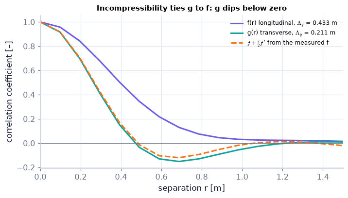

```python
r_fg, f_meas, g_meas = TS.longitudinal_transverse_correlation(u3, v3, dx3, w3)   # f(r) and g(r) measured from the 3-D field, Eq. (12.38)
g_pred = ch12.transverse_from_longitudinal(r_fg, f_meas)      # g = f + (r/2) f' computed from the measured f (D07 step 11)
Lam_f = TS.integral_scale(r_fg, f_meas, upto="all")           # Λ_f = ∫ f dr over the whole range
Lam_g = TS.integral_scale(r_fg, g_meas, upto="all")           # Λ_g = ∫ g dr over the WHOLE range: g has a negative lobe that must be counted
fig, ax = plt.subplots(figsize=(6.4, 3.6))   # a new figure and its panel(s); figsize in inches
ax.plot(r_fg, f_meas, color=C_MEAN, label=f"f(r) longitudinal, $\\Lambda_f$ = {Lam_f:.3f} m")
ax.plot(r_fg, g_meas, color=C_FLUC, label=f"g(r) transverse, $\\Lambda_g$ = {Lam_g:.3f} m")
ax.plot(r_fg, g_pred, "--", color=C_RS, label="$f+\\frac{r}{2}f'$ from the measured f")
ax.axhline(0, color=C_REF, lw=0.6)   # a thin reference line
ax.set(xlabel="separation r [m]", ylabel="correlation coefficient [–]", xlim=(0, 1.5), title="Incompressibility ties g to f: g dips below zero")   # axis labels (with units), title and fixed ranges of this panel
ax.legend(fontsize=8)   # the legend names every curve
print(f"Lambda_g/Lambda_f = {Lam_g/Lam_f:.3f} (theory 0.5);  stopping at the first zero of g would give {TS.integral_scale(r_fg, g_meas)/Lam_f:.3f}")
```

**What you see.** A purple curve $f$ that falls from 1 to 0 without going negative; a teal curve $g$ that falls faster, dips below zero and returns; an orange dashed curve — $g$ predicted from $f$ alone — lying on the teal one through the dip (the prediction differentiates the measured $f$ on its 0.1 m grid, so it is a little rough, and at larger separations, where both are small, it wanders by a few hundredths).

**How to read it.** Fluid that crosses the line joining the two points must come back somewhere (mass conservation), so the transverse correlation needs a negative lobe — large enough that its integral is exactly half of $f$'s. That is why we integrate $g$ over the **whole** range (`upto="all"`): stopping at the first zero would leave the negative lobe out and overestimate $\Lambda_g$.

**What would change if…** …the field were two-dimensional: the relation would be $g=f+rf'$ instead (no factor ½), and $\Lambda_g$ would be zero. The factor ½ and the results $\Lambda_g=\Lambda_f/2$, $\lambda_g=\lambda_f/\sqrt2$ are three-dimensional.

📝 **Note.** **N73 [B]** **The dissipation rate of turbulent kinetic energy** is the average of Ch. 4's $\varepsilon=2\nu S_{ij}S_{ij}$ (4.58) for the fluctuating strain rate $S'_{ij}=\tfrac12(\partial u_i/\partial x_j+\partial u_j/\partial x_i)$: a sum of nine squared gradients (`ch12.dissipation_rate`).

$$ \bar\varepsilon=2\nu\overline{S'_{ij}S'_{ij}}=\frac\nu2\overline{\Big(\frac{\partial u_i}{\partial x_j}+\frac{\partial u_j}{\partial x_i}\Big)^2} \qquad \text{(12.42)} $$

#### 🧮 Derivation — The isotropic dissipation: moments 2: 4: −1 and $\bar\varepsilon=30\nu\overline{u^2}/\lambda_f^2=15\nu\overline{u^2}/\lambda_g^2=15\nu\overline{(\partial u_1/\partial x_1)^2}$ `D08` ★★★ (Eq. 12.43: $\bar\varepsilon=6\nu\Big\{\overline{\Big(\frac{\partial u_1}{\partial x_1}\Big)^2}+\overline{\Big(\frac{\partial u_1}{\partial x_2}\Big)^2}+\overline{\Big(\frac{\partial u_1}{\partial x_2}\Big)\Big(\frac{\partial u_2}{\partial x_1}\Big)}\Big\}=-15\nu\overline{u^2}\Big[\frac{d^2f}{dr^2}\Big]_{r=0}=30\nu\frac{\overline{u^2}}{\lambda_f^2}=15\nu\frac{\overline{u^2}}{\lambda_g^2},\ \dots$)

**What we want to show.** Reduce the dissipation rate — an average over nine velocity gradients — to one measurable number.

**Assumptions.** Homogeneous, isotropic, incompressible, three-dimensional.

**The plan.**

1. Expand the square and count equal terms using isotropy.
2. Express gradient moments through the correlation tensor.
3. Expand f near r = 0.
4. Read off the three moments and add.

**Tools we use** (each explained before this point): summation convention (ch02) · the isotropy statements $\overline{(\partial u_1/\partial x_1)^n}=\overline{(\partial u_2/\partial x_2)^n}=\overline{(\partial u_3/\partial x_3)^n}$ (12.36) and $\overline{(\partial u_1/\partial x_2)^n}=\overline{(\partial u_1/\partial x_3)^n}=\dots=\overline{(\partial u_3/\partial x_2)^n}$ (12.37) · D07's $R_{ij}=\overline{u^2}\{f\delta_{ij}+\frac r2f'(\delta_{ij}-r_ir_j/r^2)\}$ (12.41) · Taylor expansion (P26) · P297 · sympy (P40)

**We start from**

$$ \bar\varepsilon=\dfrac\nu2\,\overline{\Big(\dfrac{\partial u_i}{\partial x_j}+\dfrac{\partial u_j}{\partial x_i}\Big)^2}\ \text{(12.42).} $$

**Step 1 of 13 — Expand the square.**

$$ \Big(\dfrac{\partial u_i}{\partial x_j}+\dfrac{\partial u_j}{\partial x_i}\Big)^2=2\dfrac{\partial u_i}{\partial x_j}\dfrac{\partial u_i}{\partial x_j}+2\dfrac{\partial u_i}{\partial x_j}\dfrac{\partial u_j}{\partial x_i} $$

- *Why we can do this:* $(a+b)^2=a^2+2ab+b^2$; summed over i and j, the two squares are the same sum (rename i ↔ j).
- *In words:* Two kinds of double sum.

**Step 2 of 13 — Average.**

$$ \bar\varepsilon=\nu\Big[\,\overline{\dfrac{\partial u_i}{\partial x_j}\dfrac{\partial u_i}{\partial x_j}}+\overline{\dfrac{\partial u_i}{\partial x_j}\dfrac{\partial u_j}{\partial x_i}}\,\Big] $$

- *Why we can do this:* D01's linearity; the factor ½ of $\bar\varepsilon=\frac\nu2\overline{(\partial u_i/\partial x_j+\partial u_j/\partial x_i)^2}$ (12.42) cancels the 2.
- *In words:* The dissipation is ν times two sums of nine gradient moments each.

**Step 3 of 13 — Count the first sum.**

$$ \overline{\dfrac{\partial u_i}{\partial x_j}\dfrac{\partial u_i}{\partial x_j}}=3a+6b,\quad a\equiv\overline{\Big(\dfrac{\partial u_1}{\partial x_1}\Big)^2},\ b\equiv\overline{\Big(\dfrac{\partial u_1}{\partial x_2}\Big)^2} $$

- *Why we can do this:* Three terms have i = j; by (12.36), $\overline{(\partial u_1/\partial x_1)^n}=\overline{(\partial u_2/\partial x_2)^n}=\overline{(\partial u_3/\partial x_3)^n}$, they are equal. Six have i ≠ j and are equal by (12.37), $\overline{(\partial u_1/\partial x_2)^n}=\overline{(\partial u_1/\partial x_3)^n}=\overline{(\partial u_2/\partial x_1)^n}=\overline{(\partial u_2/\partial x_3)^n}=\overline{(\partial u_3/\partial x_1)^n}=\overline{(\partial u_3/\partial x_2)^n}$.
- *In words:* Three "along" moments and six "across" moments.

**Step 4 of 13 — Count the second sum.**

$$ \overline{\dfrac{\partial u_i}{\partial x_j}\dfrac{\partial u_j}{\partial x_i}}=3a+6c,\quad c\equiv\overline{\dfrac{\partial u_1}{\partial x_2}\dfrac{\partial u_2}{\partial x_1}} $$

- *Why we can do this:* For i = j the product is again a square (a); the six i ≠ j terms are all equal to c by isotropy.
- *In words:* The cross sum brings a third kind of moment.

**Step 5 of 13 — Add.**

$$ \bar\varepsilon=\nu(6a+6b+6c)=6\nu\Big\{\overline{\Big(\dfrac{\partial u_1}{\partial x_1}\Big)^2}+\overline{\Big(\dfrac{\partial u_1}{\partial x_2}\Big)^2}+\overline{\dfrac{\partial u_1}{\partial x_2}\dfrac{\partial u_2}{\partial x_1}}\Big\} $$

- *Why we can do this:* Steps 2–4. This is the first equality of (12.43), $\bar\varepsilon=6\nu\Big\{\overline{\Big(\frac{\partial u_1}{\partial x_1}\Big)^2}+\overline{\Big(\frac{\partial u_1}{\partial x_2}\Big)^2}+\overline{\Big(\frac{\partial u_1}{\partial x_2}\Big)\Big(\frac{\partial u_2}{\partial x_1}\Big)}\Big\}=-15\nu\overline{u^2}\Big[\frac{d^2f}{dr^2}\Big]_{r=0}=30\nu\frac{\overline{u^2}}{\lambda_f^2}=15\nu\frac{\overline{u^2}}{\lambda_g^2}$.
- *In words:* Three different moments — not three equal ones.

**Step 6 of 13 — Differentiate the correlation once in **r**.**

$$ \dfrac{\partial R_{ij}}{\partial r_l}=\overline{u_i(\mathbf x)\,\dfrac{\partial u_j}{\partial x_l}(\mathbf x+\mathbf r)} $$

- *Why we can do this:* **r** appears only in the second factor; the derivative passes through the average (D01's $\overline{\partial u^m/\partial x_j}=\partial\overline{u^m}/\partial x_j$ (12.8)).
- *In words:* One derivative lands on the second velocity.

**Step 7 of 13 — Shift the origin, differentiate again, set r = 0.**

$$ \dfrac{\partial^2R_{ij}}{\partial r_k\partial r_l}\Big|_{r=0}=-\overline{\dfrac{\partial u_i}{\partial x_k}\dfrac{\partial u_j}{\partial x_l}} $$

- *Why we can do this:* By homogeneity $\overline{u_i(\mathbf x)\partial_lu_j(\mathbf x+\mathbf r)}=\overline{u_i(\mathbf x'-\mathbf r)\partial_lu_j(\mathbf x')}$; now **r** sits in the first factor with a minus sign.
- *In words:* Gradient moments are (minus) the curvature of the correlation at zero separation.

**Step 8 of 13 — Expand f near r = 0.**

$$ f\approx1-\dfrac{r^2}{\lambda_f^2},\qquad\dfrac r2\dfrac{df}{dr}\approx-\dfrac{r^2}{\lambda_f^2} $$

- *Why we can do this:* Taylor series of an even function with $\lambda_f^2\equiv-2/f''(0)$ (12.39), exactly as in D04; ≈ because only second derivatives at 0 are needed.
- *In words:* Near zero separation f is a parabola.

**Step 9 of 13 — Insert into the isotropic tensor.**

$$ R_{ij}\approx\overline{u^2}\Big[\delta_{ij}-\dfrac{2r^2}{\lambda_f^2}\delta_{ij}+\dfrac{r_ir_j}{\lambda_f^2}\Big] $$

- *Why we can do this:* (12.41), $R_{ij}=\overline{u^2}\{f\delta_{ij}+\frac r2f'(\delta_{ij}-r_ir_j/r^2)\}$, with step 8: $-r^2/\lambda_f^2-r^2/\lambda_f^2=-2r^2/\lambda_f^2$.
- *In words:* Near the origin the tensor is quadratic in **r**.

**Step 10 of 13 — Differentiate twice.**

$$ -\dfrac{\partial^2R_{ij}}{\partial r_k\partial r_l}=\dfrac{\overline{u^2}}{\lambda_f^2}\big[4\delta_{ij}\delta_{kl}-\delta_{ik}\delta_{jl}-\delta_{il}\delta_{jk}\big] $$

- *Why we can do this:* $\partial^2(r^2)/\partial r_k\partial r_l=2\delta_{kl}$ and $\partial^2(r_ir_j)/\partial r_k\partial r_l=\delta_{ik}\delta_{jl}+\delta_{il}\delta_{jk}$ (P297).
- *In words:* Every gradient moment, in one formula.

**Step 11 of 13 — Read off the three moments.**

$$ a=\dfrac{2\overline{u^2}}{\lambda_f^2},\qquad b=\dfrac{4\overline{u^2}}{\lambda_f^2},\qquad c=-\dfrac{\overline{u^2}}{\lambda_f^2} $$

- *Why we can do this:* a: i = j = k = l = 1 gives 4 − 1 − 1; b: i = j = 1, k = l = 2 gives 4; c: i = 1, k = 2, j = 2, l = 1 gives −1.
- *In words:* The moments are in the ratio 2 : 4 : −1.

**Step 12 of 13 — Add them.**

$$ \bar\varepsilon=6\nu\,(2+4-1)\dfrac{\overline{u^2}}{\lambda_f^2}=30\nu\dfrac{\overline{u^2}}{\lambda_f^2}=-15\nu\,\overline{u^2}\Big[\dfrac{d^2f}{dr^2}\Big]_{r=0} $$

- *Why we can do this:* Step 5 with step 11; $1/\lambda_f^2=-f''(0)/2$. The middle equalities of (12.43), $\bar\varepsilon=6\nu\Big\{\overline{\Big(\frac{\partial u_1}{\partial x_1}\Big)^2}+\overline{\Big(\frac{\partial u_1}{\partial x_2}\Big)^2}+\overline{\Big(\frac{\partial u_1}{\partial x_2}\Big)\Big(\frac{\partial u_2}{\partial x_1}\Big)}\Big\}=-15\nu\overline{u^2}\Big[\frac{d^2f}{dr^2}\Big]_{r=0}=30\nu\frac{\overline{u^2}}{\lambda_f^2}=15\nu\frac{\overline{u^2}}{\lambda_g^2}$.
- *In words:* The dissipation is fixed by the curvature of f at the origin.

**Step 13 of 13 — Rewrite with the transverse microscale and with one gradient.**

$$ \bar\varepsilon=15\nu\dfrac{\overline{u^2}}{\lambda_g^2}=15\nu\,\overline{\Big(\dfrac{\partial u_1}{\partial x_1}\Big)^2} $$

- *Why we can do this:* $\lambda_g^2=\lambda_f^2/2$ (D07 step 14); and $a=2\overline{u^2}/\lambda_f^2$ from step 11. The first form is the last member of (12.43), $\bar\varepsilon=6\nu\Big\{\overline{\Big(\frac{\partial u_1}{\partial x_1}\Big)^2}+\overline{\Big(\frac{\partial u_1}{\partial x_2}\Big)^2}+\overline{\Big(\frac{\partial u_1}{\partial x_2}\Big)\Big(\frac{\partial u_2}{\partial x_1}\Big)}\Big\}=-15\nu\overline{u^2}\Big[\frac{d^2f}{dr^2}\Big]_{r=0}=30\nu\frac{\overline{u^2}}{\lambda_f^2}=15\nu\frac{\overline{u^2}}{\lambda_g^2}$; the one-gradient form $15\nu\overline{(\partial u_1/\partial x_1)^2}$ is ours (a corollary of step 11, not part of the book's numbered equation).
- *In words:* One velocity gradient, measured along a line, gives the whole dissipation.

**Result**

$$ \bar\varepsilon=6\nu\{a+b+c\}=-15\nu\overline{u^2}f''(0)=30\nu\overline{u^2}/\lambda_f^2=15\nu\overline{u^2}/\lambda_g^2\ \text{(12.43)} $$

*In words:* Symmetry turns nine gradients into one

**What it means.** Oceanographers measure $\overline{(\partial u_1/\partial x_1)^2}$ with a shear probe and multiply by 15ν (or 7.5ν for a transverse gradient) to get ε̄. **Fails when:** the small scales are not isotropic (low Reynolds number, strong stratification), or in two dimensions (the factor is not 15).

**Check it.** Units — ν [m²/s] × [m²/s²]/[m²] = m²/s³ ✓. Consistency: in homogeneous incompressible turbulence the cross sum $\overline{\partial_ju_i\,\partial_iu_j}=3a+6c$ must vanish (it is a double divergence): 3 × 2 + 6 × (−1) = 0 ✓ — so also $\bar\varepsilon=\nu\overline{(\partial_ju_i)^2}$ = ν(3a + 6b) = 30ν$\overline{u^2}/\lambda_f^2$ ✓. Number: ν = 1.5 × 10⁻⁵, $\overline{u^2}$ = 1, λ_f = 0.01 m ⇒ 4.5 m²/s³.

```python
import sympy as sp                                           # symbolic algebra
r1, r2, r3, u2, lam, nu = sp.symbols("r1 r2 r3 u2 lambda_f nu", positive=True)   # separation components, one-component variance, λ_f, viscosity
rv = [r1, r2, r3]; rr = r1**2 + r2**2 + r3**2                # separation and its square
d = sp.KroneckerDelta                                        # delta_ij
R = lambda i, j: u2*(d(i, j) - 2*rr/lam**2*d(i, j) + rv[i]*rv[j]/lam**2)   # step 9
M = lambda i, k, j, l: -sp.diff(R(i, j), rv[k], rv[l])       # step 7: <d_k u_i d_l u_j> = -d2R_ij/dr_k dr_l
a, b, c = M(0, 0, 0, 0), M(0, 1, 0, 1), M(0, 1, 1, 0)        # the three moments of step 3 and 4
assert [sp.simplify(x*lam**2/u2) for x in (a, b, c)] == [2, 4, -1]          # step 11
eps = nu*sum(M(i, j, i, j) + M(i, j, j, i) for i in range(3) for j in range(3))   # step 2, all 18 terms
assert sp.simplify(eps - 30*nu*u2/lam**2) == 0               # step 12
assert sp.simplify(sum(M(i, j, j, i) for i in range(3) for j in range(3))) == 0   # the cross sum vanishes
print("D08 check — moments × λ_f²/u² (longitudinal, transverse, cross):", [sp.simplify(m_*lam**2/u2) for m_ in (a, b, c)])   # 2, 4, −1
print("D08 check — ε̄ λ_f²/(ν u²) from all 18 terms:", sp.simplify(eps*lam**2/(nu*u2)), "| cross sum:", sp.simplify(sum(M(i, j, j, i) for i in range(3) for j in range(3))))   # 30 and 0
```

```
D08 check — moments × λ_f²/u² (longitudinal, transverse, cross): [2, 4, -1]
D08 check — ε̄ λ_f²/(ν u²) from all 18 terms: 30 | cross sum: 0
```

📝 **Notes taught inside `D08`:** **N74 [B]** gradient correlations are curvatures of the two-point tensor at zero separation, $\overline{\frac{\partial u_i}{\partial x_k}\frac{\partial u_j}{\partial x_l}}=-\big(\frac{\partial^2R_{ij}}{\partial r_k\partial r_l}\big)_{r=0}$, (steps 6–7), and the three kinds of moment stand in the ratio 2 : 4 : −1 (step 11).

> ⚠️ **Common confusion (traps in `D08`):** Assuming the three moments in the bracket of $\bar\varepsilon=6\nu\big\{\overline{(\partial u_1/\partial x_1)^2}+\overline{(\partial u_1/\partial x_2)^2}+\overline{(\partial u_1/\partial x_2)(\partial u_2/\partial x_1)}\big\}$ (12.43) are equal; losing the minus sign in step 7; mixing λ_f and λ_g (a factor 2 in ε̄); using the total variance $2\bar e$ where $\overline{u^2}$ is one component.

#### ✏️ Tiny example: dissipation from a Taylor microscale

Air, $\nu=1.5\times10^{-5}$ m²/s; $\overline{u^2}=1$ m²/s² (one component); $\lambda_f=1$ cm.

1. $\bar\varepsilon=30\nu\overline{u^2}/\lambda_f^2=30\times1.5\times10^{-5}\times1/10^{-4}=4.5$ m²/s³.
2. $\lambda_g=\lambda_f/\sqrt2=7.07$ mm; $15\times1.5\times10^{-5}/(5\times10^{-5})=4.5$ ✓.
3. One gradient: $\overline{(\partial u_1/\partial x_1)^2}=2\overline{u^2}/\lambda_f^2=2\times10^4$ s⁻²; $15\nu\times2\times10^4=4.5$ ✓.
4. $R_\lambda=\lambda_g\sqrt{\overline{u^2}}/\nu=471$.
5. Kolmogorov scale (C07): $\eta=(\nu^3/\bar\varepsilon)^{1/4}=0.165$ mm — 43 times smaller than $\lambda_g$.

```python
nu_air = 1.5e-5                                               # kinematic viscosity of air [m²/s]
e1 = ch12.dissipation_isotropic(nu_air, 1.0, lambda_f=0.01)   # Eq. (12.43): 30 ν u²/λ_f² with u² = 1 m²/s², λ_f = 1 cm
e2 = ch12.dissipation_isotropic(nu_air, 1.0, lambda_g=0.01/np.sqrt(2))   # 15 ν u²/λ_g²
e3 = ch12.dissipation_isotropic(nu_air, dudx_sq=2.0e4)        # 15 ν mean((∂u_1/∂x_1)²): one measurable gradient
print(f"dissipation three ways: {e1:.3f}, {e2:.3f}, {e3:.3f} m²/s³;  R_lambda = {ch12.taylor_reynolds_number(1.0, 0.01/np.sqrt(2), nu_air):.1f}")
mom = ch12.gradient_moments_isotropic_sympy()                 # sympy repeats D08 for a general f
print("moments (longitudinal : transverse : cross) =", mom["m11"], ":", mom["m12"], ":", mom["cross"], "| ε̄ λ_f²/(ν u²) =", mom["eps_factor"])
grads = ch12.velocity_gradient_samples(u3, v3, w3, dx3)       # all nine gradients at every grid node of the synthetic field
eps_full = ch12.dissipation_rate(grads, 1e-3)                 # Eq. (12.42): the full nine-gradient sum (ν = 10⁻³ m²/s)
eps_one = 15*1e-3*np.mean(grads[:, 0, 0]**2)                  # Eq. (12.43): 15 ν mean((∂u_1/∂x_1)²) from ONE gradient
print(f"synthetic field: full sum {eps_full:.4f}, one-gradient formula {eps_one:.4f} m²/s³ (ratio {eps_one/eps_full:.3f})")
```

```
dissipation three ways: 4.500, 4.500, 4.500 m²/s³;  R_lambda = 471.4
```

```
moments (longitudinal : transverse : cross) = 2 : 4 : -1 | ε̄ λ_f²/(ν u²) = 30
synthetic field: full sum 0.1350, one-gradient formula 0.1370 m²/s³ (ratio 1.015)
```

**What does the code above do?**

1. `ch12.dissipation_isotropic(nu, u2, lambda_f=…, lambda_g=…, dudx_sq=…)` accepts any one of the three forms; all give 4.5 m²/s³.
2. `ch12.gradient_moments_isotropic_sympy()` returns the moment ratios 2 : 4 : −1 (in units of $\overline{u^2}/\lambda_f^2$) and the factor 30.
3. On the synthetic field the nine-gradient sum and the one-gradient formula agree within about a per cent — the residual is the sampling scatter of one finite field. This is how dissipation is measured at sea: one shear probe, one gradient, the factor 15.

```python
# From scratch: a Gaussian f on a grid — f''(0) by a centred difference, g by np.gradient, and the dissipation three ways
lam_f = 0.01                                                  # the Taylor microscale we build in [m]
rg = np.linspace(0.0, 0.06, 6001)                             # separations from 0 to 6 λ_f [m]
fG = np.exp(-rg**2/lam_f**2)                                  # a Gaussian longitudinal correlation: f''(0) = −2/λ_f²
h = rg[1]                                                     # grid step
f2 = 2*(fG[1] - fG[0])/h**2                                   # f''(0) by a centred difference (f is even: f(−h) = f(h))
gG = fG + 0.5*rg*np.gradient(fG, rg)                          # g = f + (r/2) f'
g2 = 2*(gG[1] - gG[0])/h**2                                   # g''(0) the same way
lam_f_mine, lam_g_mine = np.sqrt(-2/f2), np.sqrt(-2/g2)       # Eq. (12.39): microscales from the curvatures
eps_a = -15*nu_air*1.0*f2                                     # −15 ν u² f''(0)
eps_b = 30*nu_air*1.0/lam_f_mine**2                           # 30 ν u²/λ_f²
eps_c = 15*nu_air*1.0/lam_g_mine**2                           # 15 ν u²/λ_g²
sc = ch12.isotropic_scales(rg, fG)                            # the library: scales of f and of the g it implies
assert np.allclose([eps_a, eps_b, eps_c], ch12.dissipation_isotropic(nu_air, 1.0, lambda_f=lam_f), rtol=1e-3)   # all three = 4.5
assert np.isclose(sc["Lambda_ratio"], 0.5, atol=1e-3) and np.isclose(sc["lambda_ratio"], 1/np.sqrt(2), atol=1e-3)   # Λ_g/Λ_f, λ_g/λ_f
assert np.isclose(np.trapezoid(gG, rg)/np.trapezoid(fG, rg), 0.5, atol=1e-3)   # the area under g is half the area under f
print(f"λ_g/λ_f = {lam_g_mine/lam_f_mine:.4f}, Λ_g/Λ_f = {sc['Lambda_ratio']:.4f}, ε̄ = {eps_a:.3f}, {eps_b:.3f}, {eps_c:.3f} m²/s³")
```

```
λ_g/λ_f = 0.7071, Λ_g/Λ_f = 0.5000, ε̄ = 4.500, 4.500, 4.500 m²/s³
```

**What does the code above do?**

1. The curvature at zero separation is found with a centred difference, using that $f$ is even.
2. `np.gradient` gives $f'$ on the grid, and with it $g=f+\frac r2f'$.
3. The asserts confirm the three forms of the dissipation, $\Lambda_g/\Lambda_f=0.5$ and $\lambda_g/\lambda_f=0.7071$ against `ch12.dissipation_isotropic` and `ch12.isotropic_scales`.

📝 **Note.** **N75 [B]** **The Taylor-scale Reynolds number** — say which $\lambda$: the two choices differ by a factor $\sqrt2$.

$$ R_\lambda\equiv\lambda_{(g\text{ or }f)}\sqrt{\overline{u^2}}/\nu \qquad \text{(12.44)} $$

📝 **Note.** **N76 [B]** **The one-dimensional wavenumber spectrum** is C03's pair with $(r_1,k_1)$ in place of $(\tau,\omega)$; its units are m³/s² (primer P293).

$$ S_{11}(k_1)=\frac1{2\pi}\int_{-\infty}^{+\infty}R_{11}(r_1)e^{-ik_1r_1}dr_1=\frac{\overline{u_1^2}}{2\pi}\int_{-\infty}^{+\infty}f(r_1)e^{-ik_1r_1}dr_1 \qquad \text{(12.45)} $$

📝 **Note.** **N77 [B]** **The measurement recipe**, as a pipeline: a time record from one probe → Taylor's hypothesis turns it into a space record → autocorrelation → cosine transform → $S_{11}(k_1)$. The cell does it for lines through our synthetic (periodic) field and compares with the direct periodogram.

```
periodic correlation route / periodogram over the plotted range: between 1.0000 and 1.0000
biased estimate at k1 = 10 and 30 rad/m: 1.3e-03, 6.4e-05;  R(0)/(π L k²) there: 4.5e-04, 5.0e-05 m³/s²
biased estimate / guide for k1 ≥ 14 rad/m: between 0.89 and 1.44
```

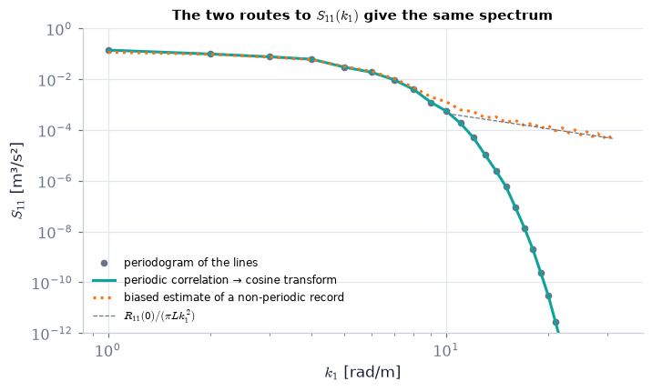

```python
line = u3[0, 0, :]                                            # u along one x-line of the field: what a towed probe would record
t_line = np.arange(line.size)*dx3/10.0                        # the probe moves at U0 = 10 m/s: sample times [s]
x_line, u_line = TS.taylor_frozen(t_line, line, 10.0)         # step 1: time → distance, x = U0 t
u_all = u3.reshape(-1, n3)                                    # every x-line of the field (to average the estimate)
rows3 = u_all[::7] - u_all[::7].mean(axis=1, keepdims=True)   # every 7th line, each with its own mean removed
# step 2: the PERIODIC (circular) correlation of each line, then the average over lines. Wiener–Khinchin (C03):
# the inverse FFT of |FFT|² is the correlation of a periodic record, exactly — no zero padding, because the field IS periodic
R_circ = np.mean([np.fft.ifft(np.abs(np.fft.fft(row))**2).real/n3 for row in rows3], axis=0)   # R_11(r_1) for r_1 = 0 … L
r_circ = np.arange(n3)*dx3                                    # separations over the whole period 0 … L [m]
k1 = np.arange(1, n3//2)*2*np.pi/L3                           # wavenumbers resolved by the box [rad/m]
S_corr = np.array([np.sum(R_circ*np.cos(k_*r_circ))*dx3/(2*np.pi) for k_ in k1])   # step 3: Eq. (12.45) as a sum over one period (exact for a periodic function)
S_per = np.mean([TS.periodogram(row, dx3)[1] for row in rows3], axis=0)   # the direct route: averaged periodograms
k_per = TS.periodogram(rows3[0], dx3)[0]                      # their wavenumbers
R_bias = np.mean([TS.autocorrelation(row, dx3, max_lag=n3//2, unbiased=False)[1] for row in rows3], axis=0)   # what a NON-periodic record would give: sums of n − m products divided by n
r_bias = np.arange(R_bias.size)*dx3                           # its separations 0 … L/2 [m]
S_bias = np.abs(TS.spectrum_from_correlation(r_bias, R_bias, k1))        # the cosine transform of that "biased" estimate
tail = R_circ[0]/(np.pi*L3*k1**2)                             # the tail the kink predicts: R(0)/(π L k²) (see the reading notes)
fig, ax = plt.subplots(figsize=(6.4, 3.8))   # a new figure and its panel(s); figsize in inches
ax.loglog(k_per[1:], S_per[1:], "o", ms=4, color=C_REF, label="periodogram of the lines")
ax.loglog(k1, np.abs(S_corr), color=C_FLUC, lw=2, label="periodic correlation → cosine transform")
ax.loglog(k1, S_bias, ":", color=C_RS, label="biased estimate of a non-periodic record")
ax.loglog(k1[k1 > 9], tail[k1 > 9], "--", color=C_REF, lw=0.8, label="$R_{11}(0)/(\\pi Lk_1^2)$")
ax.set(xlabel="$k_1$ [rad/m]", ylabel="$S_{11}$ [m³/s²]", ylim=(1e-12, 1), title="The two routes to $S_{11}(k_1)$ give the same spectrum")   # axis labels (with units), title and fixed ranges of this panel
shown = np.interp(k1, k_per, S_per) > 1e-12                   # the plotted range (above the bottom of the axis)
ratio = np.abs(S_corr[shown])/np.interp(k1[shown], k_per, S_per)
print(f"periodic correlation route / periodogram over the plotted range: between {ratio.min():.4f} and {ratio.max():.4f}")
print(f"biased estimate at k1 = 10 and 30 rad/m: {np.interp(10.0, k1, S_bias):.1e}, {np.interp(30.0, k1, S_bias):.1e};  R(0)/(π L k²) there: {np.interp(10.0, k1, tail):.1e}, {np.interp(30.0, k1, tail):.1e} m³/s²")
far = k1 >= 14.0                                              # the range where only the tail is left
print(f"biased estimate / guide for k1 ≥ 14 rad/m: between {(S_bias[far]/tail[far]).min():.2f} and {(S_bias[far]/tail[far]).max():.2f}")
ax.legend(fontsize=8)   # the legend names every curve
plt.show()   # display the figure
```

**What does the code above do?**

1. `u_all` holds every $x$-line of the field; `rows3` is every seventh line with its mean removed.
2. `R_circ` is the correlation route: FFT each line, take $\lvert\cdot\rvert^2$, transform back, divide by the number of points. This is the FFT correlation of primer P289 **without** zero padding — right here because the field is periodic, so a shift that wraps round the box is a genuine shift.
3. `S_corr` is the cosine sum of that correlation over one period — the discrete form of $S_{11}(k_1)=\frac1{2\pi}\int R_{11}(r_1)e^{-ik_1r_1}dr_1$; `S_per` is the direct route, `TS.periodogram` averaged over the lines.
4. `R_bias`, `S_bias` repeat the recipe with the estimator a non-periodic record needs (`TS.autocorrelation(..., unbiased=False)`: the sum of the $n-m$ available products divided by $n$); `tail` is the guide line $R_{11}(0)/(\pi Lk_1^2)$.
5. The three printed lines: the ratio of the two routes over the plotted range; the biased estimate and the guide at two wavenumbers; and their ratio over the tail.

**What you see.** Grey circles (periodogram) with a bold teal line (periodic correlation, then cosine transform) through them over the whole range: a plateau at small $k_1$, then a fall of ten decades beyond $k_1\approx6$ rad/m, where our prescribed spectrum ends. An orange dotted curve — the same recipe with the estimator one would use for a non-periodic record — follows them down to about $10^{-3}$ and then bends onto a line of slope −2, close to the thin dashed guide $R_{11}(0)/(\pi Lk_1^2)$ (the cell prints how close for $k_1\ge14$ rad/m).

**How to read it.** A one-dimensional spectrum is flat at small $k_1$ even though the three-dimensional spectrum $E(K)$ vanishes there: a straight cut through a field of eddies sees large-$K$ eddies obliquely, as long waves (aliasing by geometry). This is why measured $S_{11}$ never shows the energy-containing peak sharply. The two routes are the same information (the Wiener–Khinchin theorem of C03): our field is periodic, so its circular correlation is exact and the two spectra agree to round-off (the cell prints the ratio). **A measured time series is not periodic.** Its usual 'biased' correlation estimate divides the sum of the $n-m$ available products by $n$, which multiplies the true correlation by the triangle $1-r/L$. A triangle has a kink at $r=0$, and a kink transforms into a tail $R_{11}(0)/(\pi Lk_1^2)$ that falls only like $k_1^{-2}$ — the orange dotted curve. At $k_1=30$ rad/m it is still about $6\times10^{-5}$ m³/s² (the guide gives $5\times10^{-5}$; the cell prints both), where the true spectrum has fallen below $10^{-12}$. So a spectrum from a measured correlation cannot be trusted below that floor; a longer record ($L$ larger) lowers it.

**What would change if…** …the probe speed were comparable with the fluctuations: step 1 (Taylor's hypothesis) would fail and the spectrum would be smeared along $k_1$ (C03, N40).

**What would change if…** …there *is* a mean shear? Then the cloud of C04 tilts, the turbulence can take energy from the mean flow — and we need a budget for that energy (C06).

## 12.7 Turbulent Energy Cascade and Spectrum

**What is this section about?** Energy. The mean flow loses it to the large eddies, they hand it to smaller ones, and the smallest turn it into heat. We write the two budgets, find the size of the smallest eddies, and derive the most famous formula of the subject, the −5/3 spectrum.

### 🧩 The turbulent kinetic-energy budget $\frac{\partial\bar e}{\partial t}+U_j\frac{\partial\bar e}{\partial x_j}=\frac{\partial}{\partial x_j}\big(-\frac1{\rho_0}\overline{pu_j}+2\nu\overline{u_iS'_{ij}}-\frac12\overline{u_i^2u_j}\big)-2\nu\overline{S'_{ij}S'_{ij}}-\overline{u_iu_j}\frac{\partial U_i}{\partial x_j}+g\alpha\overline{u_3T'}$ (12.47) `C06`

*The question:* Where does the energy of the turbulence come from, and where does it go?

#### The problem in plain words

Switch off the fan and the turbulence in a room dies within seconds: it needs feeding. In a river the feed is the mean current rubbing against the bed; over a hot road it is buoyancy. An ocean-mixing or boundary-layer scheme in a climate model is, at heart, a bookkeeping of this energy.

#### The idea

```
mean flow  Ē = ½U_i²   ──[ shear production  −mean(u_i u_j) ∂U_i/∂x_j ]──►  turbulence  ē = ½ mean(u_i²)  ──[ ε̄ ]──► heat
     │  (tiny direct viscous loss 2ν S̄S̄ ~ 1/Re of production)                 ▲  buoyancy gα·mean(wT′): + heated below, − stable
the SAME term appears in both budgets with OPPOSITE signs
```

Symbols: $\bar E=\tfrac12U_i^2$ is the kinetic energy of the mean flow and $\bar e=\tfrac12\overline{u_i^2}$ that of the turbulence, both per unit mass [m²/s²]; $\bar\varepsilon$ is the dissipation rate [m²/s³ = W/kg]. Colours: shear production orange, dissipation rose, buoyancy blue, mean purple.

#### 🧮 Derivation — The kinetic-energy budget of the mean flow `D09` ★★ (Eq. 12.46: $\frac{\partial\bar E}{\partial t}+U_j\frac{\partial\bar E}{\partial x_j}=\frac{\partial}{\partial x_j}\big(-\frac{U_jP}{\rho_0}+2\nu U_i\bar S_{ij}-\overline{u_iu_j}U_i\big)-2\nu\bar S_{ij}\bar S_{ij}+\overline{u_iu_j}\frac{\partial U_i}{\partial x_j}-\frac g{\rho_0}\bar\rho U_3,\ \dots$)

**What we want to show.** Find where the mean flow's kinetic energy $\bar E=\tfrac12U_i^2$ goes — in particular, the term that hands energy to the turbulence.

**Assumptions.** Boussinesq; constant ν.

**The plan.**

1. Multiply by $U_i$.
2. Turn each product into a derivative of $\bar E$ or a divergence.
3. What cannot be made a divergence is a source or sink.

**Tools we use** (each explained before this point): product rule (P38) · mean continuity $\partial U_i/\partial x_i=0$ (12.27) · contraction of a symmetric tensor with a velocity gradient (ch02 §2.10)

**We start from**

$$ \begin{array}{l}\dfrac{\partial U_i}{\partial t}+U_j\dfrac{\partial U_i}{\partial x_j}=-g\big[1-\alpha(\bar T-T_0)\big]\delta_{i3}+\dfrac1{\rho_0}\dfrac{\partial\bar\tau_{ij}}{\partial x_j}\ \text{,} \\ \bar\tau_{ij}=-P\delta_{ij}+2\mu\bar S_{ij}-\rho_0\overline{u_iu_j}\ \text{(12.30).}\end{array} $$

**Step 1 of 9 — Multiply the mean momentum equation by $U_i$ (sum over i).**

$$ U_i\dfrac{\partial U_i}{\partial t}+U_iU_j\dfrac{\partial U_i}{\partial x_j}=-gU_3\big[1-\alpha(\bar T-T_0)\big]+\dfrac{U_i}{\rho_0}\dfrac{\partial\bar\tau_{ij}}{\partial x_j} $$

- *Why we can do this:* Force × velocity = power: multiplying a momentum equation by the velocity gives an energy equation (the move of Ch. 4's mechanical-energy equation).
- *In words:* The rate of working of each force on the mean flow.

**Step 2 of 9 — Recognise the time derivative.**

$$ U_i\dfrac{\partial U_i}{\partial t}=\dfrac{\partial}{\partial t}\Big(\tfrac12U_i^2\Big)=\dfrac{\partial\bar E}{\partial t} $$

- *Why we can do this:* Chain rule backwards: $\partial(U_i^2)/\partial t=2U_i\,\partial U_i/\partial t$.
- *In words:* The first term is the rate of change of mean kinetic energy.

**Step 3 of 9 — Do the same for advection.**

$$ U_iU_j\dfrac{\partial U_i}{\partial x_j}=U_j\dfrac{\partial\bar E}{\partial x_j} $$

- *Why we can do this:* Same chain rule with $x_j$ for t.
- *In words:* Mean energy carried along by the mean flow.

**Step 4 of 9 — Rewrite the gravity term with the mean density.**

$$ -gU_3\big[1-\alpha(\bar T-T_0)\big]=-\dfrac{g}{\rho_0}\,\bar\rho\,U_3 $$

- *Why we can do this:* Boussinesq equation of state, $\bar\rho=\rho_0[1-\alpha(\bar T-T_0)]$.
- *In words:* Rising mean motion loses kinetic energy to potential energy.

**Step 5 of 9 — Split the stress term with the product rule.**

$$ \dfrac{U_i}{\rho_0}\dfrac{\partial\bar\tau_{ij}}{\partial x_j}=\dfrac1{\rho_0}\dfrac{\partial}{\partial x_j}\big(U_i\bar\tau_{ij}\big)-\dfrac{\bar\tau_{ij}}{\rho_0}\dfrac{\partial U_i}{\partial x_j} $$

- *Why we can do this:* $\partial(U_i\bar\tau_{ij})/\partial x_j=U_i\,\partial\bar\tau_{ij}/\partial x_j+\bar\tau_{ij}\,\partial U_i/\partial x_j$. A divergence only moves energy; the remainder creates or destroys it.
- *In words:* Stress work = transport of energy − deformation work.

**Step 6 of 9 — Write out the transport part.**

$$ \dfrac{U_i\bar\tau_{ij}}{\rho_0}=-\dfrac{U_jP}{\rho_0}+2\nu U_i\bar S_{ij}-\overline{u_iu_j}\,U_i $$

- *Why we can do this:* Substitute $\bar\tau_{ij}$; $U_i\delta_{ij}=U_j$; μ/ρ₀ = ν.
- *In words:* Energy is carried by pressure, by viscous stress and by Reynolds stress.

**Step 7 of 9 — Contract the pressure and viscous parts with the gradient.**

$$ \dfrac{-P\delta_{ij}+2\mu\bar S_{ij}}{\rho_0}\dfrac{\partial U_i}{\partial x_j}=-\dfrac{P}{\rho_0}\dfrac{\partial U_i}{\partial x_i}+2\nu\bar S_{ij}\dfrac{\partial U_i}{\partial x_j}=2\nu\bar S_{ij}\bar S_{ij} $$

- *Why we can do this:* $\partial U_i/\partial x_i=0$ (12.27); a symmetric tensor contracted with a gradient sees only its symmetric part (ch02 §2.10).
- *In words:* Pressure does no deformation work in an incompressible flow; viscosity always dissipates.

**Step 8 of 9 — Contract the Reynolds part.**

$$ -\dfrac{(-\rho_0\overline{u_iu_j})}{\rho_0}\dfrac{\partial U_i}{\partial x_j}=+\overline{u_iu_j}\dfrac{\partial U_i}{\partial x_j} $$

- *Why we can do this:* The minus of step 5 meets the minus in $\bar\tau_{ij}$. For U(y): $\overline{uv}\,dU/dy$, negative when $dU/dy>0$ (C04).
- *In words:* The work of the mean flow against the Reynolds stress — a loss.

**Step 9 of 9 — Assemble.**

$$ \begin{aligned}\dfrac{\partial\bar E}{\partial t}+U_j\dfrac{\partial\bar E}{\partial x_j}=&\ \dfrac{\partial}{\partial x_j}\Big(-\dfrac{U_jP}{\rho_0}+2\nu U_i\bar S_{ij}-\overline{u_iu_j}U_i\Big)\\&-2\nu\bar S_{ij}\bar S_{ij}+\overline{u_iu_j}\dfrac{\partial U_i}{\partial x_j}-\dfrac{g}{\rho_0}\bar\rho U_3\end{aligned} $$

- *Why we can do this:* Steps 2–8 in step 1. This is (12.46), $\frac{\partial\bar E}{\partial t}+U_j\frac{\partial\bar E}{\partial x_j}=\frac{\partial}{\partial x_j}\big(-\frac{U_jP}{\rho_0}+2\nu U_i\bar S_{ij}-\overline{u_iu_j}U_i\big)-2\nu\bar S_{ij}\bar S_{ij}+\overline{u_iu_j}\frac{\partial U_i}{\partial x_j}-\frac g{\rho_0}\bar\rho U_3$.
- *In words:* Mean energy changes by transport, direct viscous loss, loss to turbulence and loss to potential energy.

**Result**

$$ \begin{array}{l}\frac{\partial\bar E}{\partial t}+U_j\frac{\partial\bar E}{\partial x_j}=\frac{\partial}{\partial x_j}\big(-\frac{U_jP}{\rho_0}+2\nu U_i\bar S_{ij}-\overline{u_iu_j}U_i\big)-2\nu\bar S_{ij}\bar S_{ij}+\overline{u_iu_j}\frac{\partial U_i}{\partial x_j}-\frac g{\rho_0}\bar\rho U_3 \\ \text{(12.46), as in step 9}\end{array} $$

*In words:* The mean flow loses energy to the turbulence at the rate $-\overline{u_iu_j}\,\partial U_i/\partial x_j$

**What it means.** At high Reynolds number the mean flow, away from walls, hardly feels viscosity directly; it is drained by the Reynolds stress, and D10 shows the same term arriving in the turbulence. **Fails when:** density varies beyond Boussinesq.

**Check it.** Units — every term m²/s³. No fluctuations ⇒ Ch. 4's mechanical-energy equation ✓. Size: direct dissipation / production ~ ν/(UL) = 1/Re where the mean gradient is ~ ΔU/L (free shear flows, the outer part of a wall flow) — not in the viscous wall layer, where the gradient is $u_*^2/\nu$ (N80). Code: `ch12.mean_energy_budget_sympy()` residual 0; integral identity in a channel: pressure work = direct dissipation + production (`channel_energy_budget`).

📝 **Notes taught inside `D09`:** **N78 [B]** the kinetic-energy budget of the mean flow, the Result of this derivation (steps 1–9).

> ⚠️ **Common confusion (traps in `D09`):** Calling $+\overline{u_iu_j}\,\partial U_i/\partial x_j$ a gain because of its plus sign (it is negative); forgetting the divergence terms vanish only when integrated over a closed or homogeneous region.

📝 **Note.** **N79 [B]** **Reading the mean-flow budget.** Divergence terms only move energy from place to place (Gauss's theorem, Ch. 2: their volume integral is a surface flux). The exchange term sees only the symmetric part of the mean gradient, $\overline{u_iu_j}\,\partial U_i/\partial x_j=\overline{u_iu_j}\bar S_{ij}$ (a symmetric tensor contracted with an antisymmetric one gives zero, Ch. 2). For a shear flow $U(y)$ it is $\overline{uv}\,dU/dy$ — negative, a **loss** for the mean flow, because $\overline{uv}<0$ when $dU/dy>0$ (C04).

📝 **Note.** **N80 [B]** **The mean flow's direct viscous loss is negligible** next to its loss to turbulence: $\frac{2\nu\bar S_{ij}\bar S_{ij}}{\overline{u_iu_j}(\partial U_i/\partial x_j)}\sim\frac{\nu(U/L)^2}{u_{rms}^2(U/L)}\sim\frac\nu{UL}=\frac1{\mathrm{Re}}\ll1$ (with $u_{rms}\sim U$). At $\mathrm{Re}=10^6$ the ratio is $10^{-6}$ (`ch12.mean_to_turbulent_dissipation_ratio(1e6)`).